# Primary Analysis

Jonathan Hwang

2026-09-04

# Summary

This notebook cleans the mortality data from the 1630-1631 Venetian Plague, calculates the Shannon entropy and negentropy of the quantile function and the PDF, and uses bootstrapping to find 95% confidence intervals.

# Initialization

Load packages.

```r
#renv::init()

library(tidyverse)
library(rootSolve)
library(data.table)
library(msos)
library(entropy)
library(simboot)
library(MCPAN)
library(boot)
library(gridExtra)
library(cowplot)
library(ggpubr)
library(progress)
library(renv)
library(gridExtra)
library(Hmisc)
library(lubridate)
library(tmap)
library(ggplotify)
library(sf)
library(stringi)
library(openxlsx)
library(av)

sf_use_s2(FALSE)

# Clear environment
rm(list = ls())

knitr::opts_chunk$set(echo = TRUE)
```

Import all of the [csv files](https://github.com/ggrrll/Venice-plague-epidemic-paper) containing mortality data sourced from *Lazzari, G., Colavizza, G., Bortoluzzi, F., Drago, D., Erboso, A., Zugno, F., … & Salathé, M. (2020). A digital reconstruction of the 1630–1631 large plague outbreak in Venice. Scientific reports, 10(1), 1-7*.

```r
# Mortality data for all parishes from January 1, 1629 to December 31, 1631.
all <- read.csv("ALL_utf.csv")
city_peaks <- read.csv("city_cases_baseline_removed.csv")
filled <- read.csv("filledna_full_ts.csv")

# Geographical data for locations of Venetian parishes.
# Note that geo_df doesn't have S.Giacomo.dell'Orio and Angelo.Rafael is blank.
geo_df <- read.csv("geo_df.csv")

# Venetian census data from 1696 containing parish populations
population <- read.csv("ParishPopulations.csv")

# 1586 census data containing which parishes belong to which sestieri
sestiere_pre <- read.csv("sestiereDataPre.csv")

# 1696 census data containing which parishes belong to which sestieri
sestiere_post <- read.csv("SestiereDataPost.csv")
```

Import csv files containing population data from Venetian censuses in 1509, 1551, 1581, 1586, and 1696 for each parish.

```r
population_pre <- read.csv("ParishPopulationsPre.csv")
population_post <- read.csv("ParishPopulationsPost.csv")
```

Initialize the plot theme, the color palette, and the workbook for the source data.

```r
Okabe_Ito_palette <- c("#E69F00", "#56B4E9", "#009E73", "#F0E442", "#0072B2", "#CC79A7")

plot_theme <- function(base_family = "Helvetica", base_size = 7) {
  theme_classic(
    base_family = base_family,
    base_size = base_size
  ) +
    theme(
      # Text
      text = element_text(
        family = base_family,
        color = "black"
      ),
      axis.title = element_text(
        family = base_family,
        size = 7,
        color = "black"
      ),
      axis.text = element_text(
        family = base_family,
        size = 6,
        color = "black"
      ),
      legend.title = element_text(
        family = base_family,
        size = 7
      ),
      legend.text = element_text(
        family = base_family,
        size = 6
      ),

      # Whole-figure titles should be in the manuscript legend
      plot.title = element_blank(),

      # Lines and ticks
      axis.line = element_line(
        color = "black",
        linewidth = 0.3
      ),
      axis.ticks = element_line(
        color = "black",
        linewidth = 0.3
      ),
      axis.ticks.length = grid::unit(1.5, "mm"),

      # Panels
      panel.grid = element_blank(),
      panel.border = element_blank(),
      strip.background = element_blank(),
      strip.text = element_text(
        family = base_family,
        size = 7,
        face = "bold"
      ),

      # Layout
      legend.key = element_blank(),
      legend.position = "right",
      plot.background = element_rect(
        fill = "white",
        color = NA
      ),
      plot.margin = margin(3, 3, 3, 3, unit = "mm")
    )
}

# Initialize the workbook that will contain the source data for the figures

wb <- createWorkbook()
```

# Data Cleaning

Now, we perform preliminary cleaning.

```r
# Fix the Dates on all
all$Date <- sub("2029", "1629", all$Date)
all$Date <- sub("2030", "1630", all$Date)
all$Date <- sub("2031", "1631", all$Date)
all$Date <- as.Date(all$Date, format = "%m/%d/%Y")

# Fix artifacts for column names
colnames(all) <- sub("^S\\.", "S", colnames(all))

# Remove diacritics
colnames(all) <- stri_trans_general(colnames(all), id = "Latin-ASCII")

# Convert mortality data in all into integer types
for(column in 1:ncol(all)){
  if(column == 1){
    next
  }
  if(!(is.integer(all[,column]))){
    all[,column] = as.integer(all[,column])
  }
}

# Fix the Dates on filled
colnames(filled)[1] <- "Date"
filled$Date <- as.Date(filled$Date, format = "%Y-%m-%d")

# Fix the parish name artifacts in filled (import_csv replaces spaces with periods)
colnames(filled) <- sub("^S\\.", "S", colnames(filled))

# Remove diacritics
colnames(filled) <- stri_trans_general(colnames(filled), id = "Latin-ASCII")

# Convert mortality data in filled into integer types
for(column in 1:ncol(filled)){
  if(column == 1){
    next
  }
  if(!(is.integer(filled[, column]))){
    filled[, column] = as.integer(filled[,column])
  }
}

# Fix the Dates on city_peaks
colnames(city_peaks)[1] <- "Date"
city_peaks$Date <- sub(" 00:00:00", "", city_peaks$Date)
city_peaks$Date <- as.Date(city_peaks$Date, format = "%Y-%m-%d")

# Fix geo_df
colnames(geo_df)[1] <- "Parish"
geo_df$Parish <- gsub("[[:space:]]", ".", geo_df$Parish)
geo_df$Parish <- sub("^S\\.", "S", geo_df$Parish)

# Remove diacritics
geo_df$Parish <- stri_trans_general(geo_df$Parish, id = "Latin-ASCII")

# Get rid of Angelo.Rafael because it has no lat/long data
# geo_df <- geo_df[!grepl("Angelo.Rafael",geo_df$Parish),]

# Fix population
population$Parish <- gsub("[[:space:]]", ".", population$Parish)
population$Parish <- sub("^S\\.", "S", population$Parish)

# Remove diacritics
population$Parish <- stri_trans_general(population$Parish, id = "Latin-ASCII")

# What are the missing cities in geo_df?
setdiff(geo_df$Parish, colnames(filled))
```

```
## [1] "S.Giacomo.dell'Orio"
```

```r
# What are the missing cities in population?
filled <- filled[, -match(c("S.Marcilian"), colnames(filled))] # Marcilian only exists in the population_pre dataset.

# Remove columns (parishes) in filled that exclusively contain NAs
all_nas <- c()
for(col in 1:ncol(filled)){
  if(sum(is.na(filled[,col])) == length(filled[,col])){
    all_nas <- c(all_nas, col)
  }
}
if(length(all_nas) > 0){
  filled <- filled[, -all_nas]
}

# Remove parishes in filled that aren't in the population dataset
missing_parishes <- c()
for(p in 1:length(colnames(filled))){
  if(!(colnames(filled)[p] %in% population$Parish) & colnames(filled)[p] != "Date"){
    missing_parishes <- c(missing_parishes, p)
  }
}
if(length(missing_parishes) > 0){
  filled <- filled[,-missing_parishes]
}
```

Clean the population datasets.

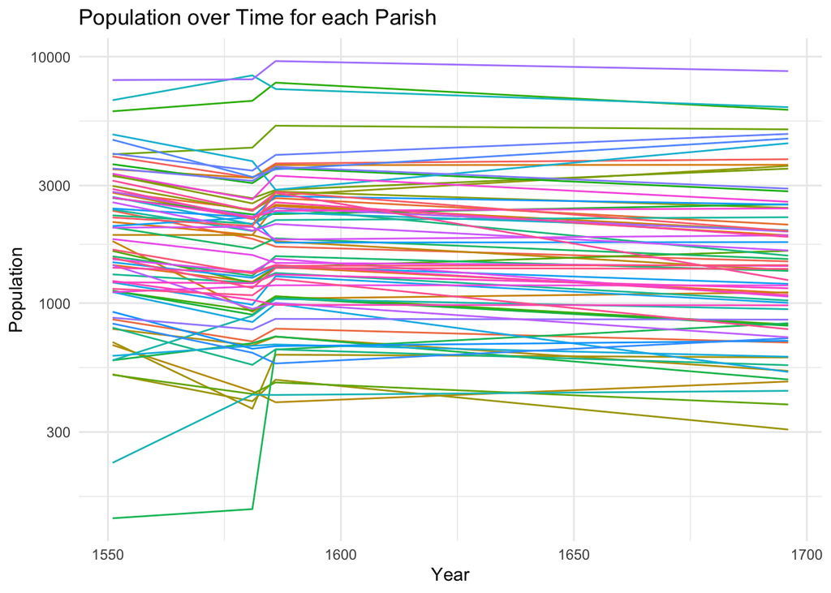

```r
colnames(population_pre) <- c("Parish", "Population_1509", "Population_1551",
                              "Population_1581", "Population_1586")

# Remove space artifacts
population_pre$Parish <- gsub("[[:space:]]", ".", population_pre$Parish)
population_pre$Parish <- sub("^S\\.", "S", population_pre$Parish)

# Remove diacritics
population_pre$Parish <- stri_trans_general(population_pre$Parish, id = "Latin-ASCII")

# Remove space artifacts
population_post$Parish <- gsub("[[:space:]]", ".", population_post$Parish)
population_post$Parish <- sub("^S\\.", "S", population_post$Parish)

# Remove diacritics
population_post$Parish <- stri_trans_general(population_post$Parish, id = "Latin-ASCII")

# Identify and remove the parishes that are not contained in both the
# 1586 census and the 1696 census
remove_vec <- c()
for(i in 1:length(population_pre$Parish)){
  if(!(population_pre$Parish[i] %in% population_post$Parish)){
    remove_vec <- c(remove_vec,i)
  }
}

if(length(remove_vec) > 0){
  population_pre <- population_pre[-remove_vec,]
}

remove_vec <- c()
for(i in 1:length(population_post$Parish)){
  if(!(population_post$Parish[i] %in% population_pre$Parish)){
    remove_vec <- c(remove_vec, i)
  }
}

if(length(remove_vec) > 0){
  population_post <- population_post[-remove_vec,]
}

# Establish a consistent ordering of the parishes (alphabetical)
population_post <- population_post %>% arrange(Parish)
population_pre <- population_pre %>% arrange(Parish)

# Remove the 1509 census data because the vast majority of values are NAs
population_pre <- population_pre[,-2]

# In the population_pre dataset, the thousands place is marked by a period.
# Unfortunately, R interprets these as decimal points. Because parishes with
# populations smaller than 1000 are unaffected by this, we use the format
# function with 3 decimal places to exclude parishes with populations smaller than 1000.
# Specifically, these parishes all have populations with 3 digits, so adding
# the decimal point and three zeroes will result in their population numbers
# having 7 characters.
# All of the population numbers greater than 1000 are also less than 100,000,
# so the 7 character rule never accidentally excludes the wrong parishes.
# Additionally, using the format function with three decimal places ensures that
# trailing zeroes are accounted for.
# Thus, we only scale the numbers that have less than 7 characters.

for(j in 1:ncol(population_pre)){
  if(j == 1){
    next
  }
  for(i in 1:nrow(population_pre)){
    population_pre[i,j] <- format(as.numeric(population_pre[i,j]), nsmall = 3)

    if(nchar(population_pre[i,j]) < 7){
      population_pre[i,j] <- as.numeric(population_pre[i,j]) * 1000
    } else {
      population_pre[i,j] <- as.numeric(population_pre[i,j])
    }
  }
  population_pre[,j] <- as.numeric(population_pre[,j])
}
population_post$Population <- as.numeric(population_post$Population) * 1000

# Merge population_pre and population_post into one dataframe, population_df
population_df <- as.data.frame(cbind(population_pre, population_post[,-1]))
colnames(population_df) <- c("Parish", "Population_1551", "Population_1581",
                             "Population_1586", "Population_1696")

# Plot the population data over time
year_vec <- c(c(1551, 1581, 1586, 1696))

t_pop_df <- transpose(population_df)
rownames(t_pop_df) <- colnames(population_df)
t_pop_df <- t_pop_df[-1,]
colnames(t_pop_df) <- population_df$Parish
t_pop_df <- cbind(year_vec, t_pop_df)
t_pop_df_plot <- t_pop_df %>%
  gather(key = "Parish_var", value = "value", -year_vec)
t_pop_df_plot$value <- as.numeric(t_pop_df_plot$value)

t_pop_df_plot %>%
  ggplot(aes(x = year_vec, y = value))+
  geom_line(aes(color = Parish_var), show.legend = FALSE, linewidth = 0.5)+
  labs(x = "Year", y = "Population",
       title = "Population over Time for each Parish")+
  scale_y_log10()+
  theme_minimal()
```

Plot the 1696 population data vs. the 1586 population data.

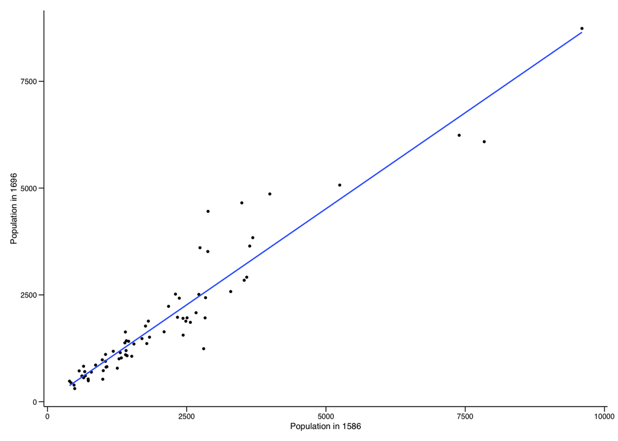

```r
population_df %>%
  ggplot(aes(x = Population_1586, y = Population_1696))+
  geom_point(size = 0.5)+
  geom_smooth(method = lm, se = FALSE, linewidth = 0.5)+
  theme_bw(base_family = "Helvetica", base_size = 7)+
  labs(x = "Population in 1586", y = "Population in 1696", title = "Population in 1696 vs. Population in 1586") +
  plot_theme()
```

```r
# Save as Supplementary Figure 6
ggsave(
  filename = file.path(
    "Figures_Final_v2",
    "SuppFig6.pdf"
  ),
  width = 180,
  height = 108,
  units = "mm",
  bg = "white"
)
ggsave(
  filename = file.path(
    "Figures_Final_v2",
    "SuppFig6.png"
  ),
  width = 1920,
  height = 1080,
  units = "px",
  dpi = 300,
  bg = "white"
)
```

Run a linear regression on the Venetian census data from 1696 vs. 1586 to determine the validity of using linear interpolation to estimate 1629 parish populations.

```r
cor(population_df$Population_1586, population_df$Population_1696) #0.95
```

```
## [1] 0.9524433
```

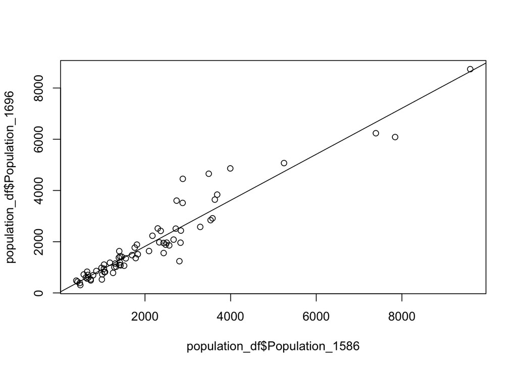

```r
plot(x = population_df$Population_1586, y = population_df$Population_1696)

abline(mod <- lm(population_df$Population_1696 ~ population_df$Population_1586))
```

```r
# y = 1696, x = 1586 (closest census date) so slope < 1 means that
# population decreased over time

intercept <- as.numeric(coef(mod)[1])
slope <- as.numeric(coef(mod)[2]) #slope, close to 1 so we feel comfortable interpolating
```

Due to the high $r$ value (0.95) and the slope being close to 1, we feel comfortable linearly interpolating between the 1696 and 1586 population data to estimate each parish’s population on January 1, 1629.

```r
# Per-parish interpolation
interpolated_1629 <- as.numeric(population_df$Population_1586) + (43 / 110) * (population_df$Population_1696 - population_df$Population_1586)

# Population-wide interpolation using linear regression results
# 1629 - 1586 = 43, 1696 - 1586 = 110, so to interpolate we multiply by 43/110
#interpolated_1629 <- (intercept - (1-slope) * population_pre$Population_1586) * 43/110 + population_pre$Population_1586
```

Create population_specified, a dataframe containing only the populations of the parishes of interest.

```r
population <- data.frame(population_post$Parish, interpolated_1629 / 1000)
colnames(population) <- c("Parish","Population")
population_specified <- population[population$Parish %in% colnames(filled[,-1]),]
population_specified <- population_specified[match(colnames(filled[,-1]), population_specified$Parish),]
```

Now, we combine sestiere_pre and sestiere_post, the two dataframes that list the parishes within each sestiere (a sestiere is a larger geographical area that contains multiple parishes).

```r
# Fix the parish names on sestiere_pre

# Remove space artifacts
sestiere_pre$Parish <- gsub("[[:space:]]", ".", sestiere_pre$Parish)
sestiere_pre$Parish <- sub("^S\\.", "S", sestiere_pre$Parish)

# Remove diacritics
sestiere_pre$Parish <- stri_trans_general(sestiere_pre$Parish, id = "Latin-ASCII")

# Fix the parish names on sestiere_post
sestiere_post$Parish <- gsub("[[:space:]]", ".", sestiere_post$Parish)
sestiere_post$Parish <- sub("^S\\.", "S", sestiere_post$Parish)

# Remove diacritics
sestiere_post$Parish <- stri_trans_general(sestiere_post$Parish, id = "Latin-ASCII")

# Arrange both sestiere dataframes by sestiere
sestiere_pre <- sestiere_pre %>% arrange(Sestiere, Parish)
sestiere_post <- sestiere_post %>% arrange(Sestiere, Parish)

# S. Marcilian and S.Simone.Piccolo is spelled S.Simeone.Piccolo in population_df, but Simeone Piccolo is not in filled because there was no data
#setdiff(sestiere_pre$Parish, population_df$Parish)

# Since we chose to interpolate using population_1586, we use sestiere_pre,
# which is taken from the same 1586 census, to ensure that the parish names match
sestiere_df <- sestiere_pre

# Match parishes in sestiere_df with those in filled
remove_vec <- c()
for(i in 1:length(sestiere_df$Parish)){
  if(!(sestiere_df$Parish[i] %in% colnames(filled[,-1]))){
    remove_vec <- c(remove_vec,i)
  }
}

if(length(remove_vec) > 0){
  sestiere_df <- sestiere_df[-remove_vec,]
}

# Define dataframes for each individual year
filled_1629 <- filled[year(filled$Date) == 1629,]
filled_1630 <- filled[year(filled$Date) == 1630,]
filled_1631 <- filled[year(filled$Date) == 1631,]
```

Finally, we figure out which parishes we will keep. The code below removes San Marco from our analysis because it served as a placeholder for deaths from drowning and those in prison, which resulted in an early spike in cases not representative of parish transmission. In our main analysis, we exclude it, but in the supplementary information, we include San Marco as a form of sensitivity analysis. The other two parishes we exclude are those which had no data during the primary outbreak window (9/1/30-12/31/30).

```r
outliers <- c("S.Polo", "S.Stae", "S.Marco") #No cases between 9/1/30 and 12/31/30, outbreak time
filled_modified <- filled[, !(colnames(filled) %in% outliers)]
sestiere_df_modified <- sestiere_df[!(sestiere_df$Parish %in% outliers),]
population_specified_modified <- population_specified[!(population_specified$Parish %in% outliers),]
```

# Define Statistic-Calculating Functions

In this section, we define the functions that calculate the statistics of interest (entropy and KL divergence of the quantile function and PDF).

## Define PDF Approximation Function

For our histogram approximation of the PDF, we use Sturges’s Rule to choose $K$, the number of bins, for $N$ observations ($K = \log_2(N)+1$).

```r
#Define a function that provides a histogram approximation of a PDF with K bins. Here, we use Sturges's Rule for K.
PDF_approx <- function(x, K = ceiling(log2(length(x))) + 1) {
  p <- table(cut(x, breaks = K)) / length(x)
  return(p)
}
```

## Define Kullback-Leibler Divergence

To calculate Kullback-Leibler divergence between two discrete probability distributions P(x) and Q(x), we use the definition $\sum_{x \in \mathcal{X}} P(x) \log \frac{P(x)}{Q(x)}$. While this formulation implies that KL divergence is undefined when $P(x) = Q(x) = 0$, we [consider the contribution of the KL divergence at that point to be zero](https://en.wikipedia.org/wiki/Kullback%E2%80%93Leibler_divergence#Definition).

To see how this function compares with other methods of calculating Kullback-Leibler Divergence, see this section.

```r
#Next, we define Kullback-Leibler divergence between two discrete probability distributions (x and y), formatted as vectors. We add a small value epsilon to avoid dividing by zero.
KL_new <- function(x, y, epsilon = 1e-05){
  distance = 0
  pq_ratio = 0
  if(length(x) != length(y)){
    print("not same length")
    return(NA)
  }
  for(i in 1:length(x)){
    if(is.nan(x[i]) | is.nan(y[i]) | x[i] == 0){
      next
    }
    if(y[i] == 0){
      pq_ratio = x[i] / epsilon
    } else {
      pq_ratio = x[i] / y[i]
    }
    distance = distance + x[i] * log(pq_ratio)
  }
  return(distance)
}
```

For a discrete probability distribution $P(x)$ taking values in the set $\mathcal{X}$, we define the Shannon entropy $H$ to be $H = -\sum_{x \in \mathcal{X}} P(x) \ln P(x)$. This definition is implemented directly in the main analysis function.

## Find the Entropy of the Gaussian Distribution with Identical Mean and Variance to the Data

```r
#----
#' Documentation: normal_approx
#' Usage: normal_approx(x, K)
#' @description: Takes in a vector of mortality at a given time point and generates a histogram approximation of a Gaussian distribution with identical mean and variance to the data using midpoint density estimation

#' Arguments/Options:
#' @param x: a vector containing the mortality rates of each parish at a specific point in time
#' @param K: the number of bins to use (DEFAULT: ceiling(log2(length(x))) + 1), Sturges' Rule)

#' @return: a vector of length K containing the densities in each bin of the normal distribution as described above
#----

normal_approx <- function (x, K = ceiling(log2(length(x))) + 1){
  bins <- seq(min(x), max(x), length.out = K + 1)
  bins2 <- rep(0, K)
  for(i in 1:K){
    bins2[i] <- (bins[i] + bins[i + 1]) / 2
  }
  y <- dnorm(bins2, mean = mean(x), sd = sd(x)) # Midpoint density estimation
  y <- y / sum(y)
  return(y)
}

#----
#' Documentation: calculate_normal_entropy
#' Usage: calculate_normal_entropy(death_data, population_data, cumulative)
#' @description: Takes in death and population data and outputs a vector containing the entropy of the histogram-approximated normal distribution (using Sturges' Rule) with the same mean and variance as the data on each day.

#' Arguments/Options:
#' @param death_data: a dataframe containing parishes as columns, days as rows, and death counts as entries. The first column is excluded (typically because it contains date data).
#' @param population_data:
#' @param cumulative: a boolean specifying whether all deaths up to each time point are included (TRUE) or if only the deaths on that day are included (FALSE). (DEFAULT: TRUE)

#' @return: a vector of length nrow(death_data) containing the entropy of the histrogram-approximated normal distribution with the same mean and variance as the data on each day in the epidemic.
#----

calculate_normal_entropy <- function(death_data, population_data, cumulative = TRUE){
  max_entropy_vec <- rep(NA_real_, nrow(death_data))
  for(i in 1:nrow(death_data)){
    if(cumulative){
      case_vector <- colSums(death_data[1:i,-1]) / (population_data$Population * 1000)
    } else {
      case_vector <- as.numeric(death_data[i, -1]) / (population_data$Population * 1000)
    }
    p <- normal_approx(case_vector)
    max_entropy <- -1 * sum(p * log(p))
    max_entropy_vec[i] <- max_entropy
  }
  return(max_entropy_vec)
}
```

## Define Main Analaysis Function

Now, we define our main analysis function which returns the total number of deaths, Shannon entropy of the PDF, Shannon Entropy of the quantile function, negentropy of the PDF (KL divergence with a Gaussian), KL divergence of the PDF from a uniform, and KL divergence of the quantile from a discrete uniform at a given timestep. Later, we will run this function on the 999 resampled datasets generated during the bootstrapping process.

```r
#----
#' Documentation: entropy_procedure
#' Usage: entropy_procedure(original_data, subset, indices, timestep, cumulative)
#' @description: Return a list containing the sum of all cases (sum),
#' Shannon entropy of the PDF (shannonPDF),
#' Shannon entropy of the quantile function (shannonQuantile),
#' KL divergence of the PDF from a Gaussian distribution (negentPDF),
#' KL divergence of the PDF from a uniform distribution (uniformKL_PDF),
#' and KL divergence of the quantile function from a uniform distribution (uniformKL_Quantile)
#' calculated on mortality data in a specified subset of parishes on or up to a particular day

#' Arguments/Options:
#' @param original_data: a dataframe containing one variable for every parish of interest. Note that original_data does NOT get modified by subset, so original_data must already be subsetted if one only wishes to include a smaller selection of parishes.
#' @param subset: a vector containing the indices of the parishes of interest in colnames(filled_modified).
#' @param indices: a vector containing the indices generated by sampling with replacement. To analyze the original data, set indices = 1:ncol(original_data).
#' @param timestep: an integer between 1 and nrow(filled_modified) corresponding to the day for which the aforementioned statistics should be calculated.
#' @param cumulative: a boolean specifying whether deaths occurring on days prior to timestep should be included. If cumulative is set to FALSE, only deaths on day "timestep" will be considered. If cumulative is set to TRUE, deaths up to and including day "timestep" will be added up (DEFAULT: TRUE)

#' @return: the list as described above
#----

entropy_procedure <- function(original_data,
           subset,
           indices,
           timestep,
           cumulative = TRUE) {
    boot_data <- original_data[, indices]
    # The proper index for pop_spec is subset - 1 because filled has a "Date"
    # column while population_specified_modified does not
    pop_spec <- population_specified_modified[subset - 1, ][indices, ]
    if (cumulative) {
      non_pop_corrected <- as.numeric(colSums(boot_data[1:timestep, ]))
    } else {
      non_pop_corrected <- as.numeric(boot_data[timestep, ])
    }

    # Case vector (cv): cases in each parish divided by parish population
    cv <- non_pop_corrected / (pop_spec$Population * 1000)
    cv <- sort(cv)

    # Normalized case vector (cv_norm): quantile function
    cv_norm <- cv / sum(cv)

    # Kernel (kern): histogram of mortality with # bins specified by Sturges's Rule
    kern <- as.numeric(PDF_approx(cv))

    kern <- kern / sum(kern)

    shannon_PDF <- -1 * sum(kern[kern != 0] * log(kern[kern != 0]))
    shannon_quantile <-
      -1 * sum(cv_norm[cv_norm != 0] * log(cv_norm[cv_norm != 0]))

    # Use the msos negent function to calculate the negentropy of the PDF
    negent_PDF <- negent(cv)

    uniform_KL_PDF <-
      as.numeric(KL_new(kern, rep(1 / length(kern), length(kern))))
    uniform_KL_quantile <-
      KL_new(cv_norm, rep(1 / length(cv_norm), length(cv_norm)))
    return(
      list(
        sum = sum(non_pop_corrected) / (sum(pop_spec$Population) * 1000),
        shannonPDF = shannon_PDF,
        shannonQuantile = shannon_quantile,
        negentPDF = negent_PDF,
        uniformKL_PDF = uniform_KL_PDF,
        uniformKL_Quantile = uniform_KL_quantile
      )
    )
  }
```

# Bootstrapping

In this section of code, we run bootstrapping (*n* = 999) to identify 95% confidence intervals for all of the statistics we calculate.

## Define Bootstrapping Functions

Now, we implement a generalized function to bootstrap over our entropy_procedure function. We will utilize this function in the subsequent functions bootstrapping over a particular dataset.

```r
#----
#' Documentation: manual_boot_modified
#' Usage: manual_boot_modified(data, subset, N, max_ts, cumulative)
#' @description: Returns a list containing six matrices formatted with dates as columns and resamples as rows. In order, the matrices contain:
#' the sum of all cases (sum_mat),
#' Shannon entropy of the PDF (shannonPDF_mat),
#' Shannon entropy of the quantile function (shannonQuantile_mat),
#' KL divergence of the PDF from a Gaussian distribution (negentPDF_mat),
#' KL divergence of the PDF from a uniform distribution (uniformKL_PDF_mat),
#' and KL divergence of the quantile function from a uniform distribution (uniformKL_Quantile_mat)
#' calculated on mortality data in a specified subset of parishes on or up to a particular day.

#' Arguments/Options:
#' @param data: a dataframe containing one variable for every parish of interest. Note that data does NOT get modified by the parameter "subset", so data must already be subsetted if one only wishes to include a smaller selection of parishes.
#' @param subset: a vector containing the indices of the parishes of interest in colnames(filled_modified).
#' @param N: an integer denoting the number of resamples to perform.
#' @param max_ts: an integer corresponding to the final day for which the aforementioned statistics should be calculated.
#' @param cumulative: a boolean specifying whether deaths occurring on days prior to timestep should be included. If cumulative is set to FALSE, the aforementioned calculations for a given day will only consider the deaths on that given day. If cumulative is set to TRUE, deaths up to and including that day will be summed.

# @return: the list as described above
#----

manual_boot_modified <- function(
    data,
    subset,
    N,
    max_ts,
    cumulative,
    cores = 7L,
    seed = 123
) {
  metric_names <- c(
    "sum",
    "shannonPDF",
    "shannonQuantile",
    "negentPDF",
    "uniformKL_PDF",
    "uniformKL_Quantile"
  )

  N <- as.integer(N)
  max_ts <- as.integer(max_ts)
  cores <- as.integer(cores)

  stopifnot(
    N >= 1L,
    max_ts >= 1L,
    cores >= 1L
  )

  n_samples <- ncol(data)

  if (!is.null(seed)) {
    set.seed(seed)
  }

  bootstrap_once <- function(i) {
    sample_index <- sample.int(
      n = n_samples,
      size = n_samples,
      replace = TRUE
    )

    result_matrix <- vapply(
      seq_len(max_ts),
      FUN = function(t) {
        result <- entropy_procedure(
          data,
          subset,
          sample_index,
          t,
          cumulative
        )

        values <- c(
          sum = result$sum,
          shannonPDF = result$shannonPDF,
          shannonQuantile = result$shannonQuantile,
          negentPDF = result$negentPDF,
          uniformKL_PDF = result$uniformKL_PDF,
          uniformKL_Quantile = result$uniformKL_Quantile
        )

        if (length(values) != length(metric_names)) {
          stop(
            "entropy_procedure() did not return exactly one value ",
            "for each of the six metrics at t = ",
            t,
            "."
          )
        }

        if (!is.numeric(values)) {
          stop(
            "entropy_procedure() returned nonnumeric values at t = ",
            t,
            "."
          )
        }

        as.numeric(values)
      },
      FUN.VALUE = numeric(length(metric_names)),
      USE.NAMES = FALSE
    )

    rownames(result_matrix) <- metric_names
    storage.mode(result_matrix) <- "double"

    result_matrix
  }

  bootstrap_indices <- seq_len(N)

  if (cores > 1L && .Platform$OS.type != "windows") {
    bootstrap_results <- parallel::mclapply(
      bootstrap_indices,
      bootstrap_once,
      mc.cores = min(cores, N),
      mc.preschedule = TRUE,
      mc.set.seed = TRUE
    )
  } else {
    if (cores > 1L && .Platform$OS.type == "windows") {
      warning(
        "Fork-based parallelization is unavailable on Windows; ",
        "running sequentially."
      )
    }

    bootstrap_results <- lapply(
      bootstrap_indices,
      bootstrap_once
    )
  }

  output <- setNames(
    lapply(
      seq_along(metric_names),
      function(metric_index) {
        # Result before transposition: max_ts × N
        metric_matrix <- vapply(
          bootstrap_results,
          FUN = function(result) {
            as.numeric(result[metric_index, ])
          },
          FUN.VALUE = numeric(max_ts),
          USE.NAMES = FALSE
        )

        # Preserve original output dimensions: N × max_ts
        metric_matrix <- t(metric_matrix)
        storage.mode(metric_matrix) <- "double"

        metric_matrix
      }
    ),
    metric_names
  )

  valid_output <- vapply(
    output,
    FUN = function(x) {
      is.matrix(x) &&
        is.numeric(x) &&
        identical(dim(x), c(N, max_ts))
    },
    FUN.VALUE = logical(1)
  )

  if (!all(valid_output)) {
    stop(
      "Invalid bootstrap output for: ",
      paste(names(valid_output)[!valid_output], collapse = ", ")
    )
  }

  output
}
```

## Identify 95% CI

In our main analysis, we find the 97.5th and 2.5th percentile values at each time point (accomplished by simply sorting for each day and indexing for the desired percentile, a task which is already performed in the bootstrapping functions themselves). However, as a sensitivity analysis, we define a function here which sums up the values across each run and approximates the 97.5th and 2.5th percentile full runs.

```r
#----
#' Documentation: find_closest_run
#' Usage: find_closest_run(all_runs, target_percentile)
#' @description: Returns in vector form the row of a specified dataframe with the nth lowest sum (n = target_percentile)

#' Arguments/Options:
#' @param all_runs: a dataframe containing numeric values with one column for every time point and one row for every resampling
#' @param target_percentile: an integer describing the index of the desired sorted vector all_runs. For example, if all_runs contains 1000 rows, the 97.5th percentile row selected by setting target_percentile = 975)

#' @return: the numeric vector as described above
#----

find_closest_run <- function(all_runs, target_percentile) {
  all_runs_sum <- rowSums(all_runs)
  sorted_all_runs_sum <- sort(all_runs_sum)
  index <- match(sorted_all_runs_sum[target_percentile], all_runs_sum)
  return(as.numeric(all_runs[index,]))
}
```

## Per-sestiere analysis

Now, we define the analysis and bootstrapping functions for the per-sestiere analysis.

```r
#----
#' Documentation: shannonBySestiere
#' Usage: shannonBySestiere(cumulative)
#' @description: Returns a list of 6 lists (one for each sestiere). Each list contains six numerical vectors (one for each statistic) with entries for every day in the epidemic.

#' Arguments/Options:
#' @param cumulative: a boolean specifying whether deaths occurring on days prior to timestep should be included. If cumulative is set to FALSE, the aforementioned calculations for a given day will only consider the deaths on that given day. If cumulative is set to TRUE, deaths up to and including that day will be summed (DEFAULT: TRUE)

#' @return: the list as described above
#----
shannonBySestiere <- function(cumulative = TRUE) {
  # Initialize vectors
  sum_vec <- rep(0, length(filled_modified$Date))
  shannonPDF_vec <- rep(0, length(filled_modified$Date))
  shannonQuantile_vec <- rep(0, length(filled_modified$Date))
  negentPDF_vec <- rep(0, length(filled_modified$Date))
  uniformKL_PDF_vec <- rep(0, length(filled_modified$Date))
  uniformKL_Quantile_vec <- rep(0, length(filled_modified$Date))

  # Initialize the output list
  all_runs_list <-
    vector(mode = "list", length = length(unique(sestiere_df_modified$Sestiere)))

  for (s in unique(sestiere_df_modified$Sestiere)) {
    # Generate a vector containing the indices of the current sestiere's parishes
    sestiere_parishes <-
      match(sestiere_df_modified$Parish[sestiere_df_modified$Sestiere == s], colnames(filled_modified))
    for (i in 1:length(filled_modified$Date)) {
      current_list <-
        entropy_procedure(
          filled_modified[, sestiere_parishes], # Subset the data using sestiere_parishes
          subset = sestiere_parishes,
          seq(
            1,
            length(sestiere_parishes),
            length.out = length(sestiere_parishes)
          ),
          timestep = i,
          cumulative = cumulative
        )
      sum_vec[i] <- current_list$sum
      shannonPDF_vec[i] <- current_list$shannonPDF
      shannonQuantile_vec[i] <- current_list$shannonQuantile
      negentPDF_vec[i] <- current_list$negentPDF
      uniformKL_PDF_vec[i] <- current_list$uniformKL_PDF
      uniformKL_Quantile_vec[i] <- current_list$uniformKL_Quantile
    }
    # For each sestiere, store a list of the six statistic vectors in all_runs_list
    all_runs_list[[match(s, unique(sestiere_df_modified$Sestiere))]] <-
      list(
        sum = sum_vec,
        shannonPDF = shannonPDF_vec,
        shannonQuantile = shannonQuantile_vec,
        negentPDF = negentPDF_vec,
        uniformKL_PDF = uniformKL_PDF_vec,
        uniformKL_Quantile = uniformKL_Quantile_vec
      )
  }
  return(all_runs_list)
}

#----
#' Documentation: shannonBySestiere_Bootstrapped
#' Usage: shannonBySestiere_Bootstrapped(cumulative)
#' @description: Returns a list containing 6 lists (one for each sestiere), each containing 5 matrices formatted with each statistic as a column and each day as a row. In order, the matrices contain:
#' the 5th percentile value of each statistic calculated separately on each day (b1),
#' the 95th percentile value of each statistic calculated separately on each day (b2),
#' the value of the 5th percentile resample for each statistic (closest_runs_025),
#' the value of the 5th percentile resample for each statistic (closest_runs_975),
#' calculated on mortality data in each sestiere on or up to a particular day.

#' Arguments/Options:
#' @param cumulative: a boolean specifying whether deaths occurring on days prior to timestep should be included. If cumulative is set to FALSE, the aforementioned calculations for a given day will only consider the deaths on that given day. If cumulative is set to TRUE, deaths up to and including that day will be summed (DEFAULT: TRUE)

#' @return: the list as described above
#----

shannonBySestiere_Bootstrapped <- function(cumulative = TRUE) {
  num_dates <- length(filled_modified$Date)
  sestiere_list <- unique(sestiere_df_modified$Sestiere)
  num_sestieri <- length(sestiere_list)

  # Keep track of run time
  st <- Sys.time()

  # Initialize all_runs_list, which we will eventually return
  all_runs_list <- vector(mode = "list", length = length(sestiere_list))

  for (s in sestiere_list) {
    cat("Processing:", s, "\n")
    s_index <- match(s, sestiere_list)

    # Find the indices of the parishes in sestiere "s" in filled_modified
    sestiere_parishes <- match(sestiere_df_modified$Parish[sestiere_df_modified$Sestiere == s], colnames(filled_modified))

    # Subset the mortality data to only consider the parishes in sestiere "s"
    data_subset <- filled_modified[, sestiere_parishes]

    boot_mat <- manual_boot_modified(data = data_subset,
                                       subset = sestiere_parishes, N = 999,
                                       max_ts = num_dates,
                                       cumulative = cumulative)

    #Initialize the upper and lower bound matrices
    b1_mat <- matrix(NA, ncol = length(boot_mat), nrow = num_dates)
    b2_mat <- matrix(NA, ncol = length(boot_mat), nrow = num_dates)

    closest_runs_025_mat <- matrix(NA, ncol = length(boot_mat), nrow = num_dates)
    closest_runs_975_mat <- matrix(NA,ncol = length(boot_mat), nrow = num_dates)
    #b1[, s_index] <- apply(boot_mat, 2, quantile, probs = 0.025, na.rm = TRUE)
    #b2[, s_index] <- apply(boot_mat, 2, quantile, probs = 0.975, na.rm = TRUE)
    for(j in 1:length(boot_mat)){
      closest_runs_025_mat[,j] <- find_closest_run(boot_mat[[j]], 25)
      closest_runs_975_mat[,j] <- find_closest_run(boot_mat[[j]], 975)
      for(i in 1:ncol(boot_mat[[j]])){
        sorted <- sort(as.numeric(boot_mat[[j]][,i]))
        b1_mat[i, j] <- sorted[25]
        b2_mat[i, j] <- sorted[975]
      }
    }
    all_runs_list[[match(s,sestiere_list)]] <- list(b1 = b1_mat, b2 = b2_mat, closest_runs_025 = closest_runs_025_mat, closest_runs_975 = closest_runs_975_mat)
  }
  ed <- Sys.time()
  print(ed - st)
  return(all_runs_list)
}
```

## Whole Dataset Analysis

Finally, we define the functions for the bootstrapping of the whole dataset.

```r
#----
#' Documentation: whole_dataset_analysis
#' Usage: whole_dataset_analysis(cumulative)
#' @description: Returns a list of 6 vectors, each containing the value of a particular statistic for every day in the epidemic.

#' Arguments/Options:
#' @param cumulative: a boolean specifying whether deaths occurring on days prior to timestep should be included. If cumulative is set to FALSE, the aforementioned calculations for a given day will only consider the deaths on that given day. If cumulative is set to TRUE, deaths up to and including that day will be summed (DEFAULT: TRUE)

#' @return: the list as described above
#----
whole_dataset_analysis <- function(cumulative = TRUE){
  # Initialize the vectors for each statistic
  sum_vec <- rep(0, length(filled_modified$Date)) # cumulative deaths
  shannonPDF_vec <- rep(0, length(filled_modified$Date)) # Shannon entropy of the PDF
  shannonQuantile_vec <- rep(0, length(filled_modified$Date)) # Shannon entropy of the quantile function
  negentPDF_vec <- rep(0, length(filled_modified$Date)) # KL divergence of the PDF from a Gaussian
  uniformKL_PDF_vec <- rep(0, length(filled_modified$Date)) # KL divergence of the PDF from a uniform
  uniformKL_Quantile_vec <- rep(0, length(filled_modified$Date)) # KL divergence of the quantile function from a uniform

  st <- Sys.time() # Record the starting time
  pb <- progress_bar$new(total = length(filled_modified$Date)) # Create a progress bar

  for(i in 1:length(filled_modified$Date)){
    current_list <- entropy_procedure(filled_modified[,-1], subset = 2:ncol(filled_modified), indices = 1:ncol(filled_modified[,-1]), timestep = i, cumulative)
    sum_vec[i] <- current_list$sum
    shannonPDF_vec[i] <- current_list$shannonPDF
    shannonQuantile_vec[i] <- current_list$shannonQuantile
    negentPDF_vec[i] <- current_list$negentPDF
    uniformKL_PDF_vec[i] <- current_list$uniformKL_PDF
    uniformKL_Quantile_vec[i] <- current_list$uniformKL_Quantile
    pb$tick()
  }
  ed <- Sys.time() # Record the final time
  print(ed - st) # Print the runtime
  return(list(sum = sum_vec, shannonPDF = shannonPDF_vec, shannonQuantile = shannonQuantile_vec, negentPDF = negentPDF_vec, uniformKL_PDF = uniformKL_PDF_vec, uniformKL_Quantile = uniformKL_Quantile_vec))
}

#----
#' Documentation: whole_dataset_bootstrap
#' Usage: whole_dataset_bootstrap(cumulative)
#' @description: Returns a list of 4 lists. Lists b1 and b2 correspond to the 2.5th and 97.5th percentile values at every time step, respectively, while lists closest_run_025 and closest_runs_975 correspond to the values of the 2.5th and 97.5th percentile trials, respectively.

#' Arguments/Options:
#' @param cumulative: a boolean specifying whether deaths occurring on days prior to timestep should be included. If cumulative is set to FALSE, the aforementioned calculations for a given day will only consider the deaths on that given day. If cumulative is set to TRUE, deaths up to and including that day will be summed (DEFAULT: TRUE)

#' @return: the list as described above
#----
whole_dataset_bootstrap <- function(cumulative = TRUE){
  num_dates <- length(filled_modified$Date)
  b1 <- rep(0, num_dates) # 2.5%
  b2 <- rep(0, num_dates) # 97.5%
  boot_mat <- manual_boot_modified(data = filled_modified[,-1], subset = 2:ncol(filled_modified), N = 999, max_ts = num_dates, cumulative = cumulative)
  b1_list <- vector(mode = "list",length = length(boot_mat))
  b2_list <- vector(mode = "list",length = length(boot_mat))
  closest_runs_025_list <- vector(mode = "list", length(boot_mat))
  closest_runs_975_list <- vector(mode = "list", length(boot_mat))
    #b1[, s_index] <- apply(boot_mat, 2, quantile, probs = 0.025, na.rm = TRUE)
    #b2[, s_index] <- apply(boot_mat, 2, quantile, probs = 0.975, na.rm = TRUE)
  for(j in 1:length(boot_mat)){
    closest_025 <- find_closest_run(boot_mat[[j]], 25)
    closest_975 <- find_closest_run(boot_mat[[j]], 975)
    for(i in 1:ncol(boot_mat[[j]])){
      sorted <- sort(as.numeric(boot_mat[[j]][,i]))
      b1[i] <- sorted[25]
      b2[i] <- sorted[975]
    }
    b1_list[[j]] <- b1
    b2_list[[j]] <- b2
    closest_runs_025_list[[j]] <- closest_025
    closest_runs_975_list[[j]] <- closest_975
  }
  return(list(b1 = b1_list, b2 = b2_list, closest_runs_025 = closest_runs_025_list, closest_runs_975 = closest_runs_975_list))
}
```

## Run Bootstrap

Finally, we run our bootstrap!

```r
RNGkind("L'Ecuyer-CMRG")
set.seed(123)

#stats_by_sestiere_boot_cumulative_50_2 <- shannonBySestiere_Bootstrapped(cumulative = TRUE) #w/ fixed negent
#stats_by_sestiere_boot_instantaneous_50_2 <- shannonBySestiere_Bootstrapped(cumulative = FALSE)
stats_by_sestiere_cumulative_50_2 <- shannonBySestiere(cumulative = TRUE)
stats_by_sestiere_instantaneous_50_2 <- shannonBySestiere(cumulative = FALSE)
stats_of_whole_cumulative_50_2 <- whole_dataset_analysis(cumulative = TRUE) #default
```

```
## Time difference of 0.7190812 secs
```

```r
stats_of_whole_instantaneous_50_2 <- whole_dataset_analysis(cumulative = FALSE)
```

```
## Time difference of 0.405771 secs
```

```r
#stats_of_whole_boot_cumulative_50_2 <- whole_dataset_bootstrap(cumulative = TRUE)
#stats_of_whole_boot_instantaneous_50_2 <- whole_dataset_bootstrap(cumulative = FALSE)

# Save our bootstrap values to a separate document
# saveRDS(stats_by_sestiere_boot_cumulative_50_2,"sestiere_boot_cumulative.rds")
# saveRDS(stats_by_sestiere_boot_instantaneous_50_2,"sestiere_boot_instantaneous.rds")
# saveRDS(stats_of_whole_boot_cumulative_50_2,"whole_boot_cumulative.rds")
# saveRDS(stats_of_whole_boot_instantaneous_50_2,"whole_boot_instantaneous.rds")
```

```r
stats_by_sestiere_boot_cumulative_50_2 <- readRDS("sestiere_boot_cumulative.rds")
stats_by_sestiere_instantaneous_50_2 <- readRDS("sestiere_boot_instantaneous.rds")
stats_of_whole_boot_cumulative_50_2 <- readRDS("whole_boot_cumulative.rds")
stats_of_whole_boot_instantaneous_50_2 <- readRDS("whole_boot_instantaneous.rds")
```

## Evaluate Gaussian Distribution Entropy

Evaluate the entropy of the Gaussian distribution with the same mean and variance as the data for every day in the epidemic.

```r
normal_entropy_cumulative <- calculate_normal_entropy(filled_modified, population_specified_modified, cumulative = TRUE)
normal_entropy_instantaneous <- calculate_normal_entropy(filled_modified, population_specified_modified, cumulative = FALSE)
```

# Results

Now, we record our results. In this section, we focus on printing specific values of interest.

## Print Values on First and Last Day with 95% CIs

First, we print the true value, 2.5th percentile value, and 97.5th percentile value on the first and last days of the epidemic for each of our statistics calculated on the cumulative mortality data.

```r
# Entropy of the quantile function on the first day
stats_of_whole_cumulative_50_2$shannonQuantile[1]
```

```
## [1] 1.998211
```

```r
stats_of_whole_boot_cumulative_50_2$b1[[3]][1]
```

```
## [1] 1.256215
```

```r
stats_of_whole_boot_cumulative_50_2$b2[[3]][1]
```

```
## [1] 2.520764
```

```r
# Entropy of the quantile function on the final day
stats_of_whole_cumulative_50_2$shannonQuantile[nrow(filled_modified)]
```

```
## [1] 3.886048
```

```r
stats_of_whole_boot_cumulative_50_2$b1[[3]][nrow(filled_modified)]
```

```
## [1] 3.875055
```

```r
stats_of_whole_boot_cumulative_50_2$b2[[3]][nrow(filled_modified)]
```

```
## [1] 3.896603
```

```r
# KL divergence of the quantile function on the first day from a uniform distribution
stats_of_whole_cumulative_50_2$uniformKL_Quantile[1]
```

```
## [1] 1.913812
```

```r
stats_of_whole_boot_cumulative_50_2$b1[[6]][1]
```

```
## [1] 1.391259
```

```r
stats_of_whole_boot_cumulative_50_2$b2[[6]][1]
```

```
## [1] 2.655808
```

```r
# KL divergence of the quantile function on the final day from a uniform distribution
stats_of_whole_cumulative_50_2$uniformKL_Quantile[nrow(filled_modified)]
```

```
## [1] 0.0259746
```

```r
stats_of_whole_boot_cumulative_50_2$b1[[6]][nrow(filled_modified)]
```

```
## [1] 0.01541955
```

```r
stats_of_whole_boot_cumulative_50_2$b2[[6]][nrow(filled_modified)]
```

```
## [1] 0.03696812
```

```r
# Entropy of the PDF on the first day
stats_of_whole_cumulative_50_2$shannonPDF[1]
```

```
## [1] 0.6405471
```

```r
stats_of_whole_boot_cumulative_50_2$b1[[2]][1]
```

```
## [1] 0.361947
```

```r
stats_of_whole_boot_cumulative_50_2$b2[[2]][1]
```

```
## [1] 0.9601723
```

```r
# Entropy of the PDF on the final day
stats_of_whole_cumulative_50_2$shannonPDF[nrow(filled_modified)]
```

```
## [1] 1.738714
```

```r
stats_of_whole_boot_cumulative_50_2$b1[[2]][nrow(filled_modified)]
```

```
## [1] 1.487359
```

```r
stats_of_whole_boot_cumulative_50_2$b2[[2]][nrow(filled_modified)]
```

```
## [1] 1.853261
```

```r
# KL divergence of the PDF on the first day from a Gaussian distribution
stats_of_whole_cumulative_50_2$negentPDF[1]
```

```
## [1] 0.849893
```

```r
stats_of_whole_boot_cumulative_50_2$b1[[4]][1]
```

```
## [1] 0.7304297
```

```r
stats_of_whole_boot_cumulative_50_2$b2[[4]][1]
```

```
## [1] 1.465013
```

```r
# KL divergence of the PDF on the final day from a Gaussian distribution
stats_of_whole_cumulative_50_2$negentPDF[nrow(filled_modified)]
```

```
## [1] 0.1829851
```

```r
stats_of_whole_boot_cumulative_50_2$b1[[4]][nrow(filled_modified)]
```

```
## [1] 0.106892
```

```r
stats_of_whole_boot_cumulative_50_2$b2[[4]][nrow(filled_modified)]
```

```
## [1] 0.4043051
```

```r
# KL divergence of the PDF on the first day from a uniform distribution
stats_of_whole_cumulative_50_2$uniformKL_PDF[1]
```

```
## [1] 1.305363
```

```r
stats_of_whole_boot_cumulative_50_2$b1[[5]][1]
```

```
## [1] 0.9857379
```

```r
stats_of_whole_boot_cumulative_50_2$b2[[5]][1]
```

```
## [1] 1.583963
```

```r
# KL divergence of the PDF on the final day from a uniform distribution
stats_of_whole_cumulative_50_2$uniformKL_PDF[nrow(filled_modified)]
```

```
## [1] 0.2071958
```

```r
stats_of_whole_boot_cumulative_50_2$b1[[5]][nrow(filled_modified)]
```

```
## [1] 0.09264964
```

```r
stats_of_whole_boot_cumulative_50_2$b2[[5]][nrow(filled_modified)]
```

```
## [1] 0.458551
```

```r
# Same as previous, but using the "closest runs" methodology to find the 2.5th and 97.5th percentile values (not included in main results)
stats_of_whole_boot_cumulative_50_2$closest_runs_025[[5]][nrow(filled_modified)]
```

```
## [1] 0.3432019
```

```r
stats_of_whole_boot_cumulative_50_2$closest_runs_975[[5]][nrow(filled_modified)]
```

```
## [1] 0.4650936
```

Second, we print the extrema of each statistic (minima for KL divergence, maxima for entropy) calculated on the cumulative mortality data, the day on which they occurred, and the 2.5th and 97.5th percentile values on that day.

```r
# Minimum KL divergence of the PDF from a uniform distribution
min(stats_of_whole_cumulative_50_2$uniformKL_PDF)
```

```
## [1] 0.1449745
```

```r
min_index <- match(min(stats_of_whole_cumulative_50_2$uniformKL_PDF),stats_of_whole_cumulative_50_2$uniformKL_PDF)
filled$Date[min_index]
```

```
## [1] "1630-11-17"
```

```r
stats_of_whole_cumulative_50_2$uniformKL_PDF[min_index]
```

```
## [1] 0.1449745
```

```r
stats_of_whole_boot_cumulative_50_2$b1[[5]][min_index]
```

```
## [1] 0.06524381
```

```r
stats_of_whole_boot_cumulative_50_2$b2[[5]][min_index]
```

```
## [1] 0.3918789
```

```r
# Minimum KL divergence of the PDF from a Gaussian distribution
min(stats_of_whole_cumulative_50_2$negentPDF)
```

```
## [1] 0.06938917
```

```r
min_index <- match(min(stats_of_whole_cumulative_50_2$negentPDF),stats_of_whole_cumulative_50_2$negentPDF)
filled$Date[min_index]
```

```
## [1] "1630-12-14"
```

```r
stats_of_whole_cumulative_50_2$negentPDF[min_index]
```

```
## [1] 0.06938917
```

```r
stats_of_whole_boot_cumulative_50_2$b1[[4]][min_index]
```

```
## [1] 0.05470376
```

```r
stats_of_whole_boot_cumulative_50_2$b2[[4]][min_index]
```

```
## [1] 0.2943348
```

```r
# Minimum KL divergence of the quantile function from a uniform distribution
min(stats_of_whole_cumulative_50_2$uniformKL_Quantile)
```

```
## [1] 0.02595936
```

```r
min_index <- match(min(stats_of_whole_cumulative_50_2$uniformKL_Quantile),stats_of_whole_cumulative_50_2$uniformKL_Quantile)
filled$Date[min_index]
```

```
## [1] "1631-12-29"
```

```r
stats_of_whole_cumulative_50_2$uniformKL_Quantile[min_index]
```

```
## [1] 0.02595936
```

```r
stats_of_whole_boot_cumulative_50_2$b1[[6]][min_index]
```

```
## [1] 0.01537785
```

```r
stats_of_whole_boot_cumulative_50_2$b2[[6]][min_index]
```

```
## [1] 0.03695826
```

```r
# Maximum entropy of the quantile function
max(stats_of_whole_cumulative_50_2$shannonQuantile)
```

```
## [1] 3.886064
```

```r
max_index <- match(max(stats_of_whole_cumulative_50_2$shannonQuantile),stats_of_whole_cumulative_50_2$shannonQuantile)
filled$Date[max_index]
```

```
## [1] "1631-12-29"
```

```r
stats_of_whole_cumulative_50_2$shannonQuantile[max_index]
```

```
## [1] 3.886064
```

```r
stats_of_whole_boot_cumulative_50_2$b1[[3]][max_index]
```

```
## [1] 3.875065
```

```r
stats_of_whole_boot_cumulative_50_2$b2[[3]][max_index]
```

```
## [1] 3.896645
```

```r
# Maximum entropy of the PDF
max(stats_of_whole_cumulative_50_2$shannonPDF)
```

```
## [1] 1.800936
```

```r
max_index <- match(max(stats_of_whole_cumulative_50_2$shannonPDF),stats_of_whole_cumulative_50_2$shannonPDF)
filled$Date[max_index]
```

```
## [1] "1630-11-17"
```

```r
stats_of_whole_cumulative_50_2$shannonPDF[max_index]
```

```
## [1] 1.800936
```

```r
stats_of_whole_boot_cumulative_50_2$b1[[2]][max_index]
```

```
## [1] 1.554031
```

```r
stats_of_whole_boot_cumulative_50_2$b2[[2]][max_index]
```

```
## [1] 1.880666
```

Then, we do the same for our statistics calculated on the instantaneous mortality data.

First and last day values:

```r
# Entropy of the quantile function on the first day
stats_of_whole_instantaneous_50_2$shannonQuantile[1]
```

```
## [1] 1.998211
```

```r
stats_of_whole_boot_instantaneous_50_2$b1[[3]][1]
```

```
## [1] 1.256215
```

```r
stats_of_whole_boot_instantaneous_50_2$b2[[3]][1]
```

```
## [1] 2.520764
```

```r
# Entropy of the quantile function on the final day
stats_of_whole_instantaneous_50_2$shannonQuantile[nrow(filled_modified)]
```

```
## [1] 1.934686
```

```r
stats_of_whole_boot_instantaneous_50_2$b1[[3]][nrow(filled_modified)]
```

```
## [1] 1.009479
```

```r
stats_of_whole_boot_instantaneous_50_2$b2[[3]][nrow(filled_modified)]
```

```
## [1] 2.476267
```

```r
# KL divergence of the quantile function on the first day from a uniform distribution
stats_of_whole_instantaneous_50_2$uniformKL_Quantile[1]
```

```
## [1] 1.913812
```

```r
stats_of_whole_boot_instantaneous_50_2$b1[[6]][1]
```

```
## [1] 1.391259
```

```r
stats_of_whole_boot_instantaneous_50_2$b2[[6]][1]
```

```
## [1] 2.655808
```

```r
# KL divergence of the quantile function on the final day from a uniform distribution
stats_of_whole_instantaneous_50_2$uniformKL_Quantile[nrow(filled_modified)]
```

```
## [1] 1.977337
```

```r
stats_of_whole_boot_instantaneous_50_2$b1[[6]][nrow(filled_modified)]
```

```
## [1] 1.435756
```

```r
stats_of_whole_boot_instantaneous_50_2$b2[[6]][nrow(filled_modified)]
```

```
## [1] 2.902544
```

```r
# Entropy of the PDF on the first day
stats_of_whole_instantaneous_50_2$shannonPDF[1]
```

```
## [1] 0.6405471
```

```r
stats_of_whole_boot_instantaneous_50_2$b1[[2]][1]
```

```
## [1] 0.361947
```

```r
stats_of_whole_boot_instantaneous_50_2$b2[[2]][1]
```

```
## [1] 0.9601723
```

```r
# Entropy of the PDF on the final day
stats_of_whole_instantaneous_50_2$shannonPDF[nrow(filled_modified)]
```

```
## [1] 0.6405471
```

```r
stats_of_whole_boot_instantaneous_50_2$b1[[2]][nrow(filled_modified)]
```

```
## [1] 0.2651584
```

```r
stats_of_whole_boot_instantaneous_50_2$b2[[2]][nrow(filled_modified)]
```

```
## [1] 0.9194406
```

```r
# KL divergence of the PDF on the first day from a Gaussian distribution
stats_of_whole_instantaneous_50_2$negentPDF[1]
```

```
## [1] 0.849893
```

```r
stats_of_whole_boot_instantaneous_50_2$b1[[4]][1]
```

```
## [1] 0.7304297
```

```r
stats_of_whole_boot_instantaneous_50_2$b2[[4]][1]
```

```
## [1] 1.465013
```

```r
# KL divergence of the PDF on the final day from a Gaussian distribution
stats_of_whole_instantaneous_50_2$negentPDF[nrow(filled_modified)]
```

```
## [1] 0.849893
```

```r
stats_of_whole_boot_instantaneous_50_2$b1[[4]][nrow(filled_modified)]
```

```
## [1] 0.7226111
```

```r
stats_of_whole_boot_instantaneous_50_2$b2[[4]][nrow(filled_modified)]
```

```
## [1] 1.503508
```

```r
# KL divergence of the PDF on the first day from a uniform distribution
stats_of_whole_instantaneous_50_2$uniformKL_PDF[1]
```

```
## [1] 1.305363
```

```r
stats_of_whole_boot_instantaneous_50_2$b1[[5]][1]
```

```
## [1] 0.9857379
```

```r
stats_of_whole_boot_instantaneous_50_2$b2[[5]][1]
```

```
## [1] 1.583963
```

```r
# KL divergence of the PDF on the final day from a uniform distribution
stats_of_whole_instantaneous_50_2$uniformKL_PDF[nrow(filled_modified)]
```

```
## [1] 1.305363
```

```r
stats_of_whole_boot_instantaneous_50_2$b1[[5]][nrow(filled_modified)]
```

```
## [1] 1.02647
```

```r
stats_of_whole_boot_instantaneous_50_2$b2[[5]][nrow(filled_modified)]
```

```
## [1] 1.680752
```

Extrema:

```r
# KL divergence of the PDF from a uniform distribution
min(stats_of_whole_instantaneous_50_2$uniformKL_PDF)
```

```
## [1] 0.07093657
```

```r
min_index <- match(min(stats_of_whole_instantaneous_50_2$uniformKL_PDF),stats_of_whole_instantaneous_50_2$uniformKL_PDF)
filled$Date[min_index]
```

```
## [1] "1630-11-07"
```

```r
stats_of_whole_instantaneous_50_2$uniformKL_PDF[min_index]
```

```
## [1] 0.07093657
```

```r
stats_of_whole_boot_instantaneous_50_2$b1[[5]][min_index]
```

```
## [1] 0.02586161
```

```r
stats_of_whole_boot_instantaneous_50_2$b2[[5]][min_index]
```

```
## [1] 0.2392184
```

```r
# KL divergence of the PDF from a Gaussian distribution
min(stats_of_whole_instantaneous_50_2$negentPDF)
```

```
## [1] 0.08903479
```

```r
min_index <- match(min(stats_of_whole_instantaneous_50_2$negentPDF),stats_of_whole_instantaneous_50_2$negentPDF)
filled$Date[min_index]
```

```
## [1] "1630-11-01"
```

```r
stats_of_whole_instantaneous_50_2$negentPDF[min_index]
```

```
## [1] 0.08903479
```

```r
stats_of_whole_boot_instantaneous_50_2$b1[[4]][min_index]
```

```
## [1] 0.05779961
```

```r
stats_of_whole_boot_instantaneous_50_2$b2[[4]][min_index]
```

```
## [1] 0.3032599
```

```r
# KL divergence of the quantile function from a uniform distribution
min(stats_of_whole_instantaneous_50_2$uniformKL_Quantile)
```

```
## [1] 0.1461361
```

```r
min_index <- match(min(stats_of_whole_instantaneous_50_2$uniformKL_Quantile),stats_of_whole_instantaneous_50_2$uniformKL_Quantile)
filled$Date[min_index]
```

```
## [1] "1630-11-29"
```

```r
stats_of_whole_instantaneous_50_2$uniformKL_Quantile[min_index]
```

```
## [1] 0.1461361
```

```r
stats_of_whole_boot_instantaneous_50_2$b1[[6]][min_index]
```

```
## [1] 0.08470672
```

```r
stats_of_whole_boot_instantaneous_50_2$b2[[6]][min_index]
```

```
## [1] 0.2202756
```

```r
# Maximum entropy of the quantile function
max(stats_of_whole_instantaneous_50_2$shannonQuantile)
```

```
## [1] 3.765887
```

```r
max_index <- match(max(stats_of_whole_instantaneous_50_2$shannonQuantile),stats_of_whole_instantaneous_50_2$shannonQuantile)
filled$Date[max_index]
```

```
## [1] "1630-11-29"
```

```r
stats_of_whole_instantaneous_50_2$shannonQuantile[max_index]
```

```
## [1] 3.765887
```

```r
stats_of_whole_boot_instantaneous_50_2$b1[[3]][max_index]
```

```
## [1] 3.691747
```

```r
stats_of_whole_boot_instantaneous_50_2$b2[[3]][max_index]
```

```
## [1] 3.827316
```

```r
# Maximum entropy of the PDF
max(stats_of_whole_instantaneous_50_2$shannonPDF)
```

```
## [1] 1.874974
```

```r
max_index <- match(max(stats_of_whole_instantaneous_50_2$shannonPDF),stats_of_whole_instantaneous_50_2$shannonPDF)
filled$Date[max_index]
```

```
## [1] "1630-11-07"
```

```r
stats_of_whole_instantaneous_50_2$shannonPDF[max_index]
```

```
## [1] 1.874974
```

```r
stats_of_whole_boot_instantaneous_50_2$b1[[2]][max_index]
```

```
## [1] 1.706692
```

```r
stats_of_whole_boot_instantaneous_50_2$b2[[2]][max_index]
```

```
## [1] 1.920049
```

## Descriptive Statistics

Next, we print descriptive statistics for our dataset, such as the median and mean parish population.

```r
# Number of parishes (first column is dates)
ncol(filled_modified[,-1])
```

```
## [1] 50
```

```r
# Total population on January 1, 1629
sum(population_specified_modified$Population*1000)
```

```
## [1] 114211.3
```

```r
# Median parish population on January 1, 1629
median(population_specified_modified$Population*1000)
```

```
## [1] 1735.018
```

```r
# Mean parish population on January 1, 1629
mean(population_specified_modified$Population*1000)
```

```
## [1] 2284.225
```

```r
# Standard deviation in parish population on January 1, 1629
sd(population_specified_modified$Population*1000)
```

```
## [1] 1808.841
```

```r
# Total deaths
sum(rowSums(filled_modified[,-1]))
```

```
## [1] 42538
```

```r
# Mean cumulative parish mortality rate on December 31, 1631
mean(colSums(filled_modified[,-1])/(population_specified_modified$Population*1000))
```

```
## [1] 0.3654577
```

```r
# Standard deviation in cumulative parish mortality rate on December 31, 1631
sd(colSums(filled_modified[,-1])/(population_specified_modified$Population*1000))
```

```
## [1] 0.08221695
```

## Effective Number of Parishes

Next, we validate our results against the effective number of parties $\left(\frac{1}{\sum_{i}^{n}p_i^2}\right)$, which has a more direct interpretation.

```r
#Effective number and log of non-zeroes
non_zeroes_cumulative <- rep(0,length(filled$Date))
eff_number_cumulative <- rep(0,length(filled$Date))
non_zeroes_instantaneous <- rep(0,length(filled$Date))
eff_number_instantaneous <- rep(0,length(filled$Date))

for(i in 1:length(filled$Date)){
  case_vec_cumulative <- as.numeric(colSums(filled_modified[1:i,-1]))/(population_specified_modified$Population*1000)
  case_vec_cumulative_norm <- case_vec_cumulative/sum(case_vec_cumulative)
  case_vec_instantaneous <- as.numeric(filled_modified[i,-1])/(population_specified_modified$Population*1000)
  case_vec_instantaneous_norm <- case_vec_instantaneous/sum(case_vec_instantaneous)
  case_vec_cumulative_norm_nonzeroes <- case_vec_cumulative_norm[case_vec_cumulative_norm != 0]
  non_zeroes_cumulative[i] <- length(case_vec_cumulative_norm_nonzeroes)
  eff_number_cumulative[i] <- 1/sum(case_vec_cumulative_norm_nonzeroes^2)
  case_vec_instantaneous_norm_nonzeroes <- case_vec_instantaneous_norm[case_vec_instantaneous_norm != 0]
  non_zeroes_instantaneous[i] <- length(case_vec_instantaneous_norm_nonzeroes)
  eff_number_instantaneous[i] <- 1/sum(case_vec_instantaneous_norm_nonzeroes^2)
}

# Inverse Simpson's Index is Diversity with q = 2 while the Shannon Index is Diversity with q = 1
# plot.ts(log(non_zeroes_cumulative),ylim=c(2,4),col="red")
# lines(stats_of_whole_cumulative_50_2$shannonQuantile,col="black")
# plot.ts(log(non_zeroes_instantaneous),ylim=c(0,4),col="red")
# lines(stats_of_whole_instantaneous_50_2$shannonQuantile,col="black")
# plot.ts(log(eff_number_cumulative),ylim=c(2,4),col="red")
# lines(stats_of_whole_cumulative_50_2$shannonQuantile,col="black")
# plot.ts(log(eff_number_instantaneous),ylim=c(0,4),col="red")
# lines(stats_of_whole_instantaneous_50_2$shannonQuantile,col="black")
```

# Figures

Finally, we plot our results!

## Figure 2

First, we create Figure 2, a grid plot consisting of:

1. Shannon entropy of the quantile function of cumulative mortality for every day in the epidemic along with corresponding 95% confidence intervals
2. KL divergence of the quantile function of cumulative mortality from a uniform distribution for every day in the epidemic along with corresponding 95% confidence

Note that if we included the parish of S. Marco above, this will instead generate Supplementary Figure S4.

```r
#1: sum, 2: shannonPDF, 3: shannonQuantile, 4: negentPDF, 5: uniformKL_PDF, 6: uniformKL_Quantile
# For x-axis, two options: time or incidence ("sum")

# ----
# Documentation: Figure 2
# Goal: create a grid plot of shannonQuantile and uniformKL_Quantile including 95% CIs
# ----

# Initialize dataframe with 2.5th percentile value, 97.5th percentile value, and original value of shannonQuantile
ent_plot_df_cumq <-
  as.data.frame(
    cbind(
      stats_of_whole_boot_cumulative_50_2$b1[[3]],
      stats_of_whole_boot_cumulative_50_2$b2[[3]],
      stats_of_whole_cumulative_50_2$shannonQuantile,
      eff_number_cumulative
    )
  )
colnames(ent_plot_df_cumq) <- c("b1", "b2", "observed", "eff")

ent_plot_cumq <- ggplot(data = ent_plot_df_cumq, aes(x = filled$Date, y = observed)) +
  geom_line() +
  #geom_line(aes(y=rep(log(ncol(filled_modified[,-1])),length(filled$Date))),linetype="dashed")+
  geom_line(aes(y = rep(log(
    ncol(filled_modified[, -1])
  ), length(filled$Date))), col = "red") +
  geom_ribbon(aes(ymin = b1, ymax = b2), alpha = 0.5) +
  #geom_line(aes(y=log(eff)),col="red")+
  # coord_cartesian(ylim=c(3.5,3.95))+ #S. Marco
  coord_cartesian(ylim = c(3.5, 3.9)) +
  scale_x_date(date_breaks = "12 months", date_labels = "%m-%Y") +
  scale_y_continuous(
    name = "Entropy (nats)",
    sec.axis = sec_axis( #create second y-axis for effective number of parishes
      trans =  ~ .,
      name = "Effective number of parishes",
      labels = function(x)
        scales::comma(round(exp(x)), accuracy = 1)
    )
  ) +
  labs(y = "Entropy (nats)", x = "Date", title = "Entropy") +
  plot_theme()

# Initialize dataframe with 2.5th percentile value, 97.5th percentile value, and original value of uniformKL_Quantile
negent_plot_df_cumq <-
  as.data.frame(
    cbind(
      stats_of_whole_boot_cumulative_50_2$b1[[6]],
      stats_of_whole_boot_cumulative_50_2$b2[[6]],
      stats_of_whole_cumulative_50_2$uniformKL_Quantile
    )
  )
colnames(negent_plot_df_cumq) <- c("b1", "b2", "observed")

negent_plot_cumq <- ggplot(data = negent_plot_df_cumq, aes(x = filled$Date, y = observed)) +
  geom_line() +
  geom_ribbon(aes(ymin = b1, ymax = b2), alpha = 0.5) + #gray out 95% CI
  geom_line(aes(y = rep(0, length(filled$Date))), col = "red") + #create red line indicating minimum possible KL divergence
  coord_cartesian(ylim = c(0, 0.35)) +
  # coord_cartesian(ylim = c(0, 0.5))+ #S. Marco
  scale_x_date(date_breaks = "12 months", date_labels = "%m-%Y") +
  scale_y_continuous() +
  labs(y = "Negentropy (nats)", x = "Date", title = "Negentropy") +
  plot_theme()

# Order such that entropy graph is on the left and KL divergence graph is on the right
plot_ls_cumq <- list(ent_plot_cumq, negent_plot_cumq)

# Create grid
untitled_grid_cumq <-
  plot_grid(plotlist = plot_ls_cumq,
            labels = c("a", "b"),
            label_size = 8,
            label_x = 0.02,
            label_y = 0.98,
            hjust = 0,
            vjust = 1)
# # now add the title
# title <- ggdraw() +
#   draw_label(
#     "Quantile Function of Cumulative Mortality",
#     fontface = 'bold',
#     fontfamily = "Helvetica",
#     x = 0,
#     hjust = 0
#   ) +
#   theme(# add margin on the left of the drawing canvas,
#     # so title is aligned with left edge of first plot
#     plot.margin = margin(0, 0, 0, 7))
# plot_grid(title,
#           untitled_grid,
#           ncol = 1,
#           # rel_heights values control vertical title margins
#           rel_heights = c(0.1, 1))

# Save figure

ggsave(
  filename = file.path(
    "Figures_Final_v2",
    "Figure2.pdf"
  ),
  plot = untitled_grid_cumq,
  width = 180,
  height = 108,
  units = "mm",
  device = cairo_pdf,
  bg = "white"
)

ggsave(
  filename = file.path(
    "Figures_Final_v2",
    "Figure2.png"
  ),
  plot = untitled_grid_cumq,
  width = 180,
  height = 108,
  units = "mm",
  dpi = 300,
  bg = "white"
)

# Save Supplementary Figure 4 if San Marco included

#ggsave(
#  filename = file.path(
#    "Figures_Final_v2",
#    "SuppFig4.pdf"
#  ),
#  width = 2100,
#  height = 1200,
#  units = "px",
#  dpi = 300,
#  bg = "white"
#)

#ggsave(
#  filename = file.path(
#    "Figures_Final_v2",
#    "SuppFig4.png"
#  ),
#  width = 2100,
#  height = 1200,
#  units = "px",
#  dpi = 300,
#  bg = "white"
#)
```

Save data.

```r
figure2_source <- dplyr::bind_rows(
  data.frame(
    panel = "a",
    date = filled$Date,
    measure = "Entropy",
    observed = ent_plot_df_cumq$observed,
    lower_95_ci = ent_plot_df_cumq$b1,
    upper_95_ci = ent_plot_df_cumq$b2,
    reference = log(ncol(filled_modified[, -1]))
  ),
  data.frame(
    panel = "b",
    date = filled$Date,
    measure = "Negentropy",
    observed = negent_plot_df_cumq$observed,
    lower_95_ci = negent_plot_df_cumq$b1,
    upper_95_ci = negent_plot_df_cumq$b2,
    reference = 0
  )
)
```

## Figure 3

Second, we create Figure 3, a grid plot consisting of:

1. Shannon entropy of the PDF function of cumulative mortality for every day in the epidemic along with corresponding 95% confidence intervals
2. KL divergence of the PDF of cumulative mortality from a Gaussian distribution with the same mean and variance as the data for every day in the epidemic along with corresponding 95% confidence intervals

Note that if we included the parish of S. Marco above, this will instead generate Supplementary Figure S5.

```r
#1: sum, 2: shannonPDF, 3: shannonQuantile, 4: negentPDF, 5: uniformKL_PDF, 6: uniformKL_Quantile

# ----
# Documentation: Figure 3
# Goal: create a grid plot of shannonPDF and negentPDF including 95% CIs
# ----

# Initialize dataframe containing 2.5th percentile values, 97.5th percentile values, and observed values of the entropy of the PDF
ent_plot_df_cumPDF <-
  as.data.frame(
    cbind(
      stats_of_whole_boot_cumulative_50_2$b1[[2]],
      stats_of_whole_boot_cumulative_50_2$b2[[2]],
      stats_of_whole_cumulative_50_2$shannonPDF,
      normal_entropy_cumulative
    )
  )
colnames(ent_plot_df_cumPDF) <- c("b1", "b2", "observed", "maximum")

ent_plot_cumPDF <- ggplot(data = ent_plot_df_cumPDF, aes(x = filled$Date, y = observed)) +
  geom_line() +
  #geom_line(aes(y = rep(log(ceiling(
  #  log2(ncol(filled_modified[, -1])) #ceiling(log2(N) + 1) is the number of bins under Sturges' Rule
  #) + 1), length(filled$Date))), col = "red") +
  geom_line(aes(y = maximum), col = "red") +
  geom_ribbon(aes(ymin = b1, ymax = b2), alpha = 0.5) +
  coord_cartesian(ylim = c(1, 2)) +
  # coord_cartesian(ylim=c(0,2))+ #S. Marco
  scale_x_date(date_breaks = "12 months", date_labels = "%m-%Y") +
  scale_y_continuous() +
  labs(y = "Entropy (nats)", x = "Date", title = "Entropy") +
  plot_theme()

# Initialize dataframe containing 2.5th percentile values, 97.5th percentile values, and observed values of the negentropy of the PDF
negent_plot_df_cumPDF <-
  as.data.frame(
    cbind(
      stats_of_whole_boot_cumulative_50_2$b1[[4]],
      stats_of_whole_boot_cumulative_50_2$b2[[4]],
      stats_of_whole_cumulative_50_2$negentPDF
    )
  )
colnames(negent_plot_df_cumPDF) <- c("b1", "b2", "observed")

negent_plot_cumPDF <- ggplot(data = negent_plot_df_cumPDF, aes(x = filled$Date, y = observed)) +
  geom_line() +
  #geom_line(aes(y=funny_vec))+
  geom_ribbon(aes(ymin = b1, ymax = b2), alpha = 0.5) +
  geom_line(aes(y = rep(0, length(filled$Date))), col = "red") +
  coord_cartesian(ylim = c(0, 0.45)) +
  # coord_cartesian(ylim=c(0,1.5))+ #S. Marco
  scale_x_date(date_breaks = "12 months", date_labels = "%m-%Y") +
  scale_y_continuous() +
  #labs(y=expression(paste(D[KL]," (nats)")),x="Date",title="Negentropy")
  labs(y = "Negentropy (nats)", x = "Date", title = "Negentropy") +
  plot_theme()

# Experimental Analysis: KL divergence of PDF from uniform (excluded in final paper)
# plot_df_3 <- as.data.frame(cbind(stats_of_whole_boot_cumulative_50_2$b1[[5]],stats_of_whole_boot_cumulative_50_2$b2[[5]],stats_of_whole_cumulative_50_2$uniformKL_PDF))
# colnames(plot_df_3) <- c("b1","b2","observed")
# plot3 <- ggplot(data=plot_df_3,aes(x=filled$Date,y=observed))+
#   geom_line()+
#   geom_ribbon(aes(ymin=b1,ymax=b2),alpha=0.5)+
#   coord_cartesian(ylim=c(0,1))+
#   scale_x_date(date_breaks="12 months",date_labels="%m-%Y")+
#   scale_y_continuous()+
#   theme(plot.background=element_rect(fill="white"),axis.title=element_text(size=10))+
#   labs(y="KL Divergence",x="Date",title="KL Divergence from Uniform")
# plot_ls <- list(plot1,plot2,plot3)
# untitled_grid <- plot_grid(plotlist=plot_ls,labels=c("A","B","C"),label_size=12)

# Order such that entropy graph is on the left and KL divergence graph is on the right
plot_ls_cumPDF <- list(ent_plot_cumPDF, negent_plot_cumPDF)

# Create the grid
untitled_grid_cumPDF <-
  plot_grid(plotlist = plot_ls_cumPDF,
            labels = c("a", "b"),
            label_size = 8,
            label_x = 0.02,
            label_y = 0.98,
            hjust = 0,
            vjust = 1)

# # Add the title
# title <- ggdraw() +
#   draw_label(
#     "PDF of Cumulative Mortality",
#     fontface = 'bold',
#     fontfamily = "Helvetica",
#     x = 0,
#     hjust = 0
#   ) +
#   theme(# add margin on the left of the drawing canvas,
#     # so title is aligned with left edge of first plot
#     plot.margin = margin(0, 0, 0, 7))
#
# plot_grid(title,
#           untitled_PDF_grid,
#           ncol = 1,
#           # rel_heights values control vertical title margins
#           rel_heights = c(0.1, 1))

# Save the plot

ggsave(
  filename = file.path(
    "Figures_Final_v2",
    "Figure3.pdf"
  ),
  plot = untitled_grid_cumPDF,
  width = 180,
  height = 108,
  units = "mm",
  device = cairo_pdf,
  bg = "white"
)

ggsave(
  filename = file.path(
    "Figures_Final_v2",
    "Figure3.png"
  ),
  plot = untitled_grid_cumPDF,
  width = 180,
  height = 108,
  units = "mm",
  dpi = 300,
  bg = "white"
)

# Save as Supplementary Figure 5 if San Marco was included

#ggsave(
#  filename = file.path(
#    "Figures_Final_v2",
#    "SuppFig5.pdf"
#  ),
#  width = 2100,
#  height = 1200,
#  units = "px",
#  dpi = 300,
#  bg = "white"
#)

#ggsave(
#  filename = file.path(
#    "Figures_Final_v2",
#    "SuppFig5.png"
#  ),
#  width = 2100,
#  height = 1200,
#  units = "px",
#  dpi = 300,
#  bg = "white"
#)
```

Save figure 3 data.

```r
figure3_source <- dplyr::bind_rows(
  data.frame(
    panel = "a",
    date = filled$Date,
    measure = "Entropy",
    observed = ent_plot_df_cumPDF$observed,
    lower_95_ci = ent_plot_df_cumPDF$b1,
    upper_95_ci = ent_plot_df_cumPDF$b2,
    reference = normal_entropy_cumulative
  ),
  data.frame(
    panel = "b",
    date = filled$Date,
    measure = "Negentropy",
    observed = negent_plot_df_cumPDF$observed,
    lower_95_ci = negent_plot_df_cumPDF$b1,
    upper_95_ci = negent_plot_df_cumPDF$b2,
    reference = 0
  )
)
```

## Supplementary Figure S2

Third, we create Supplementary Figure S2, a grid plot containing:

1. Shannon entropy of the quantile function of instantaneous mortality for every day in the epidemic along with corresponding 95% confidence intervals
2. KL divergence of the quantile function of instantaneous mortality from a uniform distribution for every day in the epidemic along with corresponding 95% confidence intervals

```r
#1: sum, 2: shannonPDF, 3: shannonQuantile, 4: negentPDF, 5: uniformKL_PDF, 6: uniformKL_Quantile
#can plot against incidence ("sum") if you want

#----
# Documentation: Supplementary Figure S2
# Goal: Grid plot with instantaneous shannonQuantile (left) and instantaneous uniformKL_PDF (right)
#----

# Initialize dataframe containing 2.5th percentile, 97.5th percentile, and original values of entropy of the quantile function
ent_plot_df_instq <-
  as.data.frame(
    cbind(
      stats_of_whole_boot_instantaneous_50_2$b1[[3]],
      stats_of_whole_boot_instantaneous_50_2$b2[[3]],
      stats_of_whole_instantaneous_50_2$shannonQuantile,
      log(non_zeroes_instantaneous)
    )
  )
colnames(ent_plot_df_instq) <- c("b1", "b2", "observed", "nonzeroes")

ent_plot_instq <- ggplot(data = ent_plot_df_instq, aes(x = filled$Date, y = observed)) +
  #geom_line(aes(y=nonzeroes),lwd=0.25,col="red",alpha=0.75)+ #optional, plots number of parishes with non-zero deaths
  geom_line(lwd = 0.25) +
  geom_line(aes(y = rep(log(
    ncol(filled_modified[, -1])
  ), length(filled$Date))), col = "red") +
  geom_ribbon(aes(ymin = b1, ymax = b2), alpha = 0.5) +
  scale_x_date(date_breaks = "12 months", date_labels = "%m-%Y") +
  scale_y_continuous(
    name = "Entropy (nats)",
    sec.axis = sec_axis( #create second y-axis for effective number of parishes
      trans =  ~ .,
      name = "Effective number of parishes",
      labels = function(x)
        scales::comma(round(exp(x)), accuracy = 1)
    )
  ) +
  expand_limits(y = c(2, 4)) +
  labs(y = "Entropy (nats)", x = "Date", title = "Entropy") +
  plot_theme()

# Initialize dataframe containing 2.5th percentile, 97.5th percentile, and observed values of KL divergence of the quantile function from a uniform distribution
negent_plot_df_instq <-
  as.data.frame(
    cbind(
      stats_of_whole_boot_instantaneous_50_2$b1[[6]],
      stats_of_whole_boot_instantaneous_50_2$b2[[6]],
      stats_of_whole_instantaneous_50_2$uniformKL_Quantile
    )
  )
colnames(negent_plot_df_instq) <- c("b1", "b2", "observed")

negent_plot_instq <- ggplot(data = negent_plot_df_instq, aes(x = filled$Date, y = observed)) +
  geom_line(lwd = 0.25) +
  geom_ribbon(aes(ymin = b1, ymax = b2), alpha = 0.5) +
  geom_line(aes(y = rep(0, length(filled$Date))), col = "red") +
  scale_x_date(date_breaks = "12 months", date_labels = "%m-%Y") +
  scale_y_continuous() +
  expand_limits(y = c(0, 2)) +
  #labs(y=expression(D[K*L]),x="Date",title="Negentropy")
  labs(y = "Negentropy (nats)", x = "Date", title = "Negentropy") +
  plot_theme()

# Order such that entropy graph is on the left and KL divergence graph is on the right
plot_ls_instq <- list(ent_plot_instq, negent_plot_instq)

untitled_grid_instq <-
  plot_grid(plotlist = plot_ls_instq,
            labels = c("a", "b"),
            label_size = 8,
            label_x = 0.02,
            label_y = 0.98,
            hjust = 0,
            vjust = 1)

# # Add the title
# title <- ggdraw() +
#   draw_label(
#     "Quantile Function of Instantaneous Mortality",
#     fontface = 'bold',
#     fontfamily = "Helvetica",
#     x = 0,
#     hjust = 0
#   ) +
#   theme(# add margin on the left of the drawing canvas,
#     # so title is aligned with left edge of first plot
#     plot.margin = margin(0, 0, 0, 7))
#
# # Create the grid
# plot_grid(title,
#           untitled_grid,
#           ncol = 1,
#           # rel_heights values control vertical title margins
#           rel_heights = c(0.1, 1))

# Save the figure

ggsave(
  filename = file.path(
    "Figures_Final_v2",
    "SuppFig2.pdf"
  ),
  plot = untitled_grid_instq,
  width = 180,
  height = 108,
  units = "mm",
  device = cairo_pdf,
  bg = "white"
)

ggsave(
  filename = file.path(
    "Figures_Final_v2",
    "SuppFig2.png"
  ),
  plot = untitled_grid_instq,
  width = 180,
  height = 108,
  units = "mm",
  dpi = 300,
  bg = "white"
)
```

Save the data.

```r
supp_figure2_source <- dplyr::bind_rows(
  data.frame(
    panel = "a",
    date = filled$Date,
    measure = "Entropy",
    observed = ent_plot_df_instq$observed,
    lower_95_ci = ent_plot_df_instq$b1,
    upper_95_ci = ent_plot_df_instq$b2,
    reference = log(ncol(filled_modified[, -1]))
  ),
  data.frame(
    panel = "b",
    date = filled$Date,
    measure = "Negentropy",
    observed = negent_plot_df_instq$observed,
    lower_95_ci = negent_plot_df_instq$b1,
    upper_95_ci = negent_plot_df_instq$b2,
    reference = 0
  )
)
```

## Supplementary Figure S3

Fourth, we create Supplementary Figure S3, a grid plot containing:

1. Shannon entropy of the PDF function of instantaneous mortality for every day in the epidemic along with corresponding 95% confidence intervals
2. KL divergence of the PDF of instantaneous mortality from a Gaussian distribution with the same mean and variance as the data for every day in the epidemic along with corresponding 95% confidence intervals

```r
#1: sum, 2: shannonPDF, 3: shannonQuantile, 4: negentPDF, 5: uniformKL_PDF, 6: uniformKL_Quantile

#----
# Documentation: Supplementary Figure S3
# Goal: Grid plot of shannonPDF (left) and negentPDF (right) for instantaneous mortality data
#----

# Initialize dataframe containing 2.5th percentile, 97.5th percentile, and original values of the entropy of the PDF
ent_plot_df_instPDF <-
  as.data.frame(
    cbind(
      stats_of_whole_boot_instantaneous_50_2$b1[[2]],
      stats_of_whole_boot_instantaneous_50_2$b2[[2]],
      stats_of_whole_instantaneous_50_2$shannonPDF,
      normal_entropy_instantaneous
    )
  )
colnames(ent_plot_df_instPDF) <- c("b1", "b2", "observed", "maximum")

ent_plot_instPDF <- ggplot(data = ent_plot_df_instPDF, aes(x = filled$Date, y = observed)) +
  geom_ribbon(aes(
    x = filled$Date,
    ymin = b1,
    ymax = b2
  ), alpha = 0.5) +
  geom_line(lwd = 0.25) +
  #geom_line(aes(y = rep(log(ceiling(
  #  log2(ncol(filled_modified[, -1]))
  #) + 1), length(filled$Date))), col = "red") +
  geom_line(aes(y = maximum), col = "red") +
  scale_x_date(date_breaks = "12 months", date_labels = "%m-%Y") +
  scale_y_continuous() +
  expand_limits(y = c(0, 2)) +
  labs(y = "Entropy (nats)", x = "Date", title = "Entropy") +
  plot_theme()

# Initialize dataframe containing 2.5th percentile, 97.5th percentile, and original values of the negentropy of the PDF
negent_plot_df_instPDF <-
  as.data.frame(
    cbind(
      stats_of_whole_boot_instantaneous_50_2$b1[[4]],
      stats_of_whole_boot_instantaneous_50_2$b2[[4]],
      stats_of_whole_instantaneous_50_2$negentPDF
    )
  )
colnames(negent_plot_df_instPDF) <- c("b1", "b2", "observed")

negent_plot_instPDF <- ggplot(data = negent_plot_df_instPDF, aes(x = filled$Date, y = observed)) +
  geom_ribbon(aes(
    x = filled$Date,
    ymin = b1,
    ymax = b2
  ), alpha = 0.5) +
  geom_line(lwd = 0.25) +
  geom_line(aes(y = rep(0, length(filled$Date))), col = "red") +
  scale_x_date(date_breaks = "12 months", date_labels = "%m-%Y") +
  scale_y_continuous() +
  coord_cartesian(ylim = c(0, 1.5)) +
  labs(y = "Negentropy (nats)", x = "Date", title = "Negentropy") +
  plot_theme()

# Experimental Analysis: include KL divergence of the PDF from a uniform distribution (excluded in final paper)
# plot_df_3 <- as.data.frame(cbind(stats_of_whole_boot_instantaneous_50_2$b1[[5]],stats_of_whole_boot_instantaneous_50_2$b2[[5]],stats_of_whole_instantaneous_50_2$uniformKL_PDF))
# colnames(plot_df_3) <- c("b1","b2","observed")
# plot3 <- ggplot(data=plot_df_3,aes(x=filled$Date,y=observed))+
#   geom_ribbon(aes(x=filled$Date,ymin=b1,ymax=b2),alpha=0.5)+
#   geom_line(lwd=0.25)+
#   scale_x_date(date_breaks="12 months",date_labels="%m-%Y")+
#   scale_y_continuous()+
#   expand_limits(y=c(0,1.8))+
#   theme(plot.background=element_rect(fill="white"),axis.title=element_text(size=10))+
#   labs(y="KL Divergence",x="Date",title="KL Divergence from Uniform")

# Order plots such that entropy graph is on the left and KL divergence graph is on the right
plot_ls_instPDF <- list(ent_plot_instPDF, negent_plot_instPDF)

untitled_grid_instPDF <-
  plot_grid(plotlist = plot_ls_instPDF,
            labels = c("a", "b"),
            label_size = 8,
            label_x = 0.02,
            label_y = 0.98,
            hjust = 0,
            vjust = 1)

# Add the title
# title <- ggdraw() +
#   draw_label(
#     "PDF of Instantaneous Mortality",
#     fontface = 'bold',
#     x = 0,
#     hjust = 0
#   ) +
#   theme(# add margin on the left of the drawing canvas,
#     # so title is aligned with left edge of first plot
#     plot.margin = margin(0, 0, 0, 7))
#
# # Create the grid
# plot_grid(title,
#           untitled_grid,
#           ncol = 1,
#           # rel_heights values control vertical title margins
#           rel_heights = c(0.1, 1))

# Save the figure

ggsave(
  filename = file.path(
    "Figures_Final_v2",
    "SuppFig3.pdf"
  ),
  plot = untitled_grid_instPDF,
  width = 180,
  height = 108,
  units = "mm",
  device = cairo_pdf,
  bg = "white"
)

ggsave(
  filename = file.path(
    "Figures_Final_v2",
    "SuppFig3.png"
  ),
  plot = untitled_grid_instPDF,
  width = 180,
  height = 108,
  units = "mm",
  dpi = 300,
  bg = "white"
)
```

Save the data.

```r
supp_figure3_source <- dplyr::bind_rows(
  data.frame(
    panel = "a",
    date = filled$Date,
    measure = "Entropy",
    observed = ent_plot_df_instPDF$observed,
    lower_95_ci = ent_plot_df_instPDF$b1,
    upper_95_ci = ent_plot_df_instPDF$b2,
    reference = normal_entropy_instantaneous
  ),
  data.frame(
    panel = "b",
    date = filled$Date,
    measure = "Negentropy",
    observed = negent_plot_df_instPDF$observed,
    lower_95_ci = negent_plot_df_instPDF$b1,
    upper_95_ci = negent_plot_df_instPDF$b2,
    reference = 0
  )
)
```

## Figure 4

Fifth, we create Figure 4, a plot of Shannon entropy of the quantile functions for each sestiere’s cumulative mortality data along with the 95% confidence intervals generated from bootstrapping.

```r
#----
# Documentation: Figure 4
# Goal: Time series plot of shannonQuantile of each sestiere, differentiated via colors
# ----

stat_of_interest <-
  3 #1: sum, 2: shannonPDF, 3: shannonQuantile, 4: negentPDF, 5: uniformKL_PDF, 6: uniformKL_Quantile
b1_plot_mat <-
  matrix(NA, nrow = nrow(filled_modified), ncol = 6) #6 = number of stats, not sestieri
b2_plot_mat <- matrix(NA, nrow = nrow(filled_modified), ncol = 6)
observed_plot_mat <- matrix(NA, nrow = nrow(filled_modified), ncol = 6)

for (i in 1:6) { #6 = number of sestieri
  b1_plot_mat[, i] <-
    stats_by_sestiere_boot_cumulative_50_2[[i]]$b1[, stat_of_interest]
  b2_plot_mat[, i] <-
    stats_by_sestiere_boot_cumulative_50_2[[i]]$b2[, stat_of_interest]
  observed_plot_mat[, i] <-
    stats_by_sestiere_cumulative_50_2[[i]][[stat_of_interest]]
}

time_series <- 1:nrow(filled_modified)
series_names <- unique(sestiere_df_modified$Sestiere)

# Ensure matrices are data.frames
lower_df <- as.data.frame(b1_plot_mat)
upper_df <- as.data.frame(b2_plot_mat)
observed_df <- as.data.frame(observed_plot_mat)

# Add time column
lower_df$time <- upper_df$time <- observed_df$time <- time_series

# Pivot longer
lower_long <-
  pivot_longer(lower_df,-time, names_to = "series", values_to = "lower")
upper_long <-
  pivot_longer(upper_df,-time, names_to = "series", values_to = "upper")
obs_long   <-
  pivot_longer(observed_df,-time, names_to = "series", values_to = "observed")

# Combine all into one long dataframe
plot_df <- lower_long %>%
  left_join(upper_long, by = c("time", "series")) %>%
  left_join(obs_long, by = c("time", "series")) %>%
  mutate(series = factor(series, levels = paste0("V", 1:6), labels = series_names))

# Calculate the maximum possible entropy for each sestiere
maxima_vec <- rep(0, length(unique(sestiere_df_modified$Sestiere)))
for (s in unique(sestiere_df_modified$Sestiere)) {
  maxima_vec[match(s, unique(sestiere_df_modified$Sestiere))] <-
    log(length(sestiere_df_modified$Parish[sestiere_df_modified$Sestiere ==
                                             s]))
}

# Add these maxima values as a column in the plot dataframe
maxima_column <- rep(maxima_vec, nrow(filled_modified))
plot_df$maxima <- maxima_column

# figure4 <- ggplot(plot_df,
#                   aes(
#                     x = rep(filled$Date, each = 6),
#                     group = series,
#                     color = series,
#                     fill = series
#                   )) +
#   geom_ribbon(aes(ymin = lower,
#                   ymax = upper),
#               alpha = 0.4,
#               color = NA) +
#   #geom_line(aes(y = lower), linetype = "dashed", linewidth = 0.25) + #use dashed line to indicate maximum since color is already being used
#   #geom_line(aes(y = upper), linetype = "dashed", linewidth = 0.25) +
#   geom_line(aes(y = observed), linewidth = 0.5, na.rm = TRUE) +
#   geom_line(
#     aes(y = maxima),
#     linetype = "dashed",
#     linewidth = 0.75,
#     na.rm = TRUE,
#     show.legend = FALSE
#   ) +
#   scale_color_manual(
#     values = Okabe_Ito_palette
#   ) +
#   scale_fill_manual(
#     values = Okabe_Ito_palette
#   ) +
#   coord_cartesian(ylim = c(0.5, 2.5)) +
#   scale_y_continuous(
#     name = "Entropy (nats)",
#     # Create second axis for effective number
#     sec.axis = sec_axis(
#       trans =  ~ .,
#       name = "Effective number of parishes",
#       labels = function(x)
#         scales::comma(exp(x), accuracy = 0.1)
#     )
#   ) +
#   labs(
#     #title = "Quantile Function of Cumulative Mortality by Sestiere",
#     x = "Date",
#     y = "Entropy (nats)",
#     color = "Sestiere",
#     fill = "Sestiere"
#   ) +
#   plot_theme()
# Make the date explicit in the plotting dataframe
plot_df <- plot_df %>%
  mutate(Date = filled$Date[time])

# One consistent colour per sestiere
sestiere_colors <- setNames(
  Okabe_Ito_palette,
  levels(plot_df$series)
)

figure4 <- ggplot(
  plot_df,
  aes(x = Date, group = series)
) +
  geom_ribbon(
    aes(ymin = lower, ymax = upper, fill = series),
    alpha = 0.22,
    colour = NA
  ) +
  geom_line(
    aes(y = observed, color = series),
    linewidth = 0.55
  ) +
  geom_line(
    aes(y = maxima),
    colour = "black",
    linetype = "dashed",
    linewidth = 0.4
  ) +
  facet_wrap(
    vars(series),
    ncol = 2
  ) +
  scale_color_manual(
    values = sestiere_colors,
    guide = "none"
  ) +
  scale_fill_manual(
    values = sestiere_colors,
    guide = "none"
  ) +
  coord_cartesian(ylim = c(0.5, 2.5)) +
  scale_y_continuous(
    name = "Entropy (nats)",
    breaks = seq(0.5, 2.5, by = 0.5),
    sec.axis = sec_axis(
      trans= ~ .,
      name = "Effective number of parishes",
      labels = function(x) {
        scales::number(exp(x), accuracy = 0.1)
      }
    )
  ) +
  scale_x_date(
    date_breaks = "1 year",
    date_labels = "%Y",
    expand = expansion(mult = c(0.01, 0.02))
  ) +
  labs(x = "Date") +
  plot_theme() +
  theme(
    legend.position = "none",

    strip.background = element_blank(),
    strip.text = element_text(
      family = "Helvetica",
      size = 8,
      face = "bold",
      hjust = 0
    ),

    panel.spacing.x = grid::unit(5, "mm"),
    panel.spacing.y = grid::unit(4, "mm"),

    axis.title = element_text(
      family = "Helvetica",
      size = 8
    ),
    axis.text = element_text(
      family = "Helvetica",
      size = 7
    )
  )

# Save figure

ggsave(
  filename = file.path(
    "Figures_Final_v2",
    "Figure4.pdf"
  ),
  plot = figure4,
  width = 180,
  height = 180,
  units = "mm",
  device = cairo_pdf,
  bg = "white"
)

ggsave(
  filename = file.path(
    "Figures_Final_v2",
    "Figure4.png"
  ),
  plot = figure4,
  width = 180,
  height = 180,
  units = "mm",
  dpi = 300,
  bg = "white"
)
```

Save data.

```r
figure4_source <- plot_df |>
  dplyr::transmute(
    date = rep(filled$Date, each = 6),
    sestiere = series,
    observed_entropy = observed,
    lower_95_ci = lower,
    upper_95_ci = upper,
    maximum_entropy = maxima,
    effective_number = exp(observed)
  )
```

## Figure 1

The goal with Figure 1 is to illustrate how the distribution of disease evolves over the course of the epidemic. Given cumulative mortality data, we represent the distribution of disease in 3 ways: a choropleth map, a quantile function, and a PDF. We then isolate 3 time points corresponding to the start, peak, and end of the epidemic. Finally, we graph these representations at every time point, producing a 3x3 grid.

### Choropleth Maps

The following code is a modification of G. Lazzari and G. Colavizza’s notebook titled “Venice deaths on Maps” published in their 2020 paper. The previous code uses some packages that are no longer supported, so some modifications are made in this notebook.

```r
library(sf)
library(tmap)
library(dplyr)
library(tidyr)
library(stringi)
library(readr)
library(viridisLite)
```

#### Prepare spatial object

```r
parish_key <- function(x) {
  x <- stringi::stri_trans_general(x, id = "Latin-ASCII")
  x <- tolower(x)
  gsub("[^a-z0-9]+", "", x)
}

shape_sf <- st_read(
  "1729_PAR_CONF.shp",
  quiet = TRUE
) |>
  transmute(
    parish_map = NAME,
    parish_key = parish_key(NAME)
  ) |>
  st_make_valid()

stopifnot(!anyDuplicated(shape_sf$parish_key))
```

#### Original deaths on map

Load clean dataset

```r
filled_for_map <- filled_modified

names(filled_for_map)[1] <- "Date"
filled_for_map$Date <- as.Date(filled$Date)

mortality_long <- filled_for_map |>
  mutate(day_index = seq_len(nrow(filled_for_map))) |>
  pivot_longer(
    cols = -c(Date, day_index),
    names_to = "parish_data",
    values_to = "daily_deaths"
  ) |>
  mutate(
    parish_key = parish_key(parish_data),
    daily_deaths = replace_na(as.numeric(daily_deaths), 0)
  ) |>
  arrange(parish_key, day_index) |>
  group_by(parish_key) |>
  mutate(
    cumulative_deaths = cumsum(daily_deaths)
  ) |>
  ungroup()
```

Prepare population table

```r
population_key <- population_specified_modified |>
  transmute(
    parish_data = Parish,
    parish_key = parish_key(Parish),
    population_people = Population * 1000
  )

stopifnot(!anyDuplicated(population_key$parish_key))
```

Join population and calculate what is mapped

```r
map_values <- mortality_long |>
  left_join(
    population_key,
    by = "parish_key",
    suffix = c("", "_population")
  ) |>
  mutate(
    cumulative_mortality =
      cumulative_deaths / population_people
  )
```

Check the join

```r
unmatched_shape_names <- shape_sf |>
  st_drop_geometry() |>
  anti_join(
    distinct(map_values, parish_key),
    by = "parish_key"
  )

unmatched_data_names <- map_values |>
  distinct(parish_key, parish_data) |>
  anti_join(
    st_drop_geometry(shape_sf),
    by = "parish_key"
  )

print(unmatched_shape_names)
```

```
##                    parish_map            parish_key
## 1                    S. Marco                smarco
## 2                   S. Beneto               sbeneto
## 3                    S. Gallo                sgallo
## 4                 S. Salvador             ssalvador
## 5                     S. Polo                 spolo
## 6                   S. Fantin               sfantin
## 7                    S. Boldo                sboldo
## 8                 S. Cassiano             scassiano
## 9                     S. Stae                 sstae
## 10      S. Giovanni Decollato    sgiovannidecollato
## 11           S. Simon Piccolo         ssimonpiccolo
## 12       S. Giorgio dei Greci      sgiorgiodeigreci
## 13     S. Giovanni del Tempio    sgiovannideltempio
## 14    S. Giovanni in Laterano   sgiovanniinlaterano
```

[output cut: 21 more lines]

```r
print(unmatched_data_names)
```

```
## # A tibble: 0 × 2
## # ℹ 2 variables: parish_key <chr>, parish_data <chr>
```

Specify which days we want to investigate:

```r
end_of_month_indices <- c(which(day(filled$Date) == 1)[-1] - 1, nrow(filled_modified))
days_vec <- c(7, end_of_month_indices[22], end_of_month_indices[36])
```

Create map objects:

```r
map_sf_list <- lapply(days_vec, function(selected_day) {
  values_for_day <- map_values |>
    filter(day_index == selected_day)

  shape_sf |>
    left_join(values_for_day, by = "parish_key")
})
```

Save the data.

```r
figure1_map_source <- map_values |>
  filter(day_index %in% days_vec) |>
  select(
    date = Date,
    parish = parish_data,
    population_people,
    daily_deaths,
    cumulative_deaths,
    cumulative_mortality
  )
```

Set up the legend and color scale.

```r
tmap_mode("plot")
```

```
## ℹ tmap modes "plot" - "view"
## ℹ toggle with `tmap::ttm()`
```

```r
map_breaks <- seq(0, 0.7, by = 0.1)
map_labels <- sprintf(
  "%.1f-%.1f",
  head(map_breaks, -1),
  tail(map_breaks, -1)
)

map_colors <- viridisLite::viridis(
  n = length(map_labels),
  option = "D",
  begin = 0.05,
  end = 0.95
)

mortality_scale <- function() {
  tm_scale_intervals(
    style = "fixed",
    breaks = map_breaks,
    labels = map_labels,
    values = map_colors,
    value.na = "#BDBDBD",
    label.na = "Missing"
  )
}
```

Create the plots without individual legends.

```r
make_map_panel <- function(map_data) {
  tm_shape(map_data) +
    tm_polygons(
      fill = "cumulative_mortality",
      fill.scale = mortality_scale(),
      fill.legend = tm_legend_hide(),
      col = "white",
      lwd = 0.4
    ) +
    tm_layout(
      frame = FALSE,
      bg.color = "white",
      text.fontfamily = "Helvetica",

      # Add internal room around the map
      inner.margins = c(0.04, 0.04, 0.04, 0.04),
      outer.margins = c(0.01, 0.01, 0.01, 0.01)
    )
}

map_tm_list <- lapply(map_sf_list, make_map_panel)
map_grob_list <- lapply(map_tm_list, tmap_grob)

make_map <- function(map_data) {
  tm_shape(map_data) +
    tm_polygons(
      fill = "cumulative_mortality",
      col = "white",
      lwd = 0.4,
      fill.scale = tm_scale_intervals(
        style = "fixed",
        breaks = map_breaks,
        values = map_colors
      ),
      fill.legend = tm_legend(
        title = "Cumulative mortality",
        position = tm_pos_in("right", "top"),
        title.size = 0.65,
        text.size = 0.55,
        title.fontfamily = "Helvetica",
        text.fontfamily = "Helvetica",
        frame = FALSE
      )
    ) +
    tm_layout(
      text.fontfamily = "Helvetica",
      frame = FALSE,
      bg.color = "white",
      outer.margins = c(0, 0, 0, 0),
      inner.margins = c(0.01, 0.01, 0.01, 0.01)
    )
}

map_plots <- lapply(map_sf_list, make_map)
```

Add the dates above the maps.

```r
historical_date_label <- function(x) {
  x <- as.Date(x)

  # Remove the leading zero from the day
  sub(
    " 0",
    " ",
    format(x, "%B %d, %Y"),
    fixed = TRUE
  )
}

map_date_labels <- historical_date_label(
  filled$Date[days_vec]
)

dated_map_grobs <- Map(
  function(map_grob, date_label) {
    date_header <- ggdraw() +
      draw_label(
        date_label,
        fontfamily = "sans",
        fontface = "plain",
        size = 7,
        x = 0.5,
        hjust = 0.5
      )

    plot_grid(
      date_header,
      map_grob,
      ncol = 1,
      rel_heights = c(0.10, 1)
    )
  },
  map_grob_list,
  map_date_labels
)
```

Scale the maps down.

```r
maps_only_row <- plot_grid(
  plotlist = dated_map_grobs,
  ncol = 3,
  align = "hv",
  scale = 0.88
)
```

Create the legend and combine.

```r
shared_legend_tm <- tm_shape(map_sf_list[[3]]) +
  tm_polygons(
    fill = "cumulative_mortality",
    fill.scale = mortality_scale(),
    fill.legend = tm_legend(
      title = "Cumulative mortality",
      orientation = "landscape",
      title.size = 0.60,
      text.size = 0.50,
      title.fontfamily = "Helvetica",
      text.fontfamily = "Helvetica",
      frame = FALSE
    ),
    col = NA
  ) +
  tm_layout(
    legend.only = TRUE,
    frame = FALSE,
    text.fontfamily = "Helvetica",
    outer.margins = c(0, 0, 0, 0)
  )

shared_legend_grob <- tmap_grob(shared_legend_tm)

map_row <- plot_grid(
  maps_only_row,
  shared_legend_grob,
  ncol = 1,
  rel_heights = c(1, 0.20)
)
```

### PDF and Quantile Graphs

In this section, we will generate the PDF and Quantile Graphs included in Figure 1. For the quantile function and PDF graphs, we overlay the corresponding maximum entropy distribution in red.

First, we define our functions.

```r
# Find the indices in filled$Date of the last day of every month
end_of_month_indices <- c(which(day(filled$Date) == 1)[-1] - 1, nrow(filled_modified))

# Create a new negent function that provides debugging information when NAs are present
negent_new <- function (x, K = ceiling(log2(length(x))) + 1){ # K = number of bins
  p <- table(cut(x, breaks = K))/length(x)
  bins <- seq(min(x), max(x), length.out = K + 1)
  bins2 <- rep(0, K)
  for(i in 1:K){
    bins2[i] <- (bins[i] + bins[i+1]) / 2
  }
  y <- dnorm(bins2, mean = mean(x), sd = sd(x))
  y <- y / sum(y)
  if(length(which(is.na(y))) == K){
    y <- rep(0, K)
  }
  if(length(as.numeric(p)) != length(y)){
    print("Something went wrong")
    print(paste("p", length(as.numeric(p))))
    print(as.numeric(p))
    print(paste("y", length(y)))
    print(y)
  } else if(anyNA(as.numeric(p))){
    print(paste("p had an NA", as.numeric(p)))
  } else if(anyNA(y)){
    print(paste("y had an NA", y))
  }
  return(KL_new(as.numeric(p), y))
}

# Create a modified PDF approximation function that adds a small epsilon to avoid NAs
PDF_approx_new <- function (x, K = ceiling(log2(length(x))) + 1, epsilon = 1e-05){
  p <- table(cut(x+epsilon, breaks = K))/length(x)
  return(p)
}
```

```r
# Define the PDF approximation function using an Epanechnikov kernel of 512 bins
PDF_approx_epanechnikov <- function (cv){
  #kern <- density(cv,n=512,from=0,to=max(cv),kernel="epanechnikov",bw="bcv")$y
  kern <- density(cv, n = 512, from = min(cv), to = max(cv), bw = "nrd0")$y
  kern <- kern / sum(kern)
  return(kern)
}
```

Next, we define the function that generates the histogram-approximated normal distribution with the same mean and variance as the data.

```r
#----
#' Documentation: normal_approx
#' Usage: normal_approx(x, K)
#' @description: Takes in a vector of mortality at a given time point and generates a histogram approximation of a Gaussian distribution with identical mean and variance to the data

#' Arguments/Options:
#' @param x: a vector containing the mortality rates of each parish at a specific point in time
#' @param K: the number of bins to use (DEFAULT: ceiling(log2(length(x))) + 1), Sturges' Rule)

#' @return: a vector of length K containing the densities in each bin of the normal distribution as described above
#----
normal_approx <- function (x, K = ceiling(log2(length(x))) + 1){
  bins <- seq(min(x), max(x), length.out = K + 1)
  bins2 <- rep(0, K)
  for(i in 1:K){
    bins2[i] <- (bins[i] + bins[i + 1]) / 2
  }
  y <- dnorm(bins2, mean = mean(x), sd = sd(x))
  y <- y / sum(y)
  return(y)
}
```

Initialize the lists which will contain our graphs.

```r
#months_vec <- c(12,24,34)
# Find the indices for 1) January 7, 1629, 2) October 31, 1630, and 3) December 31, 1631
days_vec <- c(7, end_of_month_indices[22], end_of_month_indices[36])

#par(mfrow=c(1,2)) #create matrix
new_negent <- rep(0, length(days_vec))
old_negent <- rep(0, length(days_vec))
shannon_normal <- rep(0, length(days_vec))

quantile_graph_list <- vector(mode = "list", length = 3)
PDF_graph_list <- vector(mode = "list", length = 3)
grobbed_tmap_list <- vector(mode = "list", length = 3)
title_list <- vector(mode = "list", length = 3)

# Choropleth plot
map_plot_list <- map_plots

# for(i in 1:length(end_of_month_indices)){
#   day <- end_of_month_indices[i]
#   case_vec <- as.numeric(colSums(filled_modified[1:day,-1]))/(population_specified_modified$Population*1000)
#   var_mean <- sd(case_vec)/mean(case_vec)
#   plot(PDF_approx_epanechnikov(case_vec),main=paste(filled$Date[day],round(stats_of_whole_cumulative_50_2$negentPDF[day],4)))
# }
```

Identify the bootstrapped 95% CIs for the coefficient of variation.

```r
# Initialize matrix to calculate coefficient of variation and 95% CI using 999 resamplings
coeff_var_mat <- matrix(NA, nrow = 999, ncol = 3)

for(i in 1:999) {
  indices <- sample(1:ncol(filled_modified[,-1]), replace = TRUE)
  booted_data <- filled_modified[,-1][, indices]
  pop_spec <- population_specified_modified[indices, ]
  for (j in days_vec) {
    day <- j
    case_vec <-
      as.numeric(colSums(booted_data[1:day, ])) / (pop_spec$Population * 1000)
    var_mean <- sd(case_vec) / mean(case_vec)
    coeff_var_mat[i, match(j, days_vec)] <- var_mean
  }
}
sort(coeff_var_mat[,1], decreasing = FALSE)[25] #January 7, 1629 low
```

```
## [1] 0.9905238
```

```r
sort(coeff_var_mat[,1], decreasing = FALSE)[975] #January 7, 1629 high
```

```
## [1] 1.66633
```

```r
sort(coeff_var_mat[,2], decreasing = FALSE)[25] #December 31, 1631 low
```

```
## [1] 0.2179783
```

```r
sort(coeff_var_mat[,2], decreasing = FALSE)[975] #December 31, 1631 high
```

```
## [1] 0.3612689
```

```r
sort(coeff_var_mat[,3], decreasing = FALSE)[25] #October 31, 1630 low
```

```
## [1] 0.1729185
```

```r
sort(coeff_var_mat[,3], decreasing = FALSE)[975] #October 31, 1630 high
```

```
## [1] 0.2698185
```

Produce the graphs for the PDF and inverse CDF.

```r
quantile_source_list <- vector("list", length(days_vec))
pdf_source_list <- vector("list", length(days_vec))

for(i in days_vec){
  day <- i
  case_vec <- as.numeric(colSums(filled_modified[1:day,-1])) / (population_specified_modified$Population * 1000)
  instantaneous_case_vec <- as.numeric(filled_modified[day, -1]) / (population_specified_modified$Population * 1000)
  var_mean <- sd(case_vec) / mean(case_vec)
  print(var_mean)
  case_vec_norm <- case_vec / sum(case_vec)
  q_func <- sort(case_vec_norm)
  pdf_vec <- as.numeric(PDF_approx_new(case_vec))
  normal <- normal_approx(case_vec)
  shannon_normal[match(i, days_vec)] <- -1 * sum(normal[normal != 0] * log(normal[normal != 0]))

  # plot(pdf_vec,main=paste(filled$Date[day],round(var_mean,3))) # PDF
  # lines(normal_approx(case_vec),col="red")
  # barplot(q_func) #quantile
  # plot(PDF_approx_epanechnikov(case_vec))

  new_negent[match(i, days_vec)] <- negent_new(case_vec)
  old_negent[match(i, days_vec)] <- negent(case_vec)
  max_ent_uniform <- rep(1/length(case_vec_norm), length(case_vec_norm))
  q_func_df <- as.data.frame(cbind(q_func,max_ent_uniform))

  # Generate quantile function graphs

  # Increase y limits for graph from January 7, 1629 since the small number of total cases leads to large proportions in individual parishes
  if(match(i, days_vec) == 1) {
    quantile_graph <-
      ggplot(data = q_func_df, aes(y = q_func, x = seq(1, ncol(filled_modified[, -1])))) +
      geom_bar(stat = "identity") +
      geom_bar(
        aes(y = max_ent_uniform),
        stat = "identity",
        fill = "red",
        alpha = 0.25
      ) +
      labs(y = "Normalized mortality", x = "Parishes ranked by mortality") +
      coord_cartesian(ylim = c(0, 0.15)) +
      plot_theme()
    # Only title the first graph to avoid redundancy
    quantile_graph <- quantile_graph + ggtitle("Inverse CDF")
  } else {
    quantile_graph <-
      ggplot(data = q_func_df, aes(y = q_func, x = seq(1, ncol(filled_modified[, -1])))) +
      geom_bar(stat = "identity") +
      geom_bar(
        aes(y = max_ent_uniform),
        stat = "identity",
        fill = "red",
        alpha = 0.25
      ) +
      labs(y = "Normalized mortality", x = "Parishes ranked by mortality") +
      coord_cartesian(ylim = c(0, 0.04)) +
      plot_theme()
  }

  # Generate PDF graphs

  K <- ceiling(log2(length(case_vec))) + 1
  bins <- seq(min(case_vec), max(case_vec), length.out = K + 1)
  bins2 <- rep(0, K)
  for(j in 1:K){
    bins2[j] <- (bins[j] + bins[j+1]) / 2
  }
  bins3 <- seq(from = min(case_vec), to = max(case_vec), length.out = 512)
  pdf_vec_2 <- PDF_approx_epanechnikov(case_vec)
  max_ent_normal <- dnorm(bins3, mean = mean(case_vec), sd = sd(case_vec))
  max_ent_normal <- max_ent_normal / sum(max_ent_normal)
  pdf_df <- data.frame(x = bins3, y = pdf_vec_2, y2 = max_ent_normal)

  # Increase y limits for the graph on January 7, 1629 for the same reason as before
  if(match(i, days_vec) == 1) {
    PDF_graph <- ggplot(data = pdf_df, aes(x = x, y = y)) +
      geom_density(
        stat = "identity",
        fill = "darkgrey",
        alpha = 0.5,
        lwd = 0.25
      ) +
      geom_density(
        aes(y = y2),
        stat = "identity",
        fill = "red",
        alpha = 0.25,
        lwd = 0.25
      ) +
      labs(y = "Normalized parish count", x = "Cumulative mortality") +
      coord_cartesian(ylim = c(0, 0.01)) +
      plot_theme()
    # Only title the first graph to avoid redundancy
    PDF_graph <- PDF_graph + ggtitle("PDF")
  } else {
    PDF_graph <- ggplot(data = pdf_df, aes(x = x, y = y)) +
      geom_density(
        stat = "identity",
        fill = "darkgrey",
        alpha = 0.5,
        lwd = 0.25
      ) +
      geom_density(
        aes(y = y2),
        stat = "identity",
        fill = "red",
        alpha = 0.25,
        lwd = 0.25
      ) +
      labs(y = "Normalized parish count", x = "Cumulative mortality") +
      coord_cartesian(ylim = c(0, 0.006)) +
      plot_theme()
  }
  quantile_graph_list[[match(i, days_vec)]] <- quantile_graph

  PDF_graph_list[[match(i, days_vec)]] <- PDF_graph

  PDF_and_quantile_graph <- plot_grid(plotlist = list(PDF_graph,quantile_graph))

  # Save data for quantile function and PDF graphs
  m <- match(i, days_vec)

  quantile_source_list[[m]] <- data.frame(
    panel = "b",
    date = filled$Date[day],
    data_type = "quantile",
    parish = NA_character_,
    rank = seq_along(q_func),
    x = NA_real_,
    observed = q_func,
    reference = max_ent_uniform
  )

  pdf_source_list[[m]] <- data.frame(
    panel = "c",
    date = filled$Date[day],
    data_type = "PDF",
    parish = NA_character_,
    rank = NA_integer_,
    x = bins3,
    observed = pdf_vec_2,
    reference = max_ent_normal
  )
}
```

```
## [1] 1.332509
## [1] 0.2907093
## [1] 0.2249698
```

```r
par(mfrow = c(1, 1)) #reset default gridding layout

# Initialize lists to construct the 3x3 grid
master_plot_list <- vector(mode = "list", length = 9)
master_plot_list_2 <- vector(mode = "list", length = 3)
master_plot_list_3 <- vector(mode = "list", length = 3)

# First, append all of the quantile function figures
for(k in 4:6){
  master_plot_list[[k]] <- quantile_graph_list[[k-3]]
  master_plot_list_2[[k-3]] <- quantile_graph_list[[k-3]]
}

# Then, append all of the PDF figures
for(k in 7:9){
  master_plot_list[[k]] <- PDF_graph_list[[k-6]]
  master_plot_list_3[[k-6]] <- PDF_graph_list[[k-6]]
}

# Group by row and give the corresponding label to the first graph of every row
quantile_row <- plot_grid(
  plotlist = master_plot_list_2,
  ncol = 3,
  align = "hv",
  axis = "tblr"
)

pdf_row <- plot_grid(
  plotlist = master_plot_list_3,
  ncol = 3,
  align = "hv",
  axis = "tblr"
)

# Generate the final plot as a group of the three rows
figure1_final <- plot_grid(
  map_row,
  quantile_row,
  pdf_row,
  ncol = 1,
  rel_heights = c(1.15, 1, 1),
  labels = c("a", "b", "c"),
  label_size = 8,
  label_fontfamily = "Helvetica",
  label_fontface = "bold",
  label_x = 0.01,
  label_y = 0.99,
  hjust = 0,
  vjust = 1
)

# Save the figure

ggsave(
  filename = file.path(
    "Figures_Final_v2",
    "Figure1.pdf"
  ),
  plot = figure1_final,
  width = 179,
  height = 179,
  units = "mm",
  dpi = 300,
  device = cairo_pdf,
  bg = "white"
)

ggsave(
  filename = file.path(
    "Figures_Final_v2",
    "Figure1.png"
  ),
  plot = figure1_final,
  width = 179,
  height = 179,
  units = "mm",
  dpi = 300,
  bg = "white"
)

# plot.ts(new_negent,col="red",ylim=c(0,2))
# lines(old_negent)
```

Save figure 1 data.

```r
# Convert historical dates to text for correct Excel rendering
historical_date_text <- function(x, style = "long") {
  if (!inherits(x, "Date")) {
    x <- as.Date(x, origin = "1970-01-01")
  }

  if (style == "numeric") {
    return(format(x, "%m-%d-%Y"))
  }

  sub(
    " 0",
    " ",
    format(x, "%B %d, %Y"),
    fixed = TRUE
  )
}

# Create a separate table for each panel

figure1_panel_a <- figure1_map_source %>%
  transmute(
    date = historical_date_text(date, "long"),
    parish,
    population_people,
    daily_deaths,
    cumulative_deaths,
    cumulative_mortality
  )

figure1_panel_b <- bind_rows(quantile_source_list) %>%
  transmute(
    date = historical_date_text(date, "long"),
    parish_rank = rank,
    normalized_mortality = observed,
    uniform_reference = reference
  )

figure1_panel_c <- bind_rows(pdf_source_list) %>%
  transmute(
    date = historical_date_text(date, "long"),
    cumulative_mortality = x,
    estimated_pdf = observed,
    gaussian_reference = reference
  )

# Add it to the workbook

addWorksheet(
  wb,
  "Figure 1",
  gridLines = FALSE
)

section_style <- createStyle(
  fontName = "Helvetica",
  fontSize = 11,
  textDecoration = "bold",
  fgFill = "#D9EAF7",
  valign = "center"
)

header_style <- createStyle(
  fontName = "Helvetica",
  fontSize = 10,
  textDecoration = "bold",
  fgFill = "#5B9BD5",
  fontColour = "#FFFFFF",
  halign = "center",
  valign = "center",
  wrapText = TRUE
)

write_figure1_section <- function(
    wb,
    sheet,
    title,
    data,
    start_row,
    table_name
) {

  number_of_columns <- ncol(data)

  # Write the standalone panel heading
  writeData(
    wb,
    sheet = sheet,
    x = title,
    startRow = start_row,
    startCol = 1,
    colNames = FALSE
  )

  # Apply section styling across the width of the table
  addStyle(
    wb,
    sheet = sheet,
    style = section_style,
    rows = start_row,
    cols = seq_len(number_of_columns),
    gridExpand = TRUE,
    stack = TRUE
  )

  # Merge the section-heading cells
  mergeCells(
    wb,
    sheet = sheet,
    rows = start_row,
    cols = seq_len(number_of_columns)
  )

  setRowHeights(
    wb,
    sheet = sheet,
    rows = start_row,
    heights = 20
  )

  # Write the actual Excel table
  writeDataTable(
    wb,
    sheet = sheet,
    x = data,
    startRow = start_row + 1,
    startCol = 1,
    tableName = table_name,
    tableStyle = "TableStyleMedium2",
    headerStyle = header_style,
    withFilter = TRUE
  )

  # Return the starting row for the next section
  start_row + nrow(data) + 4
}

# Write the panel tables vertically

current_row <- 1

current_row <- write_figure1_section(
  wb = wb,
  sheet = "Figure 1",
  title = "Panel a – Choropleth map data",
  data = figure1_panel_a,
  start_row = current_row,
  table_name = "Figure1PanelA"
)

current_row <- write_figure1_section(
  wb = wb,
  sheet = "Figure 1",
  title = "Panel b – Ranked mortality data",
  data = figure1_panel_b,
  start_row = current_row,
  table_name = "Figure1PanelB"
)

current_row <- write_figure1_section(
  wb = wb,
  sheet = "Figure 1",
  title = "Panel c – Probability density data",
  data = figure1_panel_c,
  start_row = current_row,
  table_name = "Figure1PanelC"
)

# Format

setColWidths(
  wb,
  "Figure 1",
  cols = 1:6,
  widths = c(20, 25, 18, 16, 20, 22)
)

setColWidths(
  wb,
  sheet = "Figure 1",
  cols = 1:max(
    ncol(figure1_panel_a),
    ncol(figure1_panel_b),
    ncol(figure1_panel_c)
  ),
  widths = "auto"
)
```

Create an animation showing the choropleth map for each month.

```r
animation_values <- map_values %>%
  mutate(
    Date = as.Date(Date),
    month = floor_date(Date, unit = "month")
  ) %>%
  # Preserve the original special treatment of January 1629
  filter(
    month != as.Date("1629-01-01") |
      Date <= as.Date("1629-01-07")
  ) %>%
  group_by(month, parish_key) %>%
  slice_max(
    order_by = Date,
    n = 1,
    with_ties = FALSE
  ) %>%
  ungroup()

# Complete parish-month combinations

month_order <- sort(unique(animation_values$month))

frame_data <- tidyr::expand_grid(
  month = month_order,
  parish_key = shape_sf$parish_key
) %>%
  left_join(
    animation_values,
    by = c("month", "parish_key")
  ) %>%
  mutate(
    month_label = factor(
      format(month, "%B %Y"),
      levels = format(month_order, "%B %Y")
    )
  )

animation_sf <- shape_sf %>%
  select(parish_map, parish_key, geometry) %>%
  left_join(frame_data, by = "parish_key")

# Create the tmap object

animation_tm <- tm_shape(animation_sf) +
  tm_polygons(
    fill = "cumulative_mortality",
    fill.scale = mortality_scale(),
    fill.free = FALSE,
    fill.legend = tm_legend(
      title = "Cumulative mortality",
      position = tm_pos_in("right", "top"),
      title.size = 0.75,
      text.size = 0.65,
      title.fontfamily = "Helvetica",
      text.fontfamily = "Helvetica",
      frame = FALSE
    ),
    col = "white",
    lwd = 0.5
  ) +
  tm_layout(
    frame = FALSE,
    bg.color = "white",
    text.fontfamily = "Helvetica",
    panel.show = TRUE,
    panel.label.size = 0.9,
    panel.label.fontfamily = "Helvetica",
    panel.label.fontface = "plain",
    inner.margins = c(0.04, 0.15, 0.04, 0.04)
  ) +
  tm_animate(
    frames = "month_label",
    fps = 2,
    play = "loop"
  )
```

Create the plot.

```r
tmap_animation(
  animation_tm,
  filename = file.path(
    "Figures_Final_v2",
    "SupplementaryVideo1.mp4"
  ),
  width = 1920,
  height = 1080,
  dpi = 300
)
```

```
## Creating frames
```

```
## [tmap_animation] looped animations are only supported for gif videos
```

```
##
## Creating animation
## Animation saved to /Users/hwangd2/VenetianPlague_Entropy/Figures_Final_v2/SupplementaryVideo1.mp4
```

## Export Data

Export data into excel spreadsheet.

```r
add_source_sheet <- function(wb, sheet_name, source_df, table_name) {
  source_df <- source_df %>%
    mutate(
      date = historical_date_text(date, "long")
    )

  addWorksheet(wb, sheet_name, gridLines = FALSE)

  writeDataTable(
    wb,
    sheet_name,
    source_df,
    startRow = 1,
    startCol = 1,
    tableName = table_name,
    tableStyle = "TableStyleMedium2",
    headerStyle = header_style
  )

  setColWidths(
    wb,
    sheet_name,
    cols = seq_along(source_df),
    widths = "auto"
  )

  setColWidths(
    wb,
    sheet_name,
    cols = 1,
    widths = 20
  )

  freezePane(
    wb,
    sheet_name,
    firstActiveRow = 2
  )
}

add_source_sheet(wb, "Figure 2", figure2_source, "Figure2Data")
add_source_sheet(wb, "Figure 3", figure3_source, "Figure3Data")
add_source_sheet(wb, "Figure 4", figure4_source, "Figure4Data")

add_source_sheet(
  wb,
  "Supplementary Figure 2",
  supp_figure2_source,
  "SupplementaryFigure2Data"
)

add_source_sheet(
  wb,
  "Supplementary Figure 3",
  supp_figure3_source,
  "SupplementaryFigure3Data"
)

saveWorkbook(
  wb,
  file.path("Figures_Final_v2", "Source Data.xlsx"),
  overwrite = TRUE
)
```

## Supplementary Figure S7 (Mortality Graphs)

In this section, we generate the mortality graphs seen in Supplementary Figure S7.

```r
outliers <- c("S.Polo", "S.Stae","S.Marco") #No cases between 9/1/30 and 12/31/30, outbreak time

filled_nodate <- filled[,-1]
outlier_indices <- which(colnames(filled_nodate) %in% outliers)
total_deaths <- colSums(filled_nodate[1:nrow(filled_modified),])

print(colnames(filled_nodate) == population_specified$Parish)
```

```
##  [1] TRUE TRUE TRUE TRUE TRUE TRUE TRUE TRUE TRUE TRUE TRUE TRUE TRUE TRUE TRUE
## [16] TRUE TRUE TRUE TRUE TRUE TRUE TRUE TRUE TRUE TRUE TRUE TRUE TRUE TRUE TRUE
## [31] TRUE TRUE TRUE TRUE TRUE TRUE TRUE TRUE TRUE TRUE TRUE TRUE TRUE TRUE TRUE
## [46] TRUE TRUE TRUE TRUE TRUE TRUE TRUE TRUE
```

```r
export_df <- as.data.frame(cbind(1:ncol(filled_nodate), total_deaths, population_specified$Population * 1000))
write.csv(export_df, "total_deaths.csv")

print(outlier_indices)
```

```
## [1] 25 40 46
```

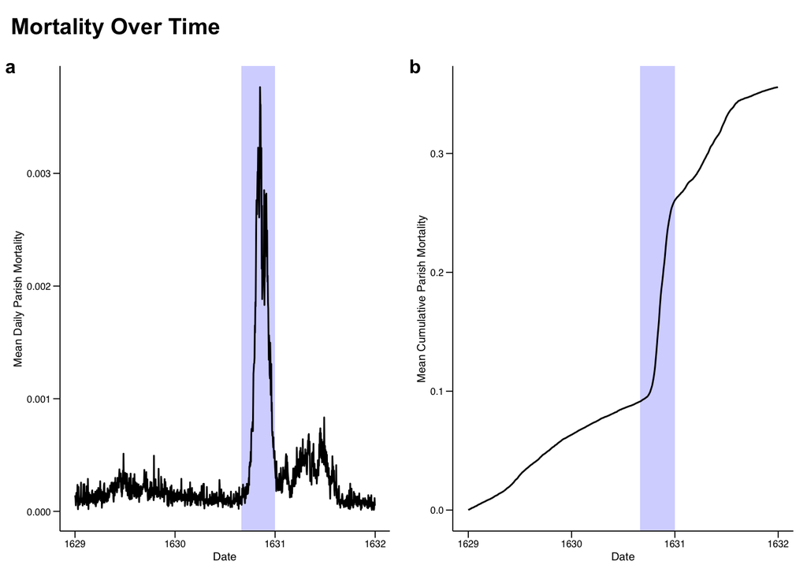

```r
mort_df <- as.data.frame(matrix(NA, ncol = 3, nrow = nrow(filled_modified)))
colnames(mort_df) <- c("Date", "Mort", "CumMort")
mort_df$Date <- as.Date(filled$Date)

for(i in 1:nrow(filled_modified)){
  mort_df[i,2] <- sum(as.numeric(filled_nodate[i,]) / (population_specified$Population * 1000)) / ncol(filled_nodate)
  mort_df[i,3] <- sum(as.numeric(colSums(filled_nodate[1:i,])) / (population_specified$Population * 1000)) / ncol(filled_nodate)
}

regions <- tibble(x1 = as.Date("1630-09-01"), x2 = as.Date("1630-12-31"), y1 = -Inf, y2 = +Inf)

daily_mort_plot <- ggplot(mort_df)+
  geom_rect(data = regions, inherit.aes = FALSE, mapping = aes(xmin = x1, xmax = x2, ymin = y1, ymax = y2),color = "transparent",fill = "blue", alpha = 0.2)+
  geom_line(aes(x = as.Date(Date), y = Mort))+
  labs(x = "Date", y = "Mean Daily Parish Mortality", title = "Daily Mortality")+
  plot_theme()

cumulative_mort_plot <- ggplot(mort_df)+
  geom_rect(data = regions, inherit.aes = FALSE, mapping = aes(xmin = x1, xmax = x2, ymin = y1, ymax = y2), color = "transparent", fill = "blue", alpha = 0.2)+
  geom_line(aes(x = as.Date(Date), y = CumMort))+
  labs(x = "Date", y = "Mean Cumulative Parish Mortality", title = "Cumulative Mortality")+
  plot_theme()

untitled_grid <- plot_grid(plotlist = list(daily_mort_plot, cumulative_mort_plot),labels = c("a", "b"), label_size = 12)

title <- ggdraw() +
  draw_label(
    "Mortality Over Time",
    fontface = 'bold',
    x = 0,
    hjust = 0
  ) +
  theme(
    # add margin on the left of the drawing canvas,
    # so title is aligned with left edge of first plot
    plot.margin = margin(0, 0, 0, 7)
  )
plot_grid(
  title, untitled_grid,
  ncol = 1,
  # rel_heights values control vertical title margins
  rel_heights = c(0.1, 1)
)
```

```r
# Save the figure
ggsave(
  filename = file.path(
    "Figures_Final_v2",
    "SuppFig7.pdf"
  ),
  width = 180,
  height = 108,
  units = "mm",
  bg = "white"
)

ggsave(
  filename = file.path(
    "Figures_Final_v2",
    "SuppFig7.png"
  ),
  width = 180,
  height = 108,
  units = "mm",
  dpi = 300,
  bg = "white"
)

sestiere_vec <- c()
for(i in unique(sestiere_df_modified$Sestiere)){
  sestiere_vec <- c(sestiere_vec, length(sestiere_df_modified$Parish[sestiere_df_modified$Sestiere==i]))
}
print(sum(sestiere_vec) / length(sestiere_vec))
```

```
## [1] 8.333333
```

```r
print(sd(sestiere_vec))
```

```
## [1] 3.204164
```

```r
final_mortality <- as.numeric(colSums(filled_modified[1:nrow(filled_modified),-1]) / (population_specified_modified$Population * 1000))
mean_mortality <- c()
for(i in unique(sestiere_df_modified$Sestiere)){
  sestiere_mortality <- final_mortality[which(population_specified_modified$Parish %in% sestiere_df_modified$Parish[sestiere_df_modified$Sestiere == i])]
  mean_mortality <- c(mean_mortality, sum(sestiere_mortality) / length(sestiere_mortality))
  print(sd(sestiere_mortality))
}
```

```
## [1] 0.05337608
## [1] 0.08957215
## [1] 0.08740672
## [1] 0.05784152
## [1] 0.0867793
## [1] 0.1181712
```

```r
print(sum(mean_mortality) / length(mean_mortality))
```

```
## [1] 0.3695479
```

```r
print(sd(mean_mortality))
```

```
## [1] 0.01613402
```

# Sensitivity Analyses

In this section, we conduct several sensitivity analyses to address the extent to which the limitations of our methodology may have affected our results.

## Testing Binning Methods

In this section, we compare the entropy of the PDF with that of the histogram-approximated normal distribution with identical mean and variance to the data. In particular, we make this comparison for three bin selection methods.

### Sturges’ Rule

Here, we implement Sturges’ Rule to determine the number of bins ($K = \lceil \log_2(n)\rceil + 1$). Since we have a consistent number of parishes ($n = 50$), Sturges’ Rule will always result in a 7 bin histogram.

```r
normal_approx <- function (x, K = ceiling(log2(length(x))) + 1){
  bins <- seq(min(x), max(x), length.out = K + 1)
  bins2 <- rep(0, K)
  for(i in 1:K){
    bins2[i] <- (bins[i] + bins[i + 1]) / 2
  }
  y <- dnorm(bins2, mean = mean(x), sd = sd(x))
  y <- y / sum(y)
  y_2 <- diff(pnorm(bins, mean(x), sd(x)))
  return(y)
  #return(log(2 * pi * exp(1)*sigma2)*1/2 + sum(p * log(p)))
}

SR_shannon_PDF_vec <- rep(NA_real_, nrow(filled_modified))
SR_max_entropy_vec <- rep(NA_real_, nrow(filled_modified))
max_differential_entropy_vec <- rep(NA_real_, nrow(filled_modified))
msos_negent_vec <- rep(NA_real_, nrow(filled_modified))
KL_divergence_vec <- rep(NA_real_, nrow(filled_modified))
KL_function_vec <- rep(NA_real_, nrow(filled_modified))
case_df <- as.data.frame(matrix(data = NA, nrow = nrow(filled_modified), ncol = ncol(filled_modified[,-1])))

for(i in 1:nrow(filled_modified)){
  case_vector_2 <- colSums(filled_modified[1:i,-1])/(population_specified_modified$Population * 1000)
  case_df[i,] <- case_vector_2
  p <- normal_approx(case_vector_2)
  max_entropy <- -1 * sum(p*log(p))
  max_differential_entropy <- log(sd(case_vector_2) * sqrt(2 * pi * exp(1))) #Differential Entropy
  kern <- as.numeric(PDF_approx(case_vector_2))
  kern <- kern/sum(kern)

  shannon_PDF <- -1 * sum(kern[kern != 0] * log(kern[kern != 0]))

  KL_divergence <- (-1 * shannon_PDF) - sum(kern[kern != 0] * log(p[kern != 0]))

  KL_function <- KL_new(kern, p)

  SR_shannon_PDF_vec[i] <- shannon_PDF
  SR_max_entropy_vec[i] <- max_entropy
  KL_divergence_vec[i] <- KL_divergence
  KL_function_vec[i] <- KL_function
  max_differential_entropy_vec[i] <- max_differential_entropy
  msos_negent_vec[i] <- negent(case_vector_2)
}
```

Now, we plot:

1. the entropy of the resulting PDF (black) against that of the normal distribution with the same mean and variance (red) for every day in the epidemic
2. the negentropy of the PDF, calculated as entropy of the normal distribution - entropy of the PDF

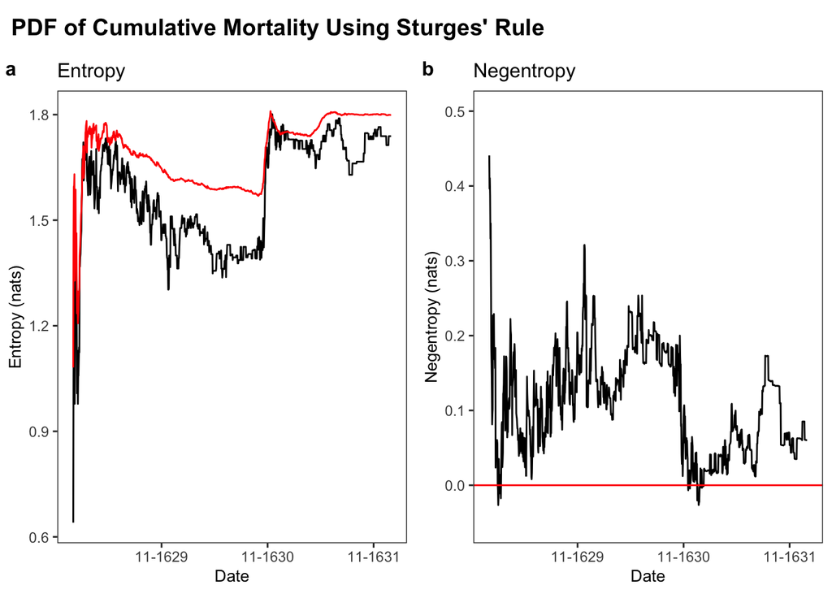

```r
SR_plot_df <- as.data.frame(cbind(SR_shannon_PDF_vec, SR_max_entropy_vec, max_differential_entropy_vec, msos_negent_vec, KL_function_vec, filled$Date))

plot1 <- ggplot(data = SR_plot_df, aes(x = filled$Date, y = SR_shannon_PDF_vec)) +
  geom_line() +
  geom_line(aes(x = filled$Date, y = SR_max_entropy_vec), col = "red") +
  scale_x_date(date_breaks = "12 months", date_labels = "%m-%Y") +
  theme_bw() +
  theme(
    panel.grid.major = element_blank(),
    panel.grid.minor = element_blank(),
    panel.background = element_blank(),
    plot.background = element_rect(fill = "white"),
    axis.title = element_text(size = 10),
    plot.title = element_text(size = 12)
  ) +
  labs(y = "Entropy (nats)", x = "Date", title = "Entropy")

plot2 <- ggplot(data = SR_plot_df, aes(x = filled$Date, y = SR_max_entropy_vec - SR_shannon_PDF_vec)) +
  geom_line() +
  geom_hline(yintercept = 0, color = "red") +
  coord_cartesian(ylim = c(-0.05, 0.5)) +
  scale_x_date(date_breaks = "12 months", date_labels = "%m-%Y") +
  theme_bw() +
  theme(
    panel.grid.major = element_blank(),
    panel.grid.minor = element_blank(),
    panel.background = element_blank(),
    plot.background = element_rect(fill = "white"),
    axis.title = element_text(size = 10),
    plot.title = element_text(size = 12)
  ) +
  labs(y = "Negentropy (nats)", x = "Date", title = "Negentropy")

plot_ls <- list(plot1, plot2)

# Create the grid
untitled_grid <-
  plot_grid(plotlist = plot_ls,
            labels = c("a", "b"),
            label_size = 12)

# Add the title
title <- ggdraw() +
  draw_label(
    "PDF of Cumulative Mortality Using Sturges' Rule",
    fontface = 'bold',
    x = 0,
    hjust = 0
  ) +
  theme(# add margin on the left of the drawing canvas,
    # so title is aligned with left edge of first plot
    plot.margin = margin(0, 0, 0, 7))

plot_grid(title,
          untitled_grid,
          ncol = 1,
          # rel_heights values control vertical title margins
          rel_heights = c(0.1, 1))
```

#### Compare Negentropy Calculations

Compare multiple calculations for negentropy using Sturges’ Rule:

1. Black - Subtracting entropy of histogram-approximated normal by entropy of histogram-approximated PDF
2. Blue - KL divergence of histogram-approximated PDF $P(x)$ from histogram-approximated normal $Q(x)$ using the calculation $-H(P(x)) + H(P(x), Q(x))$ where $H(P(x), Q(x))$ is the cross entropy, defined as $H(P(x), Q(x)) = -\sum_{x \in \mathcal{X}} p(x)\log q(x)$
3. Orange - Negentropy estimates obtained from the msos package’s negent function, which calculates negentropy as $h(Y_G)-H(Y)$ where $h(Y_G)$ is the differential entropy of the normal distribution with the same mean and variance as the data (defined as $\frac{1}{2} \log \left( 2 \pi e \cdot \sigma^2 \right)$) and $H(Y)$ is the entropy (not differential entropy) of the histogram-approximated PDF
4. Pink - KL divergence of histogram-approximated PDF $P(x)$ from histogram-approximated normal $Q(x)$ using the KL_new function defined earlier in this notebook.

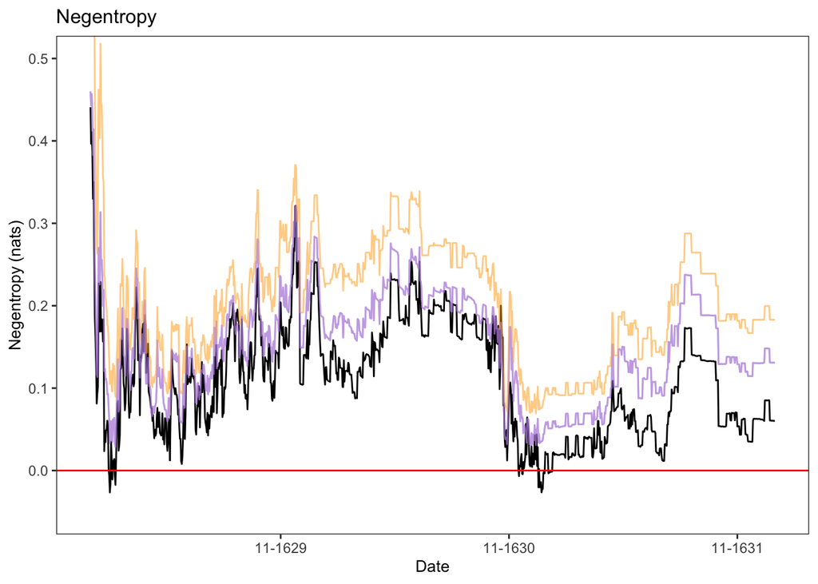

```r
SR_plot_df %>% ggplot(aes(x = filled$Date, y = SR_max_entropy_vec - SR_shannon_PDF_vec)) +
  geom_line() +
  geom_hline(yintercept = 0, color = "red") +
  geom_line(aes(x = filled$Date, y = KL_divergence_vec), color = "blue", alpha = 0.5) +
  geom_line(aes(x = filled$Date, y = msos_negent_vec), color = "orange", alpha = 0.5) +
  geom_line(aes(x = filled$Date, y = KL_function_vec), color = "pink", alpha = 0.5) + #nearly identical to KL_divergence_vec
  coord_cartesian(ylim = c(-0.05, 0.5)) +
  scale_x_date(date_breaks = "12 months", date_labels = "%m-%Y") +
  theme_bw() +
  theme(
    panel.grid.major = element_blank(),
    panel.grid.minor = element_blank(),
    panel.background = element_blank(),
    plot.background = element_rect(fill = "white"),
    axis.title = element_text(size = 10),
    plot.title = element_text(size = 12)
  ) +
  labs(y = "Negentropy (nats)", x = "Date", title = "Negentropy")
```

All of these graphs appear to be vertical shifts of one another, confirming that they represent the same underlying statistic. For the purposes of consistency, we use the msos negent function.

### Freedman-Diaconis

```r
freedman_diaconis <- function (x){
  bin_width = 2 * IQR(x) * (length(x))^(-1/3)
  num_bins = ceiling((max(x) - min(x))/bin_width)
  return(num_bins)
}

FD_max_entropy_vec <- rep(NA_real_, nrow(filled_modified))
FD_max_differential_entropy_vec <- rep(NA_real_, nrow(filled_modified))
FD_shannon_PDF_vec <- rep(NA_real_, nrow(filled_modified))

# Exclude the first day since the high prevalence of zeroes results in undefined IQR
for(i in 2:nrow(filled_modified)){
  case_vector_2 <- colSums(filled_modified[1:i,-1])/(population_specified_modified$Population * 1000)
  num_bins <- as.numeric(freedman_diaconis(case_vector_2))
  p <- normal_approx(case_vector_2, K = num_bins)
  max_entropy <- -1 * sum(p*log(p))
  max_differential_entropy <- log(sd(case_vector_2) * sqrt(2 * pi * exp(1))) #Differential Entropy
  kern <- as.numeric(PDF_approx(case_vector_2, K = num_bins))
  kern <- kern/sum(kern)
  shannon_PDF <- -1 * sum(kern[kern != 0] * log(kern[kern != 0]))

  FD_max_entropy_vec[i] <- max_entropy
  FD_max_differential_entropy_vec[i] <- max_differential_entropy
  FD_shannon_PDF_vec[i] <- shannon_PDF
}
```

Now, we plot the entropy of the resulting PDF (black) against that of the normal distribution with the same mean and variance (red) for every day in the epidemic.

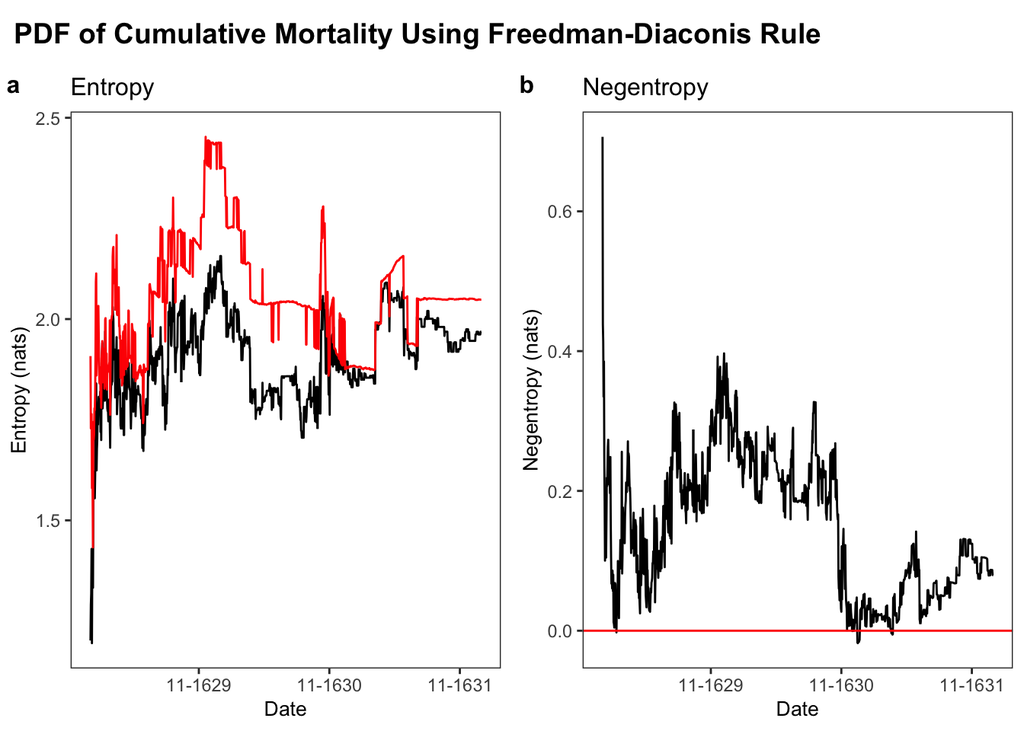

```r
FD_plot_df <- as.data.frame(cbind(FD_shannon_PDF_vec, FD_max_entropy_vec, FD_max_differential_entropy_vec, filled$Date))
plot1 <- ggplot(data = FD_plot_df, aes(x = filled$Date, y = FD_shannon_PDF_vec)) +
  geom_line() +
  geom_line(aes(x = filled$Date, y = FD_max_entropy_vec), col = "red") +
  scale_x_date(date_breaks = "12 months", date_labels = "%m-%Y") +
  theme_bw() +
  theme(
    panel.grid.major = element_blank(),
    panel.grid.minor = element_blank(),
    panel.background = element_blank(),
    plot.background = element_rect(fill = "white"),
    axis.title = element_text(size = 10),
    plot.title = element_text(size = 12)
  ) +
  labs(y = "Entropy (nats)", x = "Date", title = "Entropy")

plot2 <- ggplot(data = FD_plot_df, aes(x = filled$Date, y = FD_max_entropy_vec - FD_shannon_PDF_vec)) +
  geom_line() +
  geom_hline(yintercept = 0, color = "red") +
  scale_x_date(date_breaks = "12 months", date_labels = "%m-%Y") +
  theme_bw() +
  theme(
    panel.grid.major = element_blank(),
    panel.grid.minor = element_blank(),
    panel.background = element_blank(),
    plot.background = element_rect(fill = "white"),
    axis.title = element_text(size = 10),
    plot.title = element_text(size = 12)
  ) +
  labs(y = "Negentropy (nats)", x = "Date", title = "Negentropy")

plot_ls <- list(plot1, plot2)

# Create the grid
untitled_grid <-
  plot_grid(plotlist = plot_ls,
            labels = c("a", "b"),
            label_size = 12)
# Add the title
title <- ggdraw() +
  draw_label(
    "PDF of Cumulative Mortality Using Freedman-Diaconis Rule",
    fontface = 'bold',
    x = 0,
    hjust = 0
  ) +
  theme(# add margin on the left of the drawing canvas,
    # so title is aligned with left edge of first plot
    plot.margin = margin(0, 0, 0, 7))

plot_grid(title,
          untitled_grid,
          ncol = 1,
          # rel_heights values control vertical title margins
          rel_heights = c(0.1, 1))
```

### Kernel-Density Estimation

Finally, here we use Kernel-Density Estimation (KDE) with 512 bins. Note that because we are using KDE to approximate differential entropy, the entropy values may be negative. However, because these differential entropy estimates are being compared against the differential entropy of the normal distribution, the negentropy values should still be similar to those obtained from the other two binning methods.

```r
kde_entropy <- function(x, n_points = 512) {
  x <- x[is.finite(x)]

  if (length(x) < 2L || length(unique(x)) < 2L) {
    return(c(entropy = NA_real_,
             maximum_entropy = NA_real_,
             negentropy = NA_real_))
  }

  d <- density(x, n = n_points)
  dx <- d$x[2L] - d$x[1L]

  f <- d$y / sum(d$y * dx)
  positive <- f > 0

  h <- -sum(f[positive] * log(f[positive])) * dx

  mu <- sum(d$x * f) * dx
  variance <- sum((d$x - mu)^2 * f) * dx
  h_normal <- 0.5 * log(2 * pi * exp(1) * variance)

  c(
    entropy = h,
    maximum_entropy = h_normal,
    negentropy = h_normal - h
  )
}

KDE_max_entropy_vec <- rep(0, nrow(filled_modified))
KDE_shannon_PDF_vec <- rep(0, nrow(filled_modified))

for (i in 1:nrow(filled_modified)) {
  case_vector_2 <- colSums(filled_modified[1:i, -1]) / (population_specified_modified$Population * 1000)
  kde_output_vec <- kde_entropy(case_vector_2)
  KDE_shannon_PDF_vec[i] <- kde_output_vec[1]
  KDE_max_entropy_vec[i] <- kde_output_vec[2]
}
```

Now, we plot the entropy of the resulting PDF (black) against that of the normal distribution with the same mean and variance (red) for every day in the epidemic.

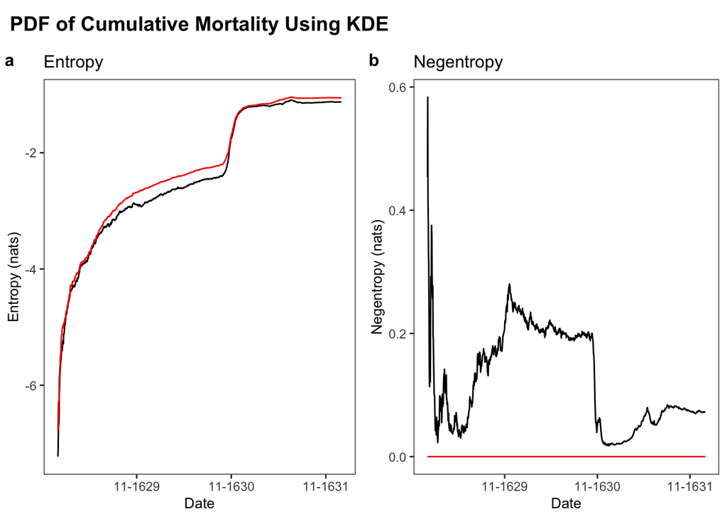

```r
KDE_plot_df <- as.data.frame(cbind(KDE_shannon_PDF_vec, KDE_max_entropy_vec, filled$Date))
plot1 <- ggplot(data = KDE_plot_df, aes(x = filled$Date, y = KDE_shannon_PDF_vec)) +
  geom_line() +
  geom_line(aes(x = filled$Date, y = KDE_max_entropy_vec), col = "red") +
  scale_x_date(date_breaks = "12 months", date_labels = "%m-%Y") +
  theme_bw() +
  theme(
    panel.grid.major = element_blank(),
    panel.grid.minor = element_blank(),
    panel.background = element_blank(),
    plot.background = element_rect(fill = "white"),
    axis.title = element_text(size = 10),
    plot.title = element_text(size = 12)
  ) +
  labs(y = "Entropy (nats)", x = "Date", title = "Entropy")

plot2 <- ggplot(data = KDE_plot_df, aes(x = filled$Date, y = KDE_max_entropy_vec - KDE_shannon_PDF_vec)) +
  geom_line() +
  geom_line(aes(x = filled$Date, y = rep(0, nrow(filled_modified))), col = "red") +
  scale_x_date(date_breaks = "12 months", date_labels = "%m-%Y") +
  theme_bw() +
  theme(
    panel.grid.major = element_blank(),
    panel.grid.minor = element_blank(),
    panel.background = element_blank(),
    plot.background = element_rect(fill = "white"),
    axis.title = element_text(size = 10),
    plot.title = element_text(size = 12)
  ) +
  labs(y = "Negentropy (nats)", x = "Date", title = "Negentropy")

plot_ls <- list(plot1, plot2)

# Create the grid
untitled_grid <-
  plot_grid(plotlist = plot_ls,
            labels = c("a", "b"),
            label_size = 12)

# Add the title
title <- ggdraw() +
  draw_label(
    "PDF of Cumulative Mortality Using KDE",
    fontface = 'bold',
    x = 0,
    hjust = 0
  ) +
  theme(# add margin on the left of the drawing canvas,
    # so title is aligned with left edge of first plot
    plot.margin = margin(0, 0, 0, 7))

plot_grid(title,
          untitled_grid,
          ncol = 1,
          # rel_heights values control vertical title margins
          rel_heights = c(0.1, 1))
```

### Supplementary Figure S10

Compare KL Divergence estimates from the three methods:

1. Sturges’ Rule (Black)
2. Freedman-Diaconis Rule (Orange)
3. KDE Approximation (Blue)

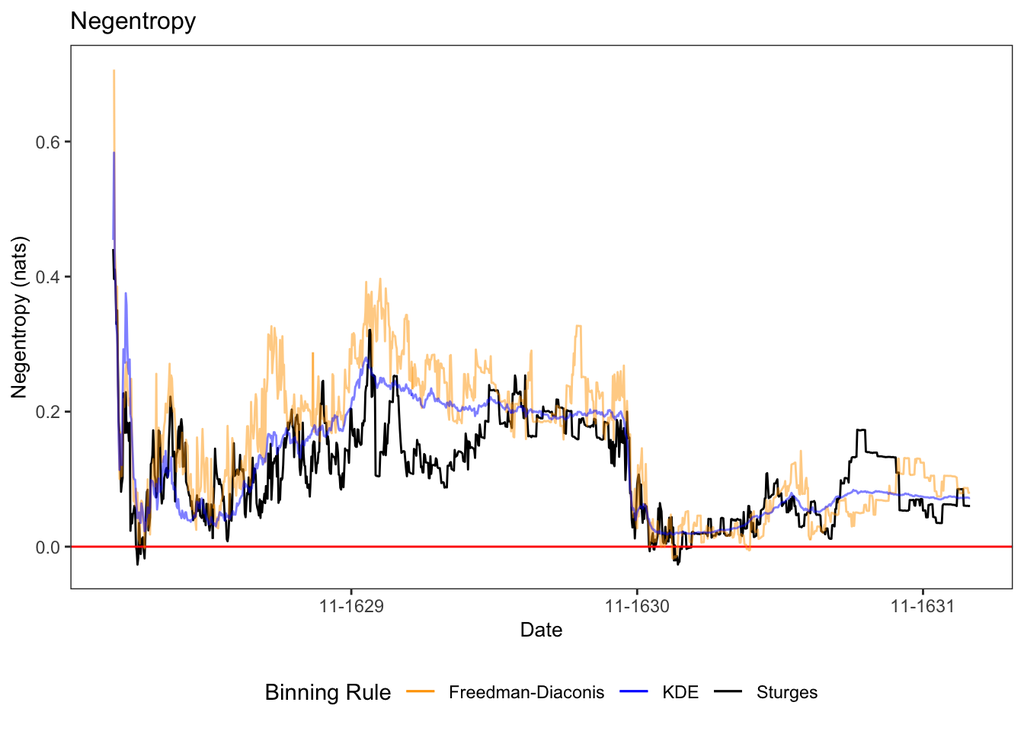

```r
plot_df <- as.data.frame(cbind(KDE_shannon_PDF_vec, KDE_max_entropy_vec, FD_shannon_PDF_vec, FD_max_entropy_vec, SR_shannon_PDF_vec, SR_max_entropy_vec, filled$Date))

binning_comparison_figure <- ggplot(data = plot_df, aes(x = filled$Date)) +
  geom_line(aes(y = SR_max_entropy_vec - SR_shannon_PDF_vec, col = "Sturges")) +
  geom_hline(yintercept = 0, col = "red") +
  geom_line(aes(y = FD_max_entropy_vec - FD_shannon_PDF_vec, col = "Freedman-Diaconis"), alpha = 0.5) +
  geom_line(aes(y = KDE_max_entropy_vec - KDE_shannon_PDF_vec, color = "KDE"), alpha = 0.5) +
  scale_color_manual(
    name = "Binning Rule",
    values = c(
      "Sturges" = "black",
      "Freedman-Diaconis" = "orange",
      "KDE" = "blue"
      )
    ) +
  scale_x_date(date_breaks = "12 months", date_labels = "%m-%Y") +
  theme_bw() +
  theme(
    panel.grid.major = element_blank(),
    panel.grid.minor = element_blank(),
    panel.background = element_blank(),
    plot.background = element_rect(fill = "white"),
    axis.title = element_text(size = 10),
    plot.title = element_text(size = 12),
    legend.position = "bottom"
  ) +
  labs(y = "Negentropy (nats)", x = "Date", title = "Negentropy")

# Display the completed figure
binning_comparison_figure
```

```r
output_directory <- "Figures_Final_v2"

# Preferred vector version
ggsave(filename = file.path(
    output_directory,
    "SuppFig10.pdf"
  ),
  plot = binning_comparison_figure,
  width = 2100,
  height = 1500,
  units = "px",
  bg = "white")
# Publication-resolution raster version
ggsave(
  filename = file.path(output_directory, "SuppFig10.tiff"),
  plot = binning_comparison_figure,
  width = 2100,
  height = 1500,
  units = "px",
  dpi = 300,
  compression = "lzw",
  bg = "white"
)
# PNG for manuscript draft
ggsave(filename = file.path(
    output_directory,
    "SuppFig10.png"
  ),
  plot = binning_comparison_figure,
  width = 2100,
  height = 1500,
  units = "px",
  dpi = 300,
  bg = "white")
```

## Dynamic Parish Populations

In this section, we repeat our entropy calculations using dynamic parish populations; specifically, the population of a parish on day $d$ is represented as the population of that parish on January 1, 1629 minus the total deaths in that parish up to but not including day $d$. Ignoring births, the purpose of this analysis is to quantify the extent to which the assumption of fixed parish populations artifactually drives the distribution of cumulative mortality towards uniformity. We also test how the effect of this modification changes when we begin our analysis on January 1, 1629 vs. when we begin our analysis on the first day of the outbreak.

Identify the first day of the outbreak (new_start_date).

```r
# Find how many parishes had zero deaths on a particular day
num_zeroes <- rep(NA_real_, nrow(filled_modified))

for(i in 1:nrow(filled_modified)){
  num_zeroes[i] <- sum(filled_modified[i,-1] == 0)
}

# Print the day on which the number of parishes with at least one death was greatest
print(match(min(num_zeroes), num_zeroes))
```

```
## [1] 697
```

```r
# Print the index of September 1, 1630
print(match(as.Date("1630-09-01", format = "%Y-%m-%d"), filled_modified$Date))
```

```
## [1] 609
```

```r
# After manually going through the data, day 637 is when the number of deaths rises above the levels reached in the secondary wave.
new_start_date <- 1 #Set this as 1 if we want to start on January 1, 1629
```

To distinguish between entropy increasing due to the first instance of a case in a parish and the overall distribution approaching uniformity, we identify the first day after our new start date that all parishes have at least one case.

```r
non_zero_parish_day <- NA_real_

for(i in new_start_date:nrow(filled_modified)){
  cumulative_cv <- colSums(filled_modified[new_start_date:i, -1])
  if(sum(cumulative_cv == 0) == 0){
    non_zero_parish_day <- i
    print(non_zero_parish_day)
    break
  }
}
```

```
## [1] 654
```

```r
# What's the last zero parish?

print(which(colSums(filled_modified[new_start_date:(non_zero_parish_day - 60),-1]) == 0))
```

```
## S.Severo   S.Toma
##       40       45
```

```r
# What parishes have no cases up to the start of the outbreak?

print(which(colSums(filled_modified[1:609, -1]) == 0))
```

```
## S.Severo   S.Toma
##       40       45
```

```r
# What parishes have no new cases the day the outbreak starts?

print(which(filled_modified[637, -1] == 0))
```

```
##  [1]  5  7  8  9 13 18 21 22 23 24 28 29 30 32 33 36 37 39 40 41 42 43 44 45 47
## [26] 48
```

If we’re starting at the epidemic, remove all of the parishes that don’t have any cases 30 days after the start of the epidemic to eliminate the possibility that entropy increases simply because parishes with zero cases get their first case.

```r
if(new_start_date != 1){
  outliers_temporary <- c("S.Polo", "S.Stae", "S.Marco", "S.Basso", "S.Pantalon", "S.Silvestro", "S.Simon.Grande", "S.Toma", "S.Severo")
  filled_modified_temporary <- filled[, !(colnames(filled) %in% outliers_temporary)]
  population_specified_modified_temporary <- population_specified[!(population_specified$Parish %in% outliers_temporary),]
} else {
  filled_modified_temporary <- filled_modified
  population_specified_modified_temporary <- population_specified_modified
}
```

Now what’s the first day where no parish has zero cases starting from our new start date?

```r
non_zero_parish_day <- NA_real_

for(i in new_start_date:nrow(filled_modified_temporary)){
  cumulative_cv <- colSums(filled_modified_temporary[new_start_date:i, -1])
  if(sum(cumulative_cv == 0) == 0){
    non_zero_parish_day <- i
    print(non_zero_parish_day)
    break
  }
}
```

```
## [1] 654
```

Define function to compare dynamic and non-dynamic parish populations.

```r
dynamic_population_comparison <-
  function(death_data,
           population_data,
           start_date,
           dynamic = FALSE) {

    instantaneous_mortality_df <-
      as.data.frame(matrix(
        NA_real_,
        nrow = nrow(death_data),
        ncol = ncol(death_data) - 1
      ))

    population_data_copy <- population_data

    shannonPDF_vec <- rep(NA_real_, nrow(death_data))
    shannonNormal_vec <- rep(NA_real_, nrow(death_data))
    shannonQuantile_vec <- rep(NA_real_, nrow(death_data))
    negentPDF_vec <- rep(NA_real_, nrow(death_data))
    uniformKL_Quantile_vec <- rep(NA_real_, nrow(death_data))

    for (i in start_date:nrow(death_data)) {
      instantaneous_cv <-
        death_data[i,-1] / (population_data_copy$Population * 1000)
      instantaneous_mortality_df[i,] <- instantaneous_cv

      cumulative_cv <-
        colSums(instantaneous_mortality_df[start_date:i, ])
      cumulative_cv <- sort(cumulative_cv)

      # Normalized case vector (cumulative_cv_norm): quantile function
      cumulative_cv_norm <- cumulative_cv / sum(cumulative_cv)

      histogram_normal <- normal_approx(cumulative_cv_norm)
      histogram_normal_entropy <-
        -1 * sum(histogram_normal * log(histogram_normal))

      kern <- PDF_approx(cumulative_cv)
      kern <- kern / sum(kern)

      shannon_PDF <- -1 * sum(kern[kern != 0] * log(kern[kern != 0]))

      #kde_output_vec_2 <- kde_entropy(cumulative_cv)

      #differential_entropy_PDF <- kde_output_vec_2[1]
      #max_entropy_PDF <- kde_output_vec_2[2]

      #negent_PDF <- max_entropy_PDF - differential_entropy_PDF

      #negent_PDF <- negent(cumulative_cv)

      negent_PDF <- KL_new(kern, histogram_normal)

      shannon_quantile <-
        -1 * sum(cumulative_cv_norm[cumulative_cv_norm != 0] * log(cumulative_cv_norm[cumulative_cv_norm != 0]))

      uniform_KL_quantile <-
        KL_new(cumulative_cv_norm, rep(
          1 / length(cumulative_cv_norm),
          length(cumulative_cv_norm)
        ))

      if (dynamic) {
        population_data_copy$Population <-
          population_data_copy$Population - (as.numeric(death_data[i, -1]) / 1000)
      }

      shannonPDF_vec[i] <- shannon_PDF
      shannonNormal_vec[i] <- histogram_normal_entropy
      shannonQuantile_vec[i] <- shannon_quantile
      negentPDF_vec[i] <- negent_PDF
      uniformKL_Quantile_vec[i] <- uniform_KL_quantile
    }
    return(
      list(
        shannonPDF = shannonPDF_vec,
        shannonNormal = shannonNormal_vec,
        shannonQuantile = shannonQuantile_vec,
        negentPDF = negentPDF_vec,
        uniformKL_Quantile = uniformKL_Quantile_vec
      )
    )
  }
```

Compare statistics when analyzing the data starting on January 1, 1629 (first day in dataset) vs. the data starting on September 1, 1630 (first day of primary outbreak).

```r
remove_zero_parishes <- FALSE

if(remove_zero_parishes){
  outliers_temporary <- c("S.Polo", "S.Stae", "S.Marco", "S.Basso", "S.Pantalon", "S.Silvestro", "S.Simon.Grande", "S.Toma", "S.Severo")
  filled_modified_temporary <- filled[, !(colnames(filled) %in% outliers_temporary)]
  population_specified_modified_temporary <- population_specified[!(population_specified$Parish %in% outliers_temporary),]
} else{
  filled_modified_temporary <- filled_modified
  population_specified_modified_temporary <- population_specified_modified_temporary
}

fixed_january_start <- dynamic_population_comparison(death_data = filled_modified_temporary,
           population_data = population_specified_modified_temporary,
           start_date = 1,
           dynamic = FALSE)

print(fixed_january_start$shannonQuantile[nrow(filled_modified_temporary)])
```

```
## [1] 3.886048
```

```r
dynamic_january_start <- dynamic_population_comparison(death_data = filled_modified_temporary,
           population_data = population_specified_modified_temporary,
           start_date = 1,
           dynamic = TRUE)

print(dynamic_january_start$shannonQuantile[nrow(filled_modified_temporary)])
```

```
## [1] 3.872334
```

```r
new_start_date <- 609

fixed_outbreak_start <- dynamic_population_comparison(death_data = filled_modified_temporary,
           population_data = population_specified_modified_temporary,
           start_date = new_start_date,
           dynamic = FALSE)

dynamic_outbreak_start <- dynamic_population_comparison(death_data = filled_modified_temporary,
           population_data = population_specified_modified_temporary,
           start_date = new_start_date,
           dynamic = TRUE)
```

### Supplementary Figure S9

Create quantile function entropy plot and PDF negentropy plot starting on January 1, 1629.

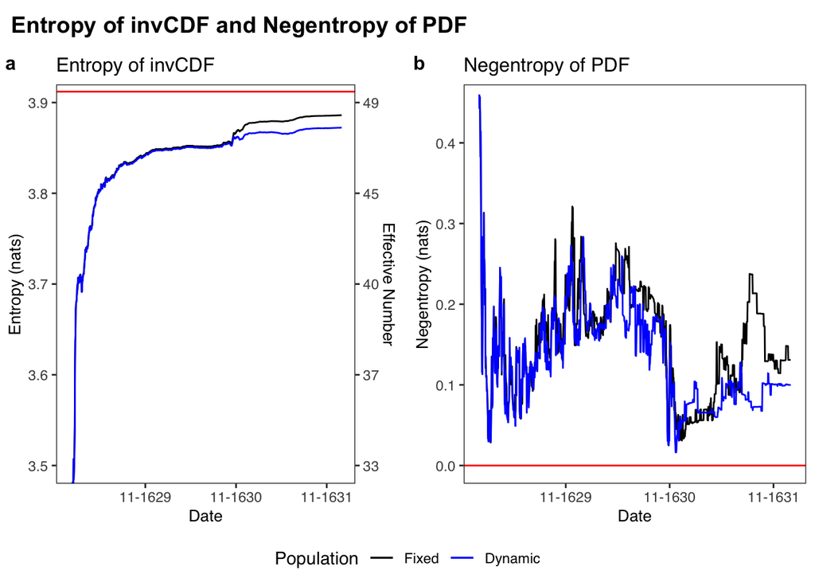

```r
# Initialize dataframe with 2.5th percentile value, 97.5th percentile value, and original value of shannonQuantile
plot_df <- data.frame(
  Date = filled$Date,
  fixed = fixed_january_start$shannonQuantile,
  dynamic = dynamic_january_start$shannonQuantile
)

shared_theme <- theme_bw(base_family = "sans") +
  theme(
    panel.grid.major = element_blank(),
    panel.grid.minor = element_blank(),
    panel.background = element_blank(),
    plot.background = element_rect(fill = "white"),
    axis.title = element_text(size = 10),
    plot.title = element_text(size = 12),
    legend.position = "bottom"
  )

plot1 <- ggplot(data = plot_df, aes(x = Date)) +
  geom_line(aes(y = fixed, color = "Fixed")) +
  geom_line(aes(y = dynamic, color = "Dynamic")) +
  geom_hline(yintercept = log(
    ncol(filled_modified[, -1])
  ), col = "red") +
  scale_color_manual(
    name = "Population",
    breaks = c("Fixed", "Dynamic"),
    values = c(
      "Dynamic" = "blue",
      "Fixed" = "black"
    )
  ) +
  coord_cartesian(ylim = c(3.5, 3.9)) +
  # coord_cartesian(ylim=c(3.5,3.95))+ #S. Marco
  scale_x_date(date_breaks = "12 months", date_labels = "%m-%Y") +
  scale_y_continuous(
    name = "Entropy (nats)",
    sec.axis = sec_axis( #create second y-axis for effective number of parishes
      trans =  ~ .,
      name = "Effective Number",
      labels = function(x)
        scales::comma(round(exp(x)), accuracy = 1)
    )
  ) +
  labs(y = "Entropy (nats)", x = "Date", title = "Entropy of invCDF") +
  shared_theme

# Initialize dataframe containing 2.5th percentile values, 97.5th percentile values, and observed values of the negentropy of the PDF
plot_df_2 <- data.frame(
  Date = filled$Date,
  fixed = fixed_january_start$negentPDF,
  dynamic = dynamic_january_start$negentPDF
)

plot2 <- ggplot(data = plot_df_2, aes(x = Date)) +
  geom_line(aes(y = fixed, color = "Fixed")) +
  geom_line(aes(y = dynamic, color = "Dynamic")) +
  geom_hline(yintercept = 0, col = "red") +
  scale_color_manual(
    name = "Population",
    breaks = c("Fixed", "Dynamic"),
    values = c(
      "Dynamic" = "blue",
      "Fixed" = "black"
    )
  ) +
  coord_cartesian(ylim = c(0, 0.45)) +
  # coord_cartesian(ylim=c(0,1.5))+ #S. Marco
  scale_x_date(date_breaks = "12 months", date_labels = "%m-%Y") +
  scale_y_continuous() +
  labs(y = "Negentropy (nats)", x = "Date", title = "Negentropy of PDF") +
  shared_theme

# Goal: Condense the two legends into a single one

# Obtain the shared legend
shared_legend <- get_legend(plot1)

# Remove the legends from individual plots
plot1_clean <- plot1 + theme(legend.position = "none")
plot2_clean <- plot2 + theme(legend.position = "none")

# Order such that invCDF entropy graph is on the left and PDF negentropy graph is on the right
plot_ls <- list(plot1_clean, plot2_clean)

# Create grid
untitled_grid <-
  plot_grid(plotlist = plot_ls,
            labels = c("a", "b"),
            label_size = 12)

# now add the title
title <- ggdraw() +
  draw_label(
    "Entropy of invCDF and Negentropy of PDF",
    fontface = 'bold',
    x = 0,
    hjust = 0
  ) +
  theme(# add margin on the left of the drawing canvas,
    # so title is aligned with left edge of first plot
    plot.margin = margin(0, 0, 0, 7))

dynamic_comparison_starting_on_january_figure <- plot_grid(title,
          untitled_grid,
          shared_legend,
          ncol = 1,
          # rel_heights values control vertical title margins
          rel_heights = c(0.1, 1, 0.1))

print(dynamic_comparison_starting_on_january_figure)
```

```r
ggsave(
  filename = file.path(
    "Figures_Final_v2",
    "SuppFig9.png"
  ),
  plot = dynamic_comparison_starting_on_january_figure,
  width = 2100,
  height = 1200,
  units = "px",
  dpi = 300,
  bg = "white"
)

ggsave(
  filename = file.path(
    "Figures_Final_v2",
    "SuppFig9.pdf"
  ),
  plot = dynamic_comparison_starting_on_january_figure,
  width = 2100,
  height = 1200,
  units = "px",
  dpi = 300,
  bg = "white"
)
```

Create quantile function entropy plot and PDF negentropy plot starting on September 1, 1630.

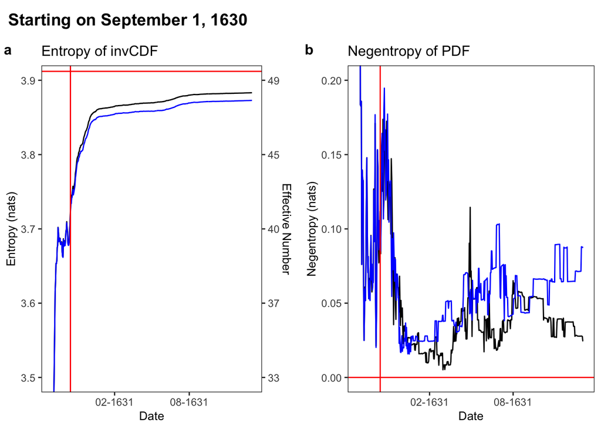

```r
# Initialize dataframe with 2.5th percentile value, 97.5th percentile value, and original value of shannonQuantile
plot_df <-
  as.data.frame(
    cbind(
      fixed_outbreak_start$shannonQuantile,
      dynamic_outbreak_start$shannonQuantile
    )
  )
colnames(plot_df) <- c("fixed", "dynamic")

plot1 <- ggplot(data = plot_df, aes(x = filled$Date, y = fixed)) +
  geom_line() +
  geom_line(aes(y = dynamic), col = "blue") +
  geom_hline(yintercept = log(
    ncol(filled_modified_temporary[, -1])
  ), col = "red") +
  geom_vline(xintercept = as.numeric(as.Date("1629-01-01") + non_zero_parish_day), col = "red") +
  coord_cartesian(ylim = c(3.5, 3.9), xlim = c(as.Date("1630-09-01"), as.Date("1631-12-31"))) +
  # coord_cartesian(ylim=c(3.5,3.95))+ #S. Marco
  scale_x_date(date_breaks = "6 months", date_labels = "%m-%Y") +
  scale_y_continuous(
    name = "Entropy (nats)",
    sec.axis = sec_axis( #create second y-axis for effective number of parishes
      trans =  ~ .,
      name = "Effective Number",
      labels = function(x)
        scales::comma(round(exp(x)), accuracy = 1)
    )
  ) +
  theme_bw() +
  theme(
    panel.grid.major = element_blank(),
    panel.grid.minor = element_blank(),
    panel.background = element_blank(),
    plot.background = element_rect(fill = "white"),
    axis.title = element_text(size = 10),
    plot.title = element_text(size = 12)
  ) +
  labs(y = "Entropy (nats)", x = "Date", title = "Entropy of invCDF")

# Initialize dataframe containing 2.5th percentile values, 97.5th percentile values, and observed values of the negentropy of the PDF
plot_df_2 <-
  as.data.frame(
    cbind(
      fixed_outbreak_start$negentPDF,
      dynamic_outbreak_start$negentPDF
    )
  )
colnames(plot_df_2) <- c("fixed", "dynamic")

plot2 <- ggplot(data = plot_df_2, aes(x = filled$Date, y = fixed)) +
  geom_line() +
  geom_line(aes(y = dynamic), col = "blue") +
  geom_hline(yintercept = 0, col = "red") +
  geom_vline(xintercept = as.numeric(as.Date("1629-01-01") + non_zero_parish_day), col = "red") +
  coord_cartesian(ylim = c(0, 0.2), xlim = c(as.Date("1630-09-01"), as.Date("1631-12-31"))) +
  # coord_cartesian(ylim=c(0,1.5))+ #S. Marco
  scale_x_date(date_breaks = "6 months", date_labels = "%m-%Y") +
  scale_y_continuous() +
  theme_bw() +
  theme(
    panel.grid.major = element_blank(),
    panel.grid.minor = element_blank(),
    panel.background = element_blank(),
    plot.background = element_rect(fill = "white"),
    axis.title = element_text(size = 10),
    plot.title = element_text(size = 12)
  ) +
  labs(y = "Negentropy (nats)", x = "Date", title = "Negentropy of PDF")

# Order such that invCDF entropy graph is on the left and PDF negentropy graph is on the right
plot_ls <- list(plot1, plot2)

# Create the grid
untitled_grid <-
  plot_grid(plotlist = plot_ls,
            labels = c("a", "b"),
            label_size = 12)
# Add the title
title <- ggdraw() +
  draw_label(
    "Starting on September 1, 1630",
    fontface = 'bold',
    x = 0,
    hjust = 0
  ) +
  theme(# add margin on the left of the drawing canvas,
    # so title is aligned with left edge of first plot
    plot.margin = margin(0, 0, 0, 7))

dynamic_comparison_starting_on_outbreak_figure <- plot_grid(title,
          untitled_grid,
          ncol = 1,
          # rel_heights values control vertical title margins
          rel_heights = c(0.1, 1))

print(dynamic_comparison_starting_on_outbreak_figure)
```

When we start on January 1, 1629, the change in quantile function entropy after the outbreak is mitigated. Intuitively, this makes sense: deaths before the start of the outbreak were likely randomly distributed; thus, the distribution of cumulative mortality likely already reached close to maximum entropy. However, when we start at the beginning of the epidemic, adjusting population estimates by deaths no longer has a large impact.

Generate rough plots that overlay daily mortality data on top of entropy graphs.

```r
plot.ts(shannonPDF_vec, xlim = c(new_start_date, nrow(filled_modified_temporary)), ylim = c(-7, 0))
abline(v = non_zero_parish_day)
lines(shannonPDF_dynamic_vec, col = "red")

plot.ts(exp(shannonQuantile_vec), xlim = c(new_start_date, nrow(filled_modified_temporary)), ylim = c(33, 45)) #Effective number of parishes
abline(v = non_zero_parish_day) # the day on which every parish has non-zero cases
lines(exp(shannonQuantile_dynamic_vec), col = "red") # Dynamic population
lines(rowSums(filled_modified_temporary[,-1])/40 + 35, col = "blue") # Daily mortality
abline(h = ncol(filled_modified_temporary[,-1]), col = "orange") # Total number of parishes

plot.ts(negentPDF_vec, xlim = c(new_start_date, nrow(filled_modified_temporary)), ylim = c(0, 0.2))
abline(v = non_zero_parish_day)
lines(negentPDF_dynamic_vec, col = "red")
lines(rowSums(filled_modified_temporary[,-1])/1000, col = "blue")

plot.ts(uniformKL_Quantile_vec, xlim = c(new_start_date, nrow(filled_modified_temporary)), ylim = c(0, 0.4))
abline(v = non_zero_parish_day)
lines(uniformKL_Quantile_dynamic_vec, col = "red")
lines(rowSums(filled_modified_temporary[,-1])/2000, col = "blue")
```

## Sinusoidal Baseline and Plague-Related Excess Mortality

To estimate how many deaths during the primary outbreak were attributable to plague, we first fit an annual sinusoidal baseline to all observations before September 1, 1630. The harmonic regression below is equivalent to fitting a sinusoid with an estimated mean, amplitude, and phase:

$$B(t) = \beta_0 + \beta_1 \sin(2\pi t / 365.2425) +
\beta_2 \cos(2\pi t / 365.2425).$$

We then extrapolate this non-plague baseline through December 31, 1630 and subtract it from the observed daily mortality. Negative daily differences are retained in the signed estimate for diagnostic purposes, but are set to zero in the estimate of plague-related deaths because they do not represent negative plague cases.

```r
outbreak_start <- as.Date("1630-09-01")
outbreak_end <- as.Date("1630-12-31")
annual_period <- 365.2425

# Aggregate the parish-level mortality counts to a citywide daily count.
baseline_daily <- data.frame(
  Date = filled$Date,
  observed_deaths = rowSums(filled[, -1], na.rm = TRUE)
)
baseline_daily$day_index <- as.numeric(
  baseline_daily$Date - min(baseline_daily$Date)
)
baseline_daily$sin_annual <- sin(
  2 * pi * baseline_daily$day_index / annual_period
)
baseline_daily$cos_annual <- cos(
  2 * pi * baseline_daily$day_index / annual_period
)

pre_plague_daily <- baseline_daily[
  baseline_daily$Date < outbreak_start,
]

sinusoidal_baseline_model <- lm(
  observed_deaths ~ sin_annual + cos_annual,
  data = pre_plague_daily
)

# Baseline fitted values are constrained to be nonnegative because mortality counts cannot be negative.
baseline_daily$expected_baseline_deaths <- pmax(
  predict(sinusoidal_baseline_model, newdata = baseline_daily),
  0
)

outbreak_excess <- baseline_daily[
  baseline_daily$Date >= outbreak_start &
    baseline_daily$Date <= outbreak_end,
]
outbreak_excess$signed_excess_deaths <-
  outbreak_excess$observed_deaths -
  outbreak_excess$expected_baseline_deaths
outbreak_excess$estimated_plague_deaths <- pmax(
  outbreak_excess$signed_excess_deaths,
  0
)

baseline_model_summary <- summary(sinusoidal_baseline_model)
baseline_amplitude <- sqrt(sum(
  coef(sinusoidal_baseline_model)[c("sin_annual", "cos_annual")]^2
))

plague_excess_summary <- data.frame(
  outbreak_start = outbreak_start,
  outbreak_end = outbreak_end,
  observed_deaths = sum(outbreak_excess$observed_deaths),
  expected_baseline_deaths = sum(
    outbreak_excess$expected_baseline_deaths
  ),
  signed_excess_deaths = sum(outbreak_excess$signed_excess_deaths),
  estimated_plague_deaths = sum(
    outbreak_excess$estimated_plague_deaths
  )
)
plague_excess_summary$estimated_plague_fraction <-
  plague_excess_summary$estimated_plague_deaths /
  plague_excess_summary$observed_deaths

print(baseline_model_summary)
```

```
##
## Call:
## lm(formula = observed_deaths ~ sin_annual + cos_annual, data = pre_plague_daily)
##
## Residuals:
##      Min       1Q   Median       3Q      Max
## -17.4457  -4.2513  -0.4938   3.9800  23.6490
##
## Coefficients:
##             Estimate Std. Error t value Pr(>|t|)
## (Intercept)  17.5636     0.2726  64.437  < 2e-16 ***
## sin_annual   -3.4407     0.3926  -8.765  < 2e-16 ***
## cos_annual   -1.9712     0.3699  -5.329  1.4e-07 ***
## ---
## Signif. codes:  0 '***' 0.001 '**' 0.01 '*' 0.05 '.' 0.1 ' ' 1
##
## Residual standard error: 6.516 on 605 degrees of freedom
## Multiple R-squared:   0.16,  Adjusted R-squared:  0.1573
## F-statistic: 57.64 on 2 and 605 DF,  p-value: < 2.2e-16
```

```r
print(paste("Estimated seasonal amplitude:", round(baseline_amplitude, 2)))
```

```
## [1] "Estimated seasonal amplitude: 3.97"
```

```r
print(plague_excess_summary)
```

```
##   outbreak_start outbreak_end observed_deaths expected_baseline_deaths
## 1     1630-09-01   1630-12-31           20923                 2350.367
##   signed_excess_deaths estimated_plague_deaths estimated_plague_fraction
## 1             18572.63                18619.97                 0.8899285
```

The signed excess is the difference between total observed and expected deaths over the entire window. The nonnegative estimate, `estimated_plague_deaths`, is the sum of daily excess deaths after truncating negative daily differences at zero and is the primary estimate of plague-related mortality.

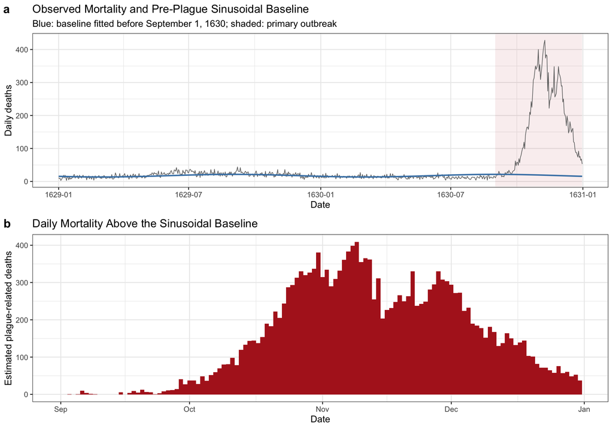

```r
baseline_plot_data <- baseline_daily[
  baseline_daily$Date <= outbreak_end,
]

baseline_plot <- ggplot(
  baseline_plot_data,
  aes(x = Date, y = observed_deaths)
) +
  annotate(
    "rect",
    xmin = outbreak_start,
    xmax = outbreak_end,
    ymin = -Inf,
    ymax = Inf,
    fill = "firebrick",
    alpha = 0.08
  ) +
  geom_line(color = "grey45", linewidth = 0.35) +
  geom_line(
    aes(y = expected_baseline_deaths),
    color = "steelblue",
    linewidth = 0.8
  ) +
  labs(
    x = "Date",
    y = "Daily deaths",
    title = "Observed Mortality and Pre-Plague Sinusoidal Baseline",
    subtitle = "Blue: baseline fitted before September 1, 1630; shaded: primary outbreak"
  ) +
  theme_bw()

excess_plot <- ggplot(
  outbreak_excess,
  aes(x = Date, y = estimated_plague_deaths)
) +
  geom_col(fill = "firebrick", width = 1) +
  labs(
    x = "Date",
    y = "Estimated plague-related deaths",
    title = "Daily Mortality Above the Sinusoidal Baseline"
  ) +
  theme_bw()

plot_grid(
  baseline_plot,
  excess_plot,
  ncol = 1,
  labels = c("a", "b"),
  align = "v"
)
```

## Spatial Clustering Before vs. During the Primary Outbreak

The all-cause mortality data may include deaths from the concurrent smallpox outbreak, particularly before the primary plague wave. We therefore compare the spatial pattern of mortality in the pre-outbreak period (January 1, 1629 through August 31, 1630) with the primary outbreak period (September 1 through December 31, 1630). Period-specific mortality is expressed as deaths per 1,000 person-days so that the unequal lengths of the two periods do not affect the reported rates.

The 1729 parish polygons utilized in the choropleth map generation are used as an approximation to the 1630 parish boundaries. Because the parishes were separated by canals, we define geographic proximity using a symmetric four-nearest-neighbor graph based on projected parish centroids. Analyses using three, five, and eight nearest neighbors assess sensitivity to this choice of spatial scale.

```r
spatial_pre_start <- as.Date("1629-01-01")
spatial_pre_end <- as.Date("1630-08-31")
spatial_outbreak_start <- as.Date("1630-09-01")
spatial_outbreak_end <- as.Date("1630-12-31")
spatial_permutations <- 9999L
spatial_seed <- 1630L
spatial_annual_period <- 365.2425

normalize_spatial_parish <- function(x) {
  x <- gsub("[[:space:]]", ".", x)
  x <- sub("^S\\.\\.", "S.", x)
  x[grepl("^S\\.Mois", x)] <- "S.Moise"
  x[grepl("^S\\.Tom", x)] <- "S.Toma"
  x[grepl("^S\\.Giacomo\\.dell", x)] <- "S.Giacomo.dell.Orio"
  x[x == "S.Angelo.Rafael"] <- "Angelo.Rafael"
  x
}

# Re-read with check.names = FALSE so accented parish names are not dropped by
# locale-dependent name conversion in the notebook's earlier cleaning steps.
spatial_filled <- read.csv(
  "filledna_full_ts.csv",
  check.names = FALSE
)
colnames(spatial_filled)[1] <- "Date"
spatial_filled$Date <- as.Date(spatial_filled$Date, format = "%Y-%m-%d")
colnames(spatial_filled)[-1] <- normalize_spatial_parish(
  colnames(spatial_filled)[-1]
)
spatial_filled[, -1] <- lapply(
  spatial_filled[, -1, drop = FALSE],
  function(x) {
    x <- as.numeric(x)
    x[is.na(x)] <- 0
    x
  }
)

spatial_excluded_parishes <- c(
  "S.Marcilian",
  "S.Polo",
  "S.Stae",
  "S.Marco"
)
spatial_filled <- spatial_filled[
  , !(colnames(spatial_filled) %in% spatial_excluded_parishes)
]

analysis_parishes <- colnames(spatial_filled)[-1]
analysis_parishes_normalized <- normalize_spatial_parish(analysis_parishes)

stopifnot(
  length(analysis_parishes) == 50L,
  !anyDuplicated(analysis_parishes_normalized)
)

population_names_normalized <- normalize_spatial_parish(
  population$Parish
)
population_match <- match(
  analysis_parishes_normalized,
  population_names_normalized
)
stopifnot(!anyNA(population_match))

spatial_population <-
  population$Population[population_match] * 1000
stopifnot(all(is.finite(spatial_population)), all(spatial_population > 0))

pre_period_index <-
  spatial_filled$Date >= spatial_pre_start &
  spatial_filled$Date <= spatial_pre_end
outbreak_period_index <-
  spatial_filled$Date >= spatial_outbreak_start &
  spatial_filled$Date <= spatial_outbreak_end

pre_period_days <- sum(pre_period_index)
outbreak_period_days <- sum(outbreak_period_index)
stopifnot(pre_period_days == 608L, outbreak_period_days == 122L)

pre_period_deaths <- colSums(
  spatial_filled[pre_period_index, -1, drop = FALSE]
)
outbreak_period_deaths <- colSums(
  spatial_filled[outbreak_period_index, -1, drop = FALSE]
)

# Fit the same annual harmonic form used in the preceding citywide baseline
# analysis separately for each parish. Predictions below zero are truncated
# before expected deaths are summed over the outbreak period.
spatial_day_index <- as.numeric(
  spatial_filled$Date - min(spatial_filled$Date)
)
spatial_harmonic_data <- data.frame(
  sin_annual = sin(2 * pi * spatial_day_index / spatial_annual_period),
  cos_annual = cos(2 * pi * spatial_day_index / spatial_annual_period)
)

expected_outbreak_deaths <- rep(NA_real_, length(analysis_parishes))
for (j in seq_along(analysis_parishes)) {
  parish_harmonic_data <- spatial_harmonic_data
  parish_harmonic_data$deaths <- spatial_filled[[analysis_parishes[j]]]

  parish_baseline_model <- lm(
    deaths ~ sin_annual + cos_annual,
    data = parish_harmonic_data[pre_period_index, ]
  )
  parish_expected_daily <- predict(
    parish_baseline_model,
    newdata = parish_harmonic_data[outbreak_period_index, ]
  )

  if (any(!is.finite(parish_expected_daily))) {
    parish_expected_daily <- rep(
      mean(parish_harmonic_data$deaths[pre_period_index]),
      outbreak_period_days
    )
  }

  expected_outbreak_deaths[j] <- sum(pmax(parish_expected_daily, 0))
}

excess_outbreak_deaths <- pmax(
  outbreak_period_deaths - expected_outbreak_deaths,
  0
)

spatial_period_values <- data.frame(
  Parish = analysis_parishes_normalized,
  Population_1629 = spatial_population,
  Pre_outbreak_deaths = as.numeric(pre_period_deaths),
  Outbreak_deaths = as.numeric(outbreak_period_deaths),
  Expected_baseline_deaths = expected_outbreak_deaths,
  Excess_outbreak_deaths = excess_outbreak_deaths
)
spatial_period_values$Pre_outbreak_rate <-
  spatial_period_values$Pre_outbreak_deaths /
  (spatial_period_values$Population_1629 * pre_period_days) * 1000
spatial_period_values$Outbreak_rate <-
  spatial_period_values$Outbreak_deaths /
  (spatial_period_values$Population_1629 * outbreak_period_days) * 1000
spatial_period_values$Excess_outbreak_rate <-
  spatial_period_values$Excess_outbreak_deaths /
  (spatial_period_values$Population_1629 * outbreak_period_days) * 1000

spatial_shape_all <- st_read(
  "1729_PAR_CONF.zip.geojson",
  quiet = TRUE
)
spatial_shape_all$Parish <- normalize_spatial_parish(spatial_shape_all$NAME)
spatial_shape_all <- st_make_valid(spatial_shape_all)

# Dissolve duplicate parish features, including the two S. Leonardo polygons.
spatial_shape_all <- aggregate(
  spatial_shape_all["Parish"],
  by = list(Parish = spatial_shape_all$Parish),
  FUN = function(x) x[1]
)
spatial_shape_crs <- st_crs(spatial_shape_all)
spatial_shape_all <- st_transform(spatial_shape_all, 32633)
spatial_shape_all <- suppressWarnings(st_buffer(spatial_shape_all, 0))
spatial_shape_all <- st_transform(spatial_shape_all, spatial_shape_crs)

shape_match <- match(
  analysis_parishes_normalized,
  spatial_shape_all$Parish
)
stopifnot(!anyNA(shape_match))

spatial_shape <- spatial_shape_all[shape_match, ]
spatial_shape$Parish <- analysis_parishes_normalized
stopifnot(
  nrow(spatial_shape) == 50L,
  !anyDuplicated(spatial_shape$Parish),
  all(st_is_valid(spatial_shape)),
  !any(st_is_empty(spatial_shape))
)

spatial_shape <- merge(
  spatial_shape,
  spatial_period_values,
  by = "Parish",
  sort = FALSE
)
spatial_shape <- spatial_shape[
  match(analysis_parishes_normalized, spatial_shape$Parish),
]

literal_contiguity_neighbors <- st_touches(spatial_shape)
literal_contiguity_isolates <- sum(lengths(literal_contiguity_neighbors) == 0L)
stopifnot(literal_contiguity_isolates == nrow(spatial_shape))
print(paste(
  "Parishes isolated under literal polygon contiguity:",
  literal_contiguity_isolates,
  "of",
  nrow(spatial_shape)
))
```

```
## [1] "Parishes isolated under literal polygon contiguity: 50 of 50"
```

```r
spatial_centroids <- st_centroid(
  st_geometry(st_transform(spatial_shape, 32633))
)
spatial_distance_matrix <- as.matrix(st_distance(spatial_centroids))
spatial_distance_matrix <- units::drop_units(spatial_distance_matrix)
diag(spatial_distance_matrix) <- Inf
```

```r
make_symmetric_knn_weights <- function(distance_matrix, k) {
  n <- nrow(distance_matrix)
  directed_adjacency <- matrix(0, nrow = n, ncol = n)

  for (i in seq_len(n)) {
    directed_adjacency[i, order(distance_matrix[i, ])[seq_len(k)]] <- 1
  }

  adjacency <- 1 * ((directed_adjacency + t(directed_adjacency)) > 0)
  weights <- adjacency / rowSums(adjacency)

  stopifnot(
    all(adjacency == t(adjacency)),
    all(rowSums(adjacency) > 0),
    max(abs(rowSums(weights) - 1)) < 1e-12
  )

  list(adjacency = adjacency, weights = weights)
}

global_moran_i <- function(x, weights) {
  centered_x <- x - mean(x)
  n <- length(centered_x)
  s0 <- sum(weights)

  (n / s0) *
    sum(weights * (centered_x %o% centered_x)) /
    sum(centered_x^2)
}

permutation_global_moran <- function(
  x,
  weights,
  permutations = 9999L,
  seed = 1630L
) {
  observed <- global_moran_i(x, weights)
  expected <- -1 / (length(x) - 1)

  set.seed(seed)
  simulated <- replicate(
    permutations,
    global_moran_i(sample(x, replace = FALSE), weights)
  )

  data.frame(
    Moran_I = observed,
    Expected_I = expected,
    Permutation_p =
      (1 + sum(abs(simulated - expected) >= abs(observed - expected))) /
      (permutations + 1),
    Null_2.5_percentile = unname(quantile(simulated, 0.025)),
    Null_97.5_percentile = unname(quantile(simulated, 0.975))
  )
}

paired_moran_difference_test <- function(
  x_pre,
  x_outbreak,
  weights,
  permutations = 9999L,
  seed = 1630L
) {
  pre_z <- as.numeric(scale(x_pre))
  outbreak_z <- as.numeric(scale(x_outbreak))
  observed_difference <-
    global_moran_i(outbreak_z, weights) -
    global_moran_i(pre_z, weights)

  set.seed(seed)
  simulated_difference <- replicate(permutations, {
    swap_period <- runif(length(pre_z)) < 0.5
    permuted_pre <- pre_z
    permuted_outbreak <- outbreak_z
    permuted_pre[swap_period] <- outbreak_z[swap_period]
    permuted_outbreak[swap_period] <- pre_z[swap_period]

    global_moran_i(permuted_outbreak, weights) -
      global_moran_i(permuted_pre, weights)
  })

  data.frame(
    Moran_difference = observed_difference,
    Paired_permutation_p =
      (1 + sum(abs(simulated_difference) >= abs(observed_difference))) /
      (permutations + 1),
    Null_2.5_percentile = unname(quantile(simulated_difference, 0.025)),
    Null_97.5_percentile = unname(quantile(simulated_difference, 0.975))
  )
}

conditional_local_moran <- function(
  x,
  weights,
  permutations = 9999L,
  seed = 1630L
) {
  z <- as.numeric(scale(x))
  spatial_lag <- as.numeric(weights %*% z)
  m2 <- sum(z^2) / length(z)
  observed_local_i <- z * spatial_lag / m2
  permutation_p <- rep(NA_real_, length(z))

  for (i in seq_along(z)) {
    neighbor_index <- which(weights[i, ] > 0)
    neighbor_weights <- weights[i, neighbor_index]
    candidate_values <- z[-i]

    set.seed(seed + i)
    simulated_local_i <- replicate(permutations, {
      sampled_values <- sample(
        candidate_values,
        length(neighbor_index),
        replace = FALSE
      )
      z[i] * sum(neighbor_weights * sampled_values) / m2
    })
    simulated_center <- mean(simulated_local_i)
    permutation_p[i] <-
      (1 + sum(
        abs(simulated_local_i - simulated_center) >=
          abs(observed_local_i[i] - simulated_center)
      )) / (permutations + 1)
  }

  adjusted_p <- p.adjust(permutation_p, method = "BH")
  cluster <- ifelse(
    z >= 0 & spatial_lag >= 0,
    "High-high",
    ifelse(
      z < 0 & spatial_lag < 0,
      "Low-low",
      ifelse(z >= 0, "High-low", "Low-high")
    )
  )
  cluster[adjusted_p >= 0.05] <- "Not significant"

  data.frame(
    Local_Moran_I = observed_local_i,
    Standardized_rate = z,
    Spatial_lag = spatial_lag,
    Permutation_p = permutation_p,
    Adjusted_p = adjusted_p,
    Cluster = factor(
      cluster,
      levels = c(
        "High-high",
        "Low-low",
        "High-low",
        "Low-high",
        "Not significant"
      )
    )
  )
}
```

```r
spatial_rate_vectors <- list(
  "Pre-outbreak" = spatial_shape$Pre_outbreak_rate,
  "Observed outbreak" = spatial_shape$Outbreak_rate,
  "Baseline-adjusted outbreak" = spatial_shape$Excess_outbreak_rate
)
spatial_period_days <- c(
  "Pre-outbreak" = pre_period_days,
  "Observed outbreak" = outbreak_period_days,
  "Baseline-adjusted outbreak" = outbreak_period_days
)
spatial_period_death_totals <- c(
  "Pre-outbreak" = sum(spatial_shape$Pre_outbreak_deaths),
  "Observed outbreak" = sum(spatial_shape$Outbreak_deaths),
  "Baseline-adjusted outbreak" = sum(spatial_shape$Excess_outbreak_deaths)
)

primary_knn <- make_symmetric_knn_weights(spatial_distance_matrix, 4L)
primary_spatial_weights <- primary_knn$weights

spatial_global_results <- do.call(rbind, lapply(
  names(spatial_rate_vectors),
  function(period_name) {
    result <- permutation_global_moran(
      spatial_rate_vectors[[period_name]],
      primary_spatial_weights,
      permutations = spatial_permutations,
      seed = spatial_seed
    )
    data.frame(
      Period = period_name,
      Days = unname(spatial_period_days[period_name]),
      Deaths = unname(spatial_period_death_totals[period_name]),
      result,
      row.names = NULL
    )
  }
))

spatial_moran_difference <- paired_moran_difference_test(
  spatial_shape$Pre_outbreak_rate,
  spatial_shape$Outbreak_rate,
  primary_spatial_weights,
  permutations = spatial_permutations,
  seed = spatial_seed
)

spatial_pattern_similarity <- data.frame(
  Comparison = c(
    "Pre-outbreak vs. observed outbreak",
    "Observed vs. baseline-adjusted outbreak"
  ),
  Spearman_rho = c(
    cor(
      spatial_shape$Pre_outbreak_rate,
      spatial_shape$Outbreak_rate,
      method = "spearman"
    ),
    cor(
      spatial_shape$Outbreak_rate,
      spatial_shape$Excess_outbreak_rate,
      method = "spearman"
    )
  )
)

spatial_weight_sensitivity <- do.call(rbind, lapply(
  c(3L, 4L, 5L, 8L),
  function(k) {
    knn <- make_symmetric_knn_weights(spatial_distance_matrix, k)
    do.call(rbind, lapply(names(spatial_rate_vectors), function(period_name) {
      result <- permutation_global_moran(
        spatial_rate_vectors[[period_name]],
        knn$weights,
        permutations = spatial_permutations,
        seed = spatial_seed
      )
      data.frame(
        Neighbors = k,
        Period = period_name,
        Minimum_degree = min(rowSums(knn$adjacency)),
        Maximum_degree = max(rowSums(knn$adjacency)),
        result,
        row.names = NULL
      )
    }))
  }
))

spatial_local_results <- do.call(rbind, lapply(
  names(spatial_rate_vectors),
  function(period_name) {
    result <- conditional_local_moran(
      spatial_rate_vectors[[period_name]],
      primary_spatial_weights,
      permutations = spatial_permutations,
      seed = spatial_seed
    )
    data.frame(
      Parish = spatial_shape$Parish,
      Period = period_name,
      result,
      row.names = NULL
    )
  }
))

print(spatial_global_results)
```

```
##                       Period Days   Deaths    Moran_I  Expected_I Permutation_p
## 1               Pre-outbreak  608 10255.00 0.06327188 -0.02040816        0.2968
## 2          Observed outbreak  122 20909.00 0.18841020 -0.02040816        0.0158
## 3 Baseline-adjusted outbreak  122 18584.69 0.19359793 -0.02040816        0.0128
##   Null_2.5_percentile Null_97.5_percentile
## 1          -0.1608301            0.1606366
## 2          -0.1695348            0.1607392
## 3          -0.1697853            0.1598291
```

```r
print(spatial_moran_difference)
```

```
##   Moran_difference Paired_permutation_p Null_2.5_percentile
## 1        0.1251383               0.3018          -0.2305317
##   Null_97.5_percentile
## 1            0.2293105
```

```r
print(spatial_pattern_similarity)
```

```
##                                Comparison Spearman_rho
## 1      Pre-outbreak vs. observed outbreak    0.3157819
## 2 Observed vs. baseline-adjusted outbreak    0.9830972
```

```r
print(spatial_weight_sensitivity)
```

```
##    Neighbors                     Period Minimum_degree Maximum_degree
## 1          3               Pre-outbreak              3              5
## 2          3          Observed outbreak              3              5
## 3          3 Baseline-adjusted outbreak              3              5
## 4          4               Pre-outbreak              4              7
## 5          4          Observed outbreak              4              7
## 6          4 Baseline-adjusted outbreak              4              7
## 7          5               Pre-outbreak              5              9
## 8          5          Observed outbreak              5              9
## 9          5 Baseline-adjusted outbreak              5              9
## 10         8               Pre-outbreak              8             14
## 11         8          Observed outbreak              8             14
## 12         8 Baseline-adjusted outbreak              8             14
##         Moran_I  Expected_I Permutation_p Null_2.5_percentile
## 1   0.067525755 -0.02040816        0.3417          -0.1894980
```

[output cut: 24 more lines]

```r
print(subset(
  spatial_local_results,
  Cluster != "Not significant",
  select = c(Parish, Period, Local_Moran_I, Adjusted_p, Cluster)
))
```

```
## [1] Parish        Period        Local_Moran_I Adjusted_p    Cluster
## <0 rows> (or 0-length row.names)
```

Under the primary four-nearest-neighbor definition, pre-outbreak mortality had Moran’s $I$ = 0.063 ($p$ = 0.297), whereas observed outbreak mortality had Moran’s $I$ = 0.188 ($p$ = 0.016). The direct paired difference in Moran’s $I$ was 0.125 ($p$ = 0.302), so the data do not establish a statistically clear difference in global clustering strength between periods. Evidence of outbreak clustering also depends on the neighborhood scale, as shown in the sensitivity table.

After subtracting each parish’s sinusoidal baseline, the outbreak pattern had Moran’s $I$ = 0.194 ($p$ = 0.013). The observed and baseline-adjusted outbreak rates were very similarly ranked across parishes (Spearman $\rho$ = 0.983). Thus, subtracting modeled non-plague baseline mortality does not materially alter the estimated outbreak spatial pattern. This supports robustness to all-cause mortality contamination, while not identifying individual deaths by cause and not proving that pre-outbreak mortality was spatially uniform.

### Supplementary Figure S8

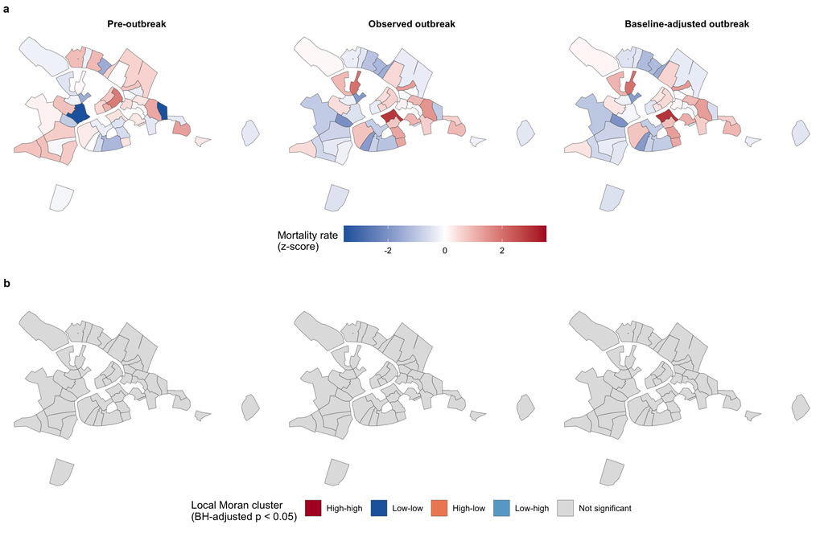

```r
spatial_rate_map_data <- do.call(rbind, lapply(
  names(spatial_rate_vectors),
  function(period_name) {
    period_shape <- spatial_shape
    period_shape$Period <- period_name
    period_shape$Standardized_rate <- as.numeric(scale(
      spatial_rate_vectors[[period_name]]
    ))
    period_shape
  }
))
spatial_rate_map_data$Period <- factor(
  spatial_rate_map_data$Period,
  levels = names(spatial_rate_vectors)
)

spatial_lisa_map_data <- merge(
  spatial_shape[, "Parish"],
  spatial_local_results[, c("Parish", "Period", "Cluster")],
  by = "Parish",
  sort = FALSE
)
spatial_lisa_map_data$Period <- factor(
  spatial_lisa_map_data$Period,
  levels = names(spatial_rate_vectors)
)

shared_rate_limit <- max(abs(spatial_rate_map_data$Standardized_rate))

spatial_rate_map <- ggplot(spatial_rate_map_data) +
  geom_sf(
    aes(fill = Standardized_rate),
    color = "grey35",
    linewidth = 0.15
  ) +
  facet_wrap(~Period, nrow = 1) +
  scale_fill_gradient2(
    low = "#2166AC",
    mid = "white",
    high = "#B2182B",
    midpoint = 0,
    limits = c(-shared_rate_limit, shared_rate_limit),
    name = "Mortality rate\n(z-score)"
  ) +
  coord_sf(datum = NA) +
  theme_void() +
  theme(
    strip.text = element_text(face = "bold", size = 10),
    legend.position = "bottom",
    legend.key.width = grid::unit(1.5, "cm"),
    plot.margin = margin(2, 2, 2, 2)
  )

lisa_palette <- c(
  "High-high" = "#B2182B",
  "Low-low" = "#2166AC",
  "High-low" = "#EF8A62",
  "Low-high" = "#67A9CF",
  "Not significant" = "grey88"
)

spatial_lisa_map <- ggplot(spatial_lisa_map_data) +
  geom_sf(
    aes(fill = Cluster),
    color = "grey35",
    linewidth = 0.15
  ) +
  facet_wrap(~Period, nrow = 1) +
  scale_fill_manual(
    values = lisa_palette,
    drop = FALSE,
    name = "Local Moran cluster\n(BH-adjusted p < 0.05)"
  ) +
  coord_sf(datum = NA) +
  theme_void() +
  theme(
    strip.text = element_blank(),
    legend.position = "bottom",
    plot.margin = margin(2, 2, 2, 2)
  )

spatial_clustering_figure <- plot_grid(
  spatial_rate_map,
  spatial_lisa_map,
  ncol = 1,
  labels = c("a", "b"),
  label_size = 12,
  rel_heights = c(1, 1)
)

print(spatial_clustering_figure)
```

```r
ggsave(
  filename = file.path(
    "Figures_Final_v2",
    "SuppFig8.pdf"
  ),
  plot = spatial_clustering_figure,
  width = 12,
  height = 8,
  units = "in",
  dpi = 300,
  bg = "white"
)

ggsave(
  filename = file.path(
    "Figures_Final_v2",
    "SuppFig8.png"
  ),
  plot = spatial_clustering_figure,
  width = 12,
  height = 8,
  units = "in",
  dpi = 300,
  bg = "white"
)
```

## Parish Population Estimation Method

Main analysis uses per-parish linear interpolation. Two more methods:

1. citywide regression
2. estimate populations using 1624 sestiere population data and 1586 parish shares of sestiere population.

```r
populations_from_sest <- read.csv("parish_population_estimates_sestiere_proportion.csv") #1624 sestiere populations directly from a census multiplied by parish proportions in that sestiere from 1586 data

colnames(populations_from_sest) <- c("Sestiere", "Parish", "Population_1586",
                              "Population_1696", "Population_1629_Regression", "Population_1629_Sestiere_Proportion", "Percent_Diff")

# Remove space artifacts
populations_from_sest$Parish <- gsub("[[:space:]]", ".", populations_from_sest$Parish)
populations_from_sest$Parish <- sub("^S\\.", "S", populations_from_sest$Parish)

# Remove diacritics
populations_from_sest$Parish <- stri_trans_general(populations_from_sest$Parish, id = "Latin-ASCII")

remove_vec <- c()
for(i in 1:length(populations_from_sest$Parish)){
  if(!(populations_from_sest$Parish[i] %in% population_post$Parish)){
    remove_vec <- c(remove_vec,i)
  }
}

if(length(remove_vec) > 0){
  populations_from_sest <- populations_from_sest[-remove_vec,]
}

populations_from_sest <- populations_from_sest %>% arrange(Parish)

population <- data.frame(population_post$Parish, as.numeric(populations_from_sest$Population_1629_Sestiere_Proportion) / 1000)
colnames(population) <- c("Parish","Population")
population_specified <- population[population$Parish %in% colnames(filled[,-1]),]
population_specified <- population_specified[match(colnames(filled[,-1]), population_specified$Parish),]
```